# Physics in the PAU, 2026: what the data now say

Single-page edition of the report (all chapters) — Euskadi (UPV/EHU) 2010–2026 in its Spanish context

Published

September 19, 2026

# Overview

## 0.1 Headline numbers

3.99 Física mean, Euskadi, June 2026 (2025: 5.47)

39.8 % pass rate, Euskadi 2026 (2025: 62.3 %)

24.5 % of Basque Physics exams at ≤ 2 points (2025: 10 %)

9 / 17 communities with a published 2026 Física mean (3 down, 6 up)

4.08 · 4.41 Tenerife (ULL) and Las Palmas (ULPGC), June 2026 — the Canarias twin

+0.80 Cataluña Física 2025→2026 (6.04 → 6.84, 8 021 students)

## 0.2 What this study adds

The July 2026 package in this project (`fisica_pau_ehu_package`, `hist_evolution`) already held the Euskadi Physics series 2010–2025 and the Ministry EPAU cubes 2015–2025. The question the user asked on 18 September was different: *since then, what else has been published, anywhere in Spain, and what does the whole body of evidence say?* This site answers in three layers.

**Data hunt** (Chapter 1). Five parallel searches (Euskadi/EHU; Ministry and north-east; south; north-west, Madrid and Valencia; literature and national press) plus a second pass with a real browser on the official dashboards that block automated readers. Nine communities now have a 2026 Física mean; two of those (Castilla-La Mancha and Canarias, through Tenerife and Las Palmas), together with La Rioja’s 2010–2022 series, were retrieved from dashboards or chart-only PDFs that no search engine indexes. The Basque Government’s school-results report gives, for the first time in this project, the *school* Physics marks of the cohort that sits the PAU.

**Independent analysis** (Chapters 2–6). Everything is recomputed from the raw files with the scripts in `scripts/`. The Ministry cubes are parsed with a small dependency-free PC-Axis reader and the result is checked cell-by-cell against the July package (exact agreement, Chapter 10). Where a number is modelled rather than observed (the implied 2026 grade distribution) it is labelled as such.

**Log and sources** (Chapters 8–9). Every figure on this site can be traced to a URL, a page number or a dashboard filter, and every dead end is recorded so that the next update does not repeat it.

**1. The 2025 fall was national; the 2026 fall is regional.** Across the 17 communities the ordinary-sitting Physics mean changed by $-0.81$ points on average between 2024 and 2025 (14 of 17 fell), the first year of the LOMLOE competency exam. Euskadi’s $-0.62$ that year was *milder* than the national move. In 2026 most communities that have reported bounced back ($+0.5$ to $+1.13$ for Asturias, Madrid, Castilla-La Mancha, Cataluña and C. Valenciana; $+0.17$ for Andalucía), while Euskadi ($-1.48$), Canarias ($-0.83$) and Extremadura ($-0.82$) fell further. Measured against the pre-COVID norm rather than the previous year, 2025 was a return to the 2015–2019 level in every subject, so the reform’s first year coincides with the end of a five-year plateau and cannot be separated from it; neither explains 2026. (Chapter 3)

**2. A one-year change of $-1.48$ is rare but not unprecedented; the *level* is what is exceptional.** In the Ministry panel of 170 year-to-year changes (17 communities × 10 transitions, 2015–2025) the standard deviation is 0.74 and only 7 changes were as negative — Extremadura 2024 ($-2.10$), Cantabria 2017 ($-1.94$), Canarias 2019 ($-1.76$), Baleares 2025, Euskadi itself in 2022 ($-1.62$, the post-COVID normalisation), Asturias 2025, Cantabria 2025. But a mean of 3.99 is lower than any ordinary-sitting regional mean in the eleven years of Ministry data except Canarias 2019 (3.60), and it is Euskadi’s second consecutive fall: $6.09 \to 5.47 \to 3.99$. (Chapter 2)

**3. Canarias 2026 is the Basque case’s twin.** Tenerife (ULL): 683 exams, mean 4.08, 38.5 % pass, 30 zeros, 25 % of exams below 2. Las Palmas (ULPGC): 712 presented, mean 4.41, 42.8 % pass, 22.6 % below 2. These histograms, read directly from the universities’ dashboards, show the same shape the Basque summary statistics imply: a flat-to-decreasing density with a heavy tail at 0–2 and a collapsed top decile. They are the best available empirical picture of what “3.99 / 39.8 % / 24.5 % ≤ 2” looks like exam by exam. (Chapter 4)

**4. In Euskadi the damage is concentrated in the science-technical block; elsewhere the pattern differs by subject.** Euskadi 2025→2026: Física $-1.48$, Matemáticas II $-1.67$, Historia $-0.83$, Euskara $-0.48$, Química $-0.21$, Biología $+0.15$. Cataluña: Física $+0.80$ but Matemàtiques $-1.94$. Madrid: Física $+1.1$ on the chart labels ($+1.05$ against the Ministry 2025 baseline), Matemáticas II $+0.5$. Andalucía: Física $+0.17$, Matemáticas II $-0.59$. The subject-by-region pattern is not the signature of a single national exam-model effect; it is the signature of regional paper design and marking, subject by subject. (Chapter 5)

**5. The same students carry a school Physics mark of 7.09.** The Basque Inspectorate’s *Resultados escolares 2024-25* gives 2º Bachillerato Física: 4 541 students, 98.1 % pass, mean 7.09 (public 7.04, private/concertada 7.15; models A/B/D 6.93/7.31/7.09). Roughly 45–48 % of them sit PAU Física. The school-to-exam gap was 1.6 points in 2025 and, if school marks did not move, 3.1 points in 2026. (Chapter 5)

**7. Against its own sixteen-year history, the Basque paper changed twice, and the second change is the one the grades react to.** The 34 EHU papers since 2010 show a very stable exam, in two successive formats — until 2019 two options with two problems and two theory “questions” that reproduced, verbatim, titles from an official EHU–Department list of 22 (40 % of the marks; the list, with its marking guide, was in teachers’ hands), problems drawn from about a dozen templates (of the modern-physics problems set in 2010–2024, 14 of 15 were the photoelectric effect; mirrors, standing waves, sound levels and radioactive decay were never set), qualitative marking rules, and — from 2020 to 2024 — the most generous choice rule the exam ever had (+1.2 points of expected score through choice alone, by simulation). The 2025 paper removed the theory, restructured the paper and introduced numerical penalties, and the Basque mean fell *less* than the national average. The 2026 paper doubled the obligatory competencial share, halved choice (worth about −0.26 by simulation), printed a −0.1 penalty list with symbolic-first and 0.25-point sub-tasks, and opened the de facto syllabus (modern physics to any topic; in June, standing waves with sound levels and carbon-14 dating, both examined for the first time; in July, a mass spectrometer, also a first, and obligatory). No rule is unique to Euskadi — Canarias applies the same penalty list and also fell; Valencia requires symbolic-first and rose — but no community that rose moved on all axes at once. (Chapter 12)

**8. The fall has an internal structure, and four fifths of the Basque part of it cannot yet be attributed to anything.** Measured against the nine communities that have published a 2026 result, Euskadi’s own component of the 2026 fall is $-1.65$ — and in 2025 it was $+0.03$, so the whole of that year’s fall was the country’s. Of the $-1.65$, the choice removed from the paper beyond what other communities removed accounts for about $-0.20$ and the Basque cohort’s decline in excess of Spain’s for about $-0.12$; the remaining $-1.33$ cannot be separated into paper content, reading load, marking severity and newly examined topics, because those leave the same trace in a mean. And a year earlier, in 2024, the Basque distribution changed *shape* without changing level: the top band fell six points further than the level implied while the pass rate rose, the second-most-negative one-year move of the 170 in the national panel, on the last paper of the old format. (Interpretation)

**9. More than half of the Basque-specific fall is not Física’s.** Euskadi published eight subjects and four comparator communities published three of the same ones, which gives a balanced five-by-three panel. On it the $-1.48$ splits exactly, with no fitting, into a field core of $+0.06$, a field Física premium of $+0.74$ (Física ran above its own community’s mean in all four comparators, by $+0.38$ to $+1.29$), a Euskadi-common term of $\mathbf{-1.18}$ and a Física-specific term of $\mathbf{-1.10}$. The two Euskadi terms put Euskadi’s Física 2.28 marks below what these four comparators’ Física did, and slightly more than half of that gap is not Física’s. In the same sitting, at the same university and under the same marking specification, Matemáticas II lost 1.67 marks — more than Física — while Química ($-0.21$), Biología ($+0.15$) and Lengua Castellana ($+0.03$) did not follow. Rewriting the Física paper addresses half the problem; the other half is invisible from inside any one subject’s *ponencia*. The same table bounds the marking-severity hypothesis: a *general* severity effect would move all eight subjects and, if the verbal papers were no easier in 2026, accounts for at most a fifth of Física’s fall, while a severity confined to the seven numerical deductions fits the pattern and is settled by one tally of the marking sheets. (Interpretation)

**10. There is no rate of cohort decay to project, and the paper swamps the cohort five to one.** Between consecutive PISA rounds the Basque change per cohort-year runs $+0.01$, $+3.65$, $-7.53$, $+1.44$, $-1.97$, $-6.99$ points: steps, not a slope, so a linear extrapolation would be an honest interval around the wrong model. A within-cohort degradation between fifteen and eighteen cannot be identified from PISA and the PAU together at any sample size, because it enters every difference alongside the paper term; a *constant* one cancels and is therefore irrelevant to the year-to-year question, and a *changing* one would show as the PAU falling faster than PISA, which it does not. The 2026 entry count runs the wrong way for dilution: 5.6 % fewer candidates sat Física, which under the assumption most favourable to dilution should have *raised* the mean by 0.29. And the cohort term for 2027 is $-0.18$ marks against a paper-to-paper standard deviation of 0.85. (Interpretation)

**11. The reading load lives in the competency items, and the 2027 target is the 2025 paper plus an allowance.** Counted statement by statement rather than paper by paper, the 2025 Basque paper’s six ordinary items run 56 to 147 words and its single obligatory competency exercise runs **403**; in 2026 there are two such exercises, 289 and **406**, and between them they carry 49 % of everything a candidate reads. Statements went from 1 026 to 1 431 words; the non-question furniture barely moved in total, 356 to 398, but changed entirely in composition — the block headings shrank and **103 words of printed sub-task weights appeared where the 2025 paper had none**, which can go without touching a question. A competency item costs about 400 words in its first year and 300 in its second — block A ran 403 in 2025 and 289 in 2026, block B 406 in 2026 — so the 250 the coordination wants for both in 2027 is a continuation of a trajectory the papers already show, and it implies a **two-tier** budget (competency items ≤250, options ≤150, about 1 100 read) rather than one uniform band. The 2026 electromagnetic problem, reconstructed by the coordination along two separate routes, shows where the words are: its scaffolding is symmetric — the same three-step chain asked of two configurations — and one of its three “competency elements” is a marking rule that applies whether printed or not. (Interpretation)

**12. The change from non-award to deduction is sufficient, on its own, to produce the four published 2026 figures.** What changed in the marking was not that correctors became harsher on the same scale: until 2025 a missing unit cost the part of the sub-task that depended on it, and from 2026 it costs that part *and* $-0.10$ with no cap, while a grave error voids the whole apartado. That the rules were applied in full in 2026 and not in 2025 is the coordinator’s account and is labelled as testimony throughout; the amounts themselves are in the published criteria. Put the **published** 2025 distribution through that regime — about twelve deductions per script, a grave error carrying part of the paper in one script in six, and essentially all of it in three to four per cent — and the four published 2026 figures come out together: mean 4.11 against 3.99, pass 39.0 % against 39.8, 25.2 % at or below two against 24.5, and 3.5 % at zero against 3.2. Two caveats. Those four figures were **fitted**, so this is sufficiency and not prediction. And the deduction count of twelve is robust to everything internal to the model but not to the assumption that every candidate collects the same twelve — which is finding 13. (Interpretation)

**13. Once the penalties are allowed to fall unevenly, the marking regime accounts for less of the fall — and the flat model is a ceiling, not an estimate.** A deduction of $-0.10$ removes a full $0.10$ only where there is $0.10$ left on the sub-task; on weak work the zero floor absorbs the rest. So the marks removed per deduction fall as the penalties move down the distribution, with a correlation of $-0.99$ across seven ways of spreading the same average of twelve. Every reading in which weaker candidates collect more than their proportionate share — the realistic reading — costs less per deduction than spreading them evenly, between 93 % and 68 % of the flat figure, and unequal rates at the same average cost less again. **Flat and equal is therefore the most expensive way to spend a fixed number of penalties, which makes it a maximum.** Read as a budget against the $-1.10$ the subject split assigns to Física specifically — the marking change is a Física change, so the $-1.18$ that fell on every Basque subject at once is not its to explain — twelve deductions carry 87 % of that $-1.10$ if spread flat and 81 % to 59 % if distributed. **Between a fifth and nearly half a mark of the Física-specific fall is left for the paper, the reading load, the optionality and the cohort**, and the dossier leaves it open rather than claiming it. The published figures also bound the tilt from the other side: a heavy concentration at the bottom would need sixteen to twenty-five deductions to reach the observed mean and would put 27–30 % of scripts at or below two against the 24.5 % observed. A mild tilt is what survives. **This finding also corrects an error in the previous edition**, which compared the model with “2.1 % of scripts at nine or above” as though that were published; it is the dossier’s own Beta extrapolation from the same four figures. Correcting it turns a supposed failure into the sharpest request on the list: refitted, the readings agree on all four published figures and differ on the share at or above nine by a factor of twenty-three, from 0.3 % to 6.1 %, so the 2026 band table — routine until last year — decides the question by itself. (Interpretation)

**14. The reading load is the price of the itemised marking, not of the competency reform — and the competency narrative has not grown at all.** The 2026 criteria break each apartado into sub-items of 0.25, forty quanta over the ten marks, a decision the coordination took to protect candidates: failing a sub-question costs a quarter of a point instead of an apartado, and more of what a candidate knows gets its own chance to be credited. A paper marked that way has to **print** each quantum — its demand and its price. Splitting both papers’ statements into narrative, demand text and printed prices shows what that cost. Per printed statement the contextual narrative is **the same size it was**, 71 words in 2025 against 70 in 2026; the demand text **more than doubled**, 88 words against 181; and the printed prices went from nothing to 17. The 2025 paper stated twenty plain numbered demands with no nesting; the 2026 paper states seventeen apartado lead-ins with thirty-six numbered sub-demands inside them and fifty-one printed weights. The coordination’s own reconstruction of the electromagnetic problem prices the same step at 66 words. **This dossier has attributed the reading load to the competency items since its first day, and that attribution was wrong** — the measurement was available throughout. It matters because the two causes are differently actionable: the competency requirement is imposed and cannot be declined, while the itemisation is a local decision that can be revisited — at the cost of giving back exactly the protection it was introduced to provide. (The paradigm change, the measurement)

**15. Only half the paper can attract a deduction, and the third channel is capped — so the marking regime is bounded more tightly than the dossier had it, not less.** Coded from the corrector’s own document, a candidate’s paper has 27 to 32 sub-items of which **14 to 19 can attract a missing unit, a wrong prefix or a rounding error**; the rest ask for a definition, a judgement, a comparison with its justification or a sketch, where those errors cannot be made. Restated in the currency a marking sheet can be counted in, the fitted twelve deductions are **0.67 penalties on every numerical answer of every script**, and carrying the whole observed fall alone would take 1.26 — more than one penalty on every numerical answer there is. Concentrating the penalties on the exposed half also wastes more of them, so exposure **lowers** the ceiling of finding 13. Separately, the dossier said three times that it *understated* the regime by leaving the linguistic channel unmodelled. That was wrong: the Basque criteria cap spelling and syntax together at 1.00, ten per cent of the paper, and the rule was in the repository’s own marking-rules table the whole time. Modelled, the channel’s absolute bound is 0.96 marks even if every script in Euskadi lost the maximum, and fitted jointly with the other two the four published figures want **one error per script, worth 0.04**. And a last piece of arithmetic points the same way: a regime fitted to all four published figures carries the whole $-1.48$, but the subject split allows Física at most $-1.10$, so such a fit is **over-attributed by 0.38 marks by construction** — an independent reason, on top of finding 13’s, to read it as a ceiling. (Interpretation)

**16. The exam had been the curriculum for fifteen years, the schools were warned in 2024, and two transitional courses were not enough.** Forty per cent of the marks came from a closed list of theory titles, of which only **22 distinct titles** were ever set across 120 slots — a mean recurrence of 5.5, the commonest twelve times — while **optionality stood at 100 %**: every item could be declined. Fourteen of the fifteen modern-physics problems of that period were photoelectric; fission and fusion existed only as theory titles, examinable as prose and never as a calculation, until carbon-14 dating and plutonium-239 decay appeared as problems in 2026. A teacher optimising for results under that instrument would teach the twenty-two titles, drill the recurring templates and let the rest go — the correct response to the incentive, not a failure of one. **The schools were told in time**: the reopening of the syllabus was announced in 2024 and the coordination designated 2024-25 and 2025-26 transitional. So the hypothesis is about **practice, not information**. An announcement does not create example banks, mock papers or an examiner’s fluency, and those take longer than two courses. Cataluña, which had no such equilibrium, had nothing to unlearn. (Sixteen years of one paper)

**17. In June 2026 the old route was still open — every novelty sat where a choice was offered.** The syllabus was reopened, but that is a statement about what *could* be set, not about what a candidate had to answer. Mapped slot by slot against sixteen years of precedent, both 2026 slots that carried **no optionality** were on sub-topics ranked first (set 18 times) and eleventh (set 5 times) in the archive; every genuinely novel item — carbon-14 dating, plutonium-239 decay — sat in a slot with a choice, opposite a familiar alternative. A candidate prepared exactly as the previous fifteen years rewarded could therefore have avoided all of it. **Content novelty is very nearly excluded for the ordinary sitting**, which relocates the inertia hypothesis: what it now claims is not that students met unfamiliar physics, but that preparation was diluted across a wider syllabus and that familiar physics arrived in an unfamiliar form. (Sixteen years of one paper, Interpretation)

**18. Six communities converted nothing and still spread two marks, which caps what the conversion can be asked to carry.** Drawn as a route rather than a scatter — each community an arrow from the competency-coded share of its 2025 paper to that of its 2026 paper against the change in its mean — Euskadi is the only arrow running far right and steeply down, 25 to 62.5 per cent; Cataluña runs *left* and slightly up, 75 to 37.5, from a position its own archive shows it had held since at least 2020, so a retreat from a mature practice rather than the reversal of a conversion. **Six of the nine have no horizontal component at all**: no competency-coded marks in either year. Their outcomes nevertheless span $-0.83$ to $+1.13$, a range of **1.96 marks**. Whatever moved them was not conversion, because they did none, and any account resting on conversion alone has to explain why the same year moved papers that never converted by as much as it moved the one that did. (The papers themselves)

**19. The examination week is a designed object, and in 2026 it was redesigned — the timetable moved and the weighting table makes Física the third of three keys.** Two mechanisms are usually attributed to Física being sat last, and they behave differently. The within-sequence ordering is **contradicted**: the largest fall is Matemáticas II, sat before Física, and Biología, sat between them in 2025, *rose*. Física’s own slot did not move either, so being last cannot explain a change. What did move is Matemáticas II, out of the Wednesday morning slot into the slot **immediately before Física**, forty-five minutes ahead of it — so that for the first time the two heaviest quantitative papers were sat back to back. The four subject changes partition exactly along that pairing ($-1.67$ and $-1.48$ adjacent; $-0.21$ and $+0.15$ moved to the other day), and the contrast is confounded beyond separation, because “adjacent” and “hardest” name the same two papers. It is recorded as a fact about the 2027 calendar decision and enters no budget. The second mechanism is allocative and is the only hypothesis in the dossier that predicts a change of **shape** rather than of level. The UPV/EHU table states the rule at the head of every page — *“Se utilizarán las 2 calificaciones que sean más favorables”* — so the return on Física is a step function, not a slope. Física weights 0.2 in 28 of 37 relevant degrees, which reads as demand and is the reverse: **26 of those 28 also weight Matemáticas II at 0.2 and 19 weight Física, Matemáticas II and Química all three at 0.2**, while Matemáticas II is compulsory in the access phase and carries forward, so one slot is filled before any elective is chosen and the second is contested between Química — sat the day before — and Física. In the health-sciences degrees Biología and Química weight 0.2 and Física only 0.1, so a medicine-bound candidate cannot bring Física into the best two at all. That selects the *strong* candidate as the one who can afford to stop, and predicts losses at the top with the pass rate held — which is the 2024 signature term for term (top band $-9.0$ pp against $-3.1$ expected, pass $+2.3$ against $-2.8$, mean $-0.21$), the one event in this study that has never carried a mechanism. It is a candidate and not a finding: an allocation rule is a constant unless the incentive changed, and what moved in 2024 is public and unchecked. (Interpretation)

**20. Cataluña converted in 2020, not 2025 — and the conversion cost it nothing a well-specified test could see.** Fifteen more Catalan papers (2005–2019) were added from an open archive, and one mechanical rule — what share of items require the candidate to justify, reason, explain, evaluate or say why — was applied to every year from 2010. The traditional decade sits at **17.7 %** (sd 10.9, range 6.2–33.3); 2020–2023 sits at **50.0 %**. The level roughly triples and the step is at **2020**, five years before the decree and five before the structural change that made the 2025 paper look converted. Differenced against the fifteen communities with a complete Ministry series, and dropping the COVID sittings because they confound treatment with control, Cataluña’s position moves from $+0.42$ (2015–19) to $-0.43$ (2022–25), a shift of $-0.85$ — with Welch $p=0.087$, exact permutation $p=0.119$, and a **minimum detectable shift of 1.26 marks**. The estimate is smaller than the resolution of the design that produced it, 59 % of it is the field rising rather than Cataluña falling, and Cataluña’s position moved $+1.28$ in 2017 with nothing happening to its paper at all. **This is a bound, not a coefficient, and no sentence in this dossier quotes it as one.** What it licenses is two things. A system that tripled its examined-reasoning share at one step produced nothing detectable over six years, while Euskadi’s second-year fall alone is $-1.65$ — larger than the entire Catalan post-conversion displacement. And the floor matters more than the step: **Cataluña’s lowest traditional year is 6.2 %, so it never examined without asking anyone to justify anything**, while the Basque instrument drew 40 % of its marks from a closed list of recall titles and carried zero competency marks as late as 2024. Cataluña intensified a practice it had; Euskadi introduced one it did not. It changed once and then left the paper alone for five years; Euskadi changed four axes in two sittings. (The papers themselves)

**21. A deviation of this kind usually gives most of itself back the next year — so a 2027 recovery of a mark and a half would be what doing nothing predicts.** A question about whether the Catalan curve is cyclic forced the first measurement of the panel’s *memory*, and the memory turns out to matter more than the cycle. The wave is not one: a difference against the field cannot contain a driver common to Spain, because the subtraction removes it; eleven annual points contain one cycle of a nine-year period and cannot distinguish it from a trend; and when the same cosine is fitted to all fifteen communities, **Aragón fits better than Cataluña** and the recovered periods run from 2.5 to 40 years, where a common driver would impose a common period and phase. What the appearance really is falls out of one number. Within a community, around its own level, the deviation from the field follows an AR(1) with $\phi = 0.186$ — which predicts that year-to-year *changes* anticorrelate at $-0.407$, against $-0.389$ observed ($p = 3\times10^{-6}$, $n=135$). Mean reversion alone reproduces the wave; no forcing is needed. The consequence is a prediction. Euskadi’s norm against the eight 2026 publishers is $+0.06$; its 2026 position is $-2.10$, a deviation of $\mathbf{-2.16}$ from its own norm. If that is a **transient shock**, 2027 should return $-0.40$ (95 % $[-1.32, +0.52]$); if it is a **permanent level change**, $-2.16$ (95 % $[-3.08, -1.24]$). The two differ by 1.76 marks against an innovation sd of 0.47 — **3.7 $\sigma$, settled by a single sitting.** So: if the paper is changed for 2027 and the mean recovers by about a mark and a half, that is what the panel predicts from doing nothing, and it is not evidence that the change worked. (Interpretation)

## 0.4 What is still missing

No 2026 Física figure has been published for Aragón, Baleares, Cantabria, Castilla y León, Galicia, Murcia, Navarra or La Rioja; the Ministry’s 2026 cube is due in June 2027. EHU has not published the Física result of the July 2026 sitting, the pass *count*, the revision statistics for Física, the tribunal-level spread it referred to on 6 July, nor any split by sex, language or territory. The Basque *Resultados escolares 2025-26* (the school marks of the cohort that sat PAU 2026) is not yet out. Chapter 9 lists the URLs to poll and the dates by which each is expected.

**How to read the numbers**

All means are on the 0–10 scale and, unless stated, refer to the **ordinary (June) sitting** and to **students who sat the exam**. Cataluña publishes means over students *eligible for university assignment* (“aptes”), Madrid publishes chart labels rounded to one decimal, Extremadura’s 2026 value comes from the university’s press release as quoted by regional media; these are flagged wherever they appear. Nothing on this site is a causal estimate: the data are cohort statistics of different exams marked by different tribunals.

# 1 The data hunt

*What was searched, what exists, what was found, what is still unpublished*

## 1.1 Design of the search

The search was organised as five parallel investigations, each with an explicit brief, followed by a second pass with a real browser session on the user’s computer for the sites that reject automated readers (Power BI dashboards, WAF-protected university sites, rate-limited servers). The five briefs were:

1. **Euskadi / EHU** — anything published after 6 July 2026: extraordinary sitting, revisions, tribunal data, Basque Government, Parliament, unions, press in Spanish and Basque, Open Data Euskadi, Eustat, ISEI-IVEI, the Inspectorate’s school results.
2. **Ministry and north-east** — SIIU/EPAU 2026 status, Cataluña (Govern dossiers and Recull estadístic), Aragón, Navarra, Baleares, La Rioja.
3. **South** — Andalucía (Distrito Único, ponencias UMA/US/UCA), Extremadura, Castilla-La Mancha, Murcia, Canarias (coordination minutes).
4. **North-west, Madrid, Valencia** — Galicia (CiUG), Asturias, Cantabria, Castilla y León (four universities), Madrid (six universities), Comunitat Valenciana (five universities).
5. **Literature and national narrative** — Dialnet, Redalyc, UNED/UM journals, MDPI, Frontiers, arXiv, TESEO; national press and professional bodies (RSEF, CRUE, teacher associations).

Query families were run in Spanish, Basque, Catalan and Galician (`nota media Física PAU 2026`, `Fisika USaP 2026 emaitzak`, `mitjana Física PAU 2026`, `estatísticas PAU 2026 Física`, …) until the search budget of the session (200 web searches) was exhausted. Direct URL probes (HTTP status of the predictable 2026 filenames) were used to distinguish “not found by search” from “not yet published”.

**What made the difference**

The four largest gains came from **reading dashboards and chart-only PDFs in a real browser**, not from search engines: the UCLM Power BI (Física 2021–2026, both sittings, by province), the ULL and ULPGC Power BI (Física histograms 2024–2026 with zeros, tens and means by sex), and the University of La Rioja’s chart-only PDF (Física 2010–2022). None of these numbers exist as text anywhere on the web.

## 1.2 Coverage matrix, 18 September 2026

| Community | 2026 Física (ordinary) | 2025 baseline | Best source found | Status |
| --- | --- | --- | --- | --- |
| País Vasco | **3.99**, 39.8 % pass, N = 2 066 | 5.47, 62.3 % | EHU presentation 6 Jul 2026 (Euskal Herriko Unibertsitatea, 2026b) | official; July sitting, pass count, tribunal spread **not** published |
| Cataluña | **6.84** (aptes basis), N = 8 021 | 6.04 (aptes) / 5.98 (ministry) | Govern dossier 23 Jun 2026, pp. 19–21 (Generalitat de Catalunya, 2026) | official; September sitting aggregate only; Recull 2026 due after 29 Sep |
| Andalucía | **5.86** | 5.69 | Junta table of 33 subject means (Junta de Andalucía, 2026); UMA/US/UCA ponencias give 2025 by university | official; N and pass % unpublished; ponencias for 2026 due Nov 2026 |
| Extremadura | **5.27** (lowest subject) | 6.09 | UEx release via Canal Extremadura (Canal Extremadura, 2026) | press; unex.es statistics pages block readers |
| Asturias | **6.62**, 76.87 % pass | 5.49 | Uniovi press release 12 Jun 2026 (Universidad de Oviedo, 2026) | official; July release omits Física |
| Comunidad de Madrid | **6.7** (chart, 1 dec.) | 5.6 (chart) / 5.65 | CM presentation p. 14, read from the rendered chart (Comunidad de Madrid, 2026) | official; per-university 2026 not published; UAM ponencia charts have no labels |
| Comunitat Valenciana | **6.396**, 76.35 %, N = 5 259, SD 2.38 | 5.889, 69.6 % | GVA statistics PDFs June/July/Global 2026, p. 43 (Generalitat Valenciana, Conselleria d’Educació, Universitats i Ocupació, 2026) | official; re-extracted here; July 2026 = 4.162 |
| Castilla-La Mancha | **6.80**, 80.07 %, N = 1 781 | 5.86, 65.6 % | UCLM Power BI, curso 2025-26 (Universidad de Castilla-La Mancha, 2026) | official; full 2021–2026 series by province and sitting retrieved |
| Canarias | **4.08** (ULL, N = 683) / **4.41** (ULPGC, N = 712) | 4.92 / 5.25 (ministry pooled 5.08) | ULL and ULPGC Power BI (Universidad de La Laguna, Gabinete de Análisis y Planificación, 2026; Universidad de Las Palmas de Gran Canaria, Dirección de Acceso, 2026) | official; histograms, zeros, tens, sex means; July ULL = 3.27 |
| Aragón | — | 6.469, 79.4 % | UNIZAR xlsx 2020–2025 with grade bands (Universidad de Zaragoza, 2026) | gap; `pauresulasig2026.*` → 404 (expected winter 2026-27) |
| Navarra | — | 5.36, 60.9 % | UPNA Informe 2024-25, grade bands (Universidad Pública de Navarra, 2025) | gap; `Informe_PAU_2025-26.pdf` → 404 |
| Región de Murcia | — | 5.33, 61 % | Informe General PAU2025 (2017–2025 pass series) (Universidad de Murcia / Comisión Organizadora de la PAU, 2025) | gap; 2026 report due at first COPAU meeting of 2026-27 |
| Cantabria | — | 5.44, 63.2 % | UC per-subject PDFs 2025 (Universidad de Cantabria, 2025) | gap; four 2026 filename probes → 404 |
| Galicia | — | 5.63 (ministry) | CiUG working-group report 2020–2023 (CiUG, Grupo de Traballo de Física, 2024) | gap; “Grupos de traballo” page reads *Actualizando contido* (18 Sep 2026) |
| Castilla y León | — | 6.19 (ministry) | UVa/USAL/UBU/ULE releases (global only) | gap; no per-subject publication exists in any year; USAL viewer is a dead Infogram embed |
| Illes Balears | — | 4.45 (ministry) | UIB releases (global only) | gap; UIB appears never to publish subject statistics |
| La Rioja | — | 6.39 (ministry) | UR chart-only PDF, Física 2010–2022 (Universidad de La Rioja, 2022) | gap; page still links the 2022 edition |
| **Spain (Ministry)** | — | 5.65 | SIIU EPAU 2025 cubes, published 8 Jun 2026 (Ministerio de Ciencia, Innovación y Universidades (SIIU), 2026) | gap; 2026 edition due ≈ June 2027; no *avance* exists |

## 1.3 Euskadi: everything found after 6 July 2026

**Numerical.** The EHU deck of 6 July (Euskal Herriko Unibertsitatea, 2026b) remains the only source of Física 2026 figures. It also gives the other subjects’ means, pass rates and low-score shares, revision requests for four subjects (not Física), and the global PAU counts: 12 080 presented, 41 tribunals, 848 evaluators, 4 223 revision requests covering 8 127 exams, 313 zeros (2.6 %). The extraordinary sitting was reported on 7 July through the press (1 332 presented, 951 passed, 71.40 %; Araba 77.9 %, Bizkaia 64.3 %, Gipuzkoa 79.8 %; euskera 75.7 %, castellano 61.7 %) with **no subject breakdown** (Donostitik, 2026). The annual *Informe* archive still ends at 2025 (two-page summaries since 2023, with no subject tables).

**A genuinely new dataset.** The Basque Inspectorate’s *Resultados escolares 2024-2025* (Gobierno Vasco, Inspección de Educación, 2025) tabulates 2º Bachillerato Física by territory, network and linguistic model: 4 541 students evaluated, 4 455 passed (98.11 %), mean 7.09. This is the first time the project has the school marks of a PAU cohort (Chapter 5).

**Institutional narrative.** The Education Counsellor’s interview of 12 July (Alonso, 2026) is the key post-6-July document: the Department has “only the report the university made public”, will “ask for more data”, will review “all subjects” for 2027 “in the short term”, and has no diagnosis yet. The Science and Universities Counsellor admitted a “déficit de confianza” in the marking system (7 July). The rector’s press conference, as reported in Basque by Argia (Argia, 2026), acknowledged significant variation between evaluation panels in Física and other subjects. As of 7 September nothing had been sent to schools for PAU 2027 beyond the Euskara II instructions. The 22 June *agerraldia* referenced in the deck’s footer was not located.

**Not found.** No Ararteko file, no union or physics-teacher statement on Física, no Open Data Euskadi or Eustat PAU dataset, no parliamentary initiative text (the Parliament’s search interface could not be driven from this session — a lead, not a negative), no EHU 2027 Física orientations, no per-territory or per-language Física figure for 2026.

## 1.4 The exam papers (added 19 September 2026)

For the content audit of Chapter 11 the ordinary-sitting Física papers of 2025 and 2026 were collected for the nine communities with a 2026 result: EHU (both years, with the corrector documents, from ehu.eus), Cataluña (Generalitat exam archive; the 2026 corrector document from the Betevé mirror, the official file returning 404), Madrid (UCM archive, criteria in the same PDF), Asturias (Uniovi archive with criteria), Andalucía (Junta archive: 2025 models A and B with criteria, 2026 with criteria), Canarias (Gobierno de Canarias archive with criteria), Extremadura 2025 (Educarex teachers’ site, Google Drive), Comunitat Valenciana 2026 (universitats.gva.es, downloaded from the user’s machine), and Castilla-La Mancha (both years read in the built-in browser behind UCLM’s bot check and transcribed to `sources/exams/clm_20xx_ord_transcript.md`). Two papers were not at their official location — Valencia 2025 had been overwritten by the 2026 file, and Extremadura 2026 sits behind UEx’s WAF — and were retrieved from FiQuiPedia’s public GitLab archive of official PAU papers, with the Valencia copy checked byte-for-byte against an independent teacher’s copy. All files are in `sources/exams/` and hashed in the source registry. No Internet Archive copy of a blocked site was used; the two files taken from FiQuiPedia’s public archive of official papers are flagged as such in the registry.

For Chapter 12 the complete EHU archive was downloaded from ehu.eus: the 34 Física papers 2010–2026 (June and July, Spanish and Basque versions where both exist; criteria embedded in the 2012–2024 papers; separate solucionarios for 2025–2026), the PAU 2025 model paper of 18 November 2024 with its general correction criteria, and the earlier October 2024 version of that model. No pre-2025 theory-title document, no “Orientaciones Física 2026” and no coordination-meeting minutes are published on the site; the official list of 22 theory titles was supplied by the coordinator from his own files and is archived as `ehu_theory_list_official.pdf`. Files in `sources/exams_ehu_hist/` (77 PDFs), URLs in its `urls_tried.log`.

## 1.5 Sources that exist but could not be read

- **unex.es** (Extremadura statistics) and **uclm.es** return 403 to automated readers; UCLM was solved with the browser, UEx’s `alumnado.unex.es/pau/` page turned out to contain no statistics section at all.
- **estadisticas.ciencia.gob.es** (Ministry PC-Axis host) serves an incomplete TLS chain; the July copies already in the project (byte-identical to the September re-download made by the earlier session) were used.
- **ciug.gal** also serves an incomplete chain; it was fixed legitimately by adding the missing intermediate certificate, but the statistics section itself is empty.
- **universitats.gva.es** is disallowed by robots.txt for the fetch tool; the three 2026 PDFs were downloaded from the user’s own machine and re-extracted (values identical to the earlier session’s).
- **unirioja.es** rate-limits (HTTP 429); the four PDFs were downloaded from the user’s machine with a browser session.
- **Deia / Noticias de Gipuzkoa / Noticias de Álava** return 406; worked around with a browser user-agent. **El Correo** and **El Diario Vasco** are paywalled and were not retrieved.

## 1.6 Numbers that must not be mixed

- **Cataluña** means are over *students eligible for university assignment*, and the ordinary-only figure (6.04 for 2025) differs from the full-year Recull figure (5.85). The 2026 dossier’s back-series is the ordinary-only one.
- **Valencia** publishes six differently-scoped 2025 reports (Ordinaria/JUNIO/Extraordinaria/JULIO/JULIO finales/GLOBALES) whose Física means differ at the second decimal; the JUNIO files are used here for both years.
- **Aragón**’s `DESV` column is a *mean absolute deviation*, not a standard deviation.
- **Andalucía** 2025: the ponencias’ 5.69 (unweighted mean of ten university means) coincides with the ministry’s 5.69; a secondary blog’s 5.67 is unverified.
- **EHU** press: 3.98 (Orain/EITB copy) versus 3.99 (deck and Campusa); some outlets copied Matemáticas II’s $-1.67$ onto Física. Use 3.99 and $-1.48$.
- **Valencia July 2026** Física pass rate 39.41 % (resit population) is *not* comparable with Euskadi’s 39.8 % (ordinary sitting) despite the coincidence.

# 2 Euskadi 2010–2026: the series and the break

*Level, pass rate and regimes of the Physics exam at UPV/EHU*

## 2.1 The consolidated series

The Euskadi Physics series is spliced from three sources: the EHU annual reports for 2010–2022 (all Physics takers, both phases) (Universidad del País Vasco / Euskal Herriko Unibertsitatea, 2025), the Ministry EPAU cube for 2023–2025 (specific/admission phase, which is where Física sits since 2017 — the two agree to ±0.02 on the overlap 2017–2022) (Ministerio de Ciencia, Innovación y Universidades (SIIU), 2026), and the EHU presentation of 6 July 2026 for the last point (Euskal Herriko Unibertsitatea, 2026b). The splice is validated in Chapter 10.

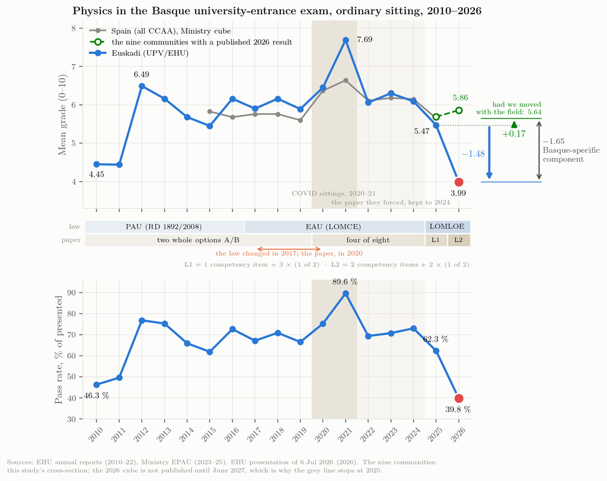

Figure 1: Física in the Basque university-entrance exam, ordinary sitting, 2010–2026. **The ribbon carries two separate facts on the same axis**: the *law* under which the exam was set, and the *paper model* actually used. They do not coincide — LOMCE governed from 2017 but the paper did not change until 2020, and it changed then for COVID and not for the law — which is why they are two rows and not one band; the marked interval under them spans those two years. `L1` and `L2` are the two LOMLOE papers, keyed beneath. **COVID is two sittings and one model**: the darker tint is 2020 and 2021, both set under the relief measures — 2021 is the highest mean in the series, 7.69 — and the lighter one the four-of-eight paper they forced, which was then kept through 2024. **The grey line is the Ministry cube** for all seventeen communities and stops at 2025, because the 2026 cube is not published until June 2027. **The green marks** are this study’s own cross-section of the nine communities that have published a 2026 result — a different population, and drawn detached for that reason. **The two arrows on the right are changes, not levels**, and both leave the same point, Euskadi’s own 2025 mean of 5.47. The **blue** arrow is Euskadi’s own change to 3.99, $-1.48$. The **green** arrow is the change of the nine-community field, $+0.17$, drawn from that same origin so that its head at 5.64 reads as *where Física would have ended had it moved with the field*. The bracket between the two heads is therefore the Basque-specific component, $-1.65$, exactly. The distance between the two 2026 **levels** is 1.87 and is *not* that component, because the two series did not start level in 2025 (5.47 against 5.69). The field is the mean of the nine **including** Euskadi, which is the conservative reading; against the eight others alone the component would be $-1.86$. The three values are the `total`, `common` and `basque_specific` terms of `data/analysis/decomposition.json`, computed by `scripts/21_decay_decomposition.py`.

Table 1: Euskadi Física, ordinary sitting, 2010–2026. Pass rate over presented; “Spain mean” is the Ministry national mean (all communities, presented-weighted over phases). File: `data/analysis/euskadi_fisica_series_2010_2026.csv`.

| Year | Enrolled | Presented | Passed | Pass % | Mean | Spain mean | Gap vs Spain | Δ mean | Source |
| --- | --- | --- | --- | --- | --- | --- | --- | --- | --- |
| 2010 | 2 504 | 2 108 | 975 | 46.3 | 4.45 | — | — |  | EHU informe (all phases) |
| 2011 | 2 620 | 2 610 | 1 294 | 49.6 | 4.44 | — | — | -0.01 | EHU informe (all phases) |
| 2012 | 2 362 | 2 056 | 1 579 | 76.8 | 6.49 | — | — | +2.05 | EHU informe (all phases) |
| 2013 | 2 457 | 2 203 | 1 658 | 75.3 | 6.16 | — | — | -0.33 | EHU informe (all phases) |
| 2014 | 2 495 | 2 253 | 1 485 | 65.9 | 5.68 | — | — | -0.48 | EHU informe (all phases) |
| 2015 | 2 459 | 2 179 | 1 348 | 61.9 | 5.45 | 5.83 | -0.38 | -0.23 | EHU informe (all phases) |
| 2016 | 2 342 | 2 082 | 1 511 | 72.6 | 6.16 | 5.68 | 0.48 | +0.71 | EHU informe (all phases) |
| 2017 | 2 445 | 1 784 | 1 197 | 67.1 | 5.90 | 5.76 | 0.14 | -0.26 | EHU informe (all phases) |
| 2018 | 2 575 | 1 734 | 1 229 | 70.9 | 6.16 | 5.76 | 0.40 | +0.26 | EHU informe (all phases) |
| 2019 | 2 532 | 1 654 | 1 100 | 66.5 | 5.89 | 5.60 | 0.29 | -0.27 | EHU informe (all phases) |
| 2020 | 2 548 | 1 631 | 1 227 | 75.2 | 6.45 | 6.37 | 0.08 | +0.56 | EHU informe (all phases) |
| 2021 | 2 355 | 1 765 | 1 581 | 89.6 | 7.69 | 6.64 | 1.05 | +1.24 | EHU informe (all phases) |
| 2022 | 2 320 | 1 742 | 1 208 | 69.3 | 6.06 | 6.11 | -0.05 | -1.63 | EHU informe (all phases) |
| 2023 | 2 429 | 1 830 | 1 294 | 70.7 | 6.30 | 6.18 | 0.12 | +0.24 | Ministry EPAU (specific phase) |
| 2024 | 2 341 | 1 788 | 1 305 | 73.0 | 6.09 | 6.15 | -0.06 | -0.21 | Ministry EPAU (specific phase) |
| 2025 | 2 597 | 2 189 | 1 364 | 62.3 | 5.47 | 5.65 | -0.18 | -0.62 | Ministry EPAU (specific phase) |
| 2026 | — | 2 066 | — | 39.8 | 3.99 | — | — | -1.48 | EHU presentation 6 Jul 2026 (pass count not published) |

Two features of the table matter for everything that follows. First, the **2011 presented count (2 610) is an artefact** of the 2011 report, which prints an implausible ten no-shows; the pass rate for that year should be read as roughly 55 % rather than 49.6 %. Second, from 2017 the presented/enrolled ratio drops sharply (from ≈ 89 % to ≈ 70 %) because Física became an optional admission-phase subject that many students enrol in and then skip; **2025 reversed this** (2 189 of 2 597, 84 %), so the 2025 and 2026 means are computed over a *larger and less self-selected* pool than 2017–2024. Part of the 2025 drop is therefore compositional; the 2026 drop, on a slightly smaller pool (2 066), is not.

## 2.2 Regimes rather than a trend

The series is not stationary; it is a sequence of plateaus separated by policy changes — the two-phase PAU of RD 1892/2008 (2010), the EAU under LOMCE (2017), the COVID flexibility (2020–21), and the LOMLOE competency model of RD 534/2024 (2025) (Gobierno de España, 2024). Averaging within each regime:

Table 2: Regime means, Euskadi Física, ordinary sitting.

| Regime | Years | Mean | Pass % |
| --- | --- | --- | --- |
| 2010-11 PAU (RD 1892/2008) first years | 2010-2011 | 4.45 | 47.9 |
| 2012-16 PAU settled | 2012-2016 | 5.99 | 70.5 |
| 2017-19 EAU/LOMCE | 2017-2019 | 5.98 | 68.2 |
| 2020-21 COVID flexibility | 2020-2021 | 7.07 | 82.4 |
| 2022-24 post-COVID | 2022-2024 | 6.15 | 71.0 |
| 2025-26 LOMLOE competency model | 2025-2026 | 4.73 | 51.1 |

Between 2012 and 2024, excluding the COVID year 2021, the series is flat: a linear fit $x_t = \alpha + \beta t + \varepsilon_t$ gives $\beta = +0.013$ points per year ($r = 0.17$, $p = 0.60$) with a residual standard deviation $\sigma_\varepsilon = 0.31$. Against that baseline,

$$\hat{x}_{2026} = 6.17, \qquad x_{2026} - \hat{x}_{2026} = -2.18 \approx -7.0\,\sigma_\varepsilon ,$$

and the 2025 residual was already $-0.69 \approx -2.2\,\sigma_\varepsilon$. In plain words: for twelve years (2012–2024, excluding the COVID peak of 2021) the Basque exam produced means between 5.45 and 6.49 in normal years; 2025 (5.47) sat at the bottom of that band, 2.2 residual standard deviations below the trend, and 2026 fell far outside it. The only comparable level in the series is the 2010–11 start of the two-phase PAU (4.45, 4.44), when Física was the lowest-scoring modality subject in the Basque system and roughly half of the candidates passed — and, as Chapter 3 shows with the newly found La Rioja series, that 2010–11 trough was itself a national feature, not a Basque one.

## 2.3 How unusual is a −1.48 change?

A single region’s history is a small sample. The Ministry cube offers a much larger reference set: the year-to-year change of the ordinary-sitting Physics mean for each of the 17 communities over 2015–2025, $n = 170$ changes.

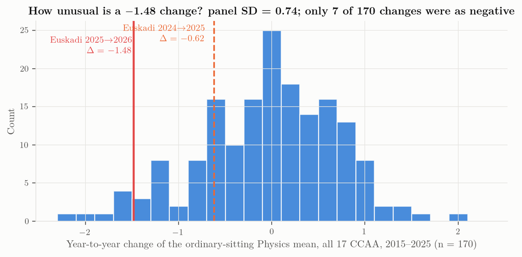

Figure 2: Distribution of year-to-year changes of the ordinary-sitting Physics mean across all 17 communities, 2015–2025, with the two Basque changes marked.

The panel of changes has mean $\bar\Delta = -0.03$ and standard deviation $s_\Delta = 0.74$ (excluding the COVID transitions 2020–2022: 0.69). The Basque 2026 change sits at

$$z = \frac{-1.48 - \bar{\Delta}}{s_\Delta} = -1.97,$$

and only 7 of the 170 observed changes were as negative: Extremadura 2024 ($-2.10$), Cantabria 2017 ($-1.94$), Canarias 2019 ($-1.76$), Baleares 2025 ($-1.65$), Euskadi 2022 ($-1.62$, the post-COVID normalisation), Asturias 2025 ($-1.55$), Cantabria 2025 ($-1.51$). Regional Physics means are volatile — the standard deviation of the annual change is 0.74 and the median absolute change 0.5 points — so a fall of this size, while rare (≈ 4 % of transitions), has precedents. The Basque series’ own year-to-year standard deviation before 2026 is 0.85.

What has fewer precedents is the **level**. Among the 187 community-year ordinary means in the cube, only Canarias 2019 (3.60) lies below 3.99; the next lowest are Baleares 2025 (4.45), Andalucía 2018 (4.65) and Galicia 2023 (4.67). Two consecutive falls summing to more than two points have precedents in the panel — Extremadura $8.55 \to 6.45 \to 6.09$ and Baleares $6.49 \to 6.10 \to 4.45$, both over 2023–2025 — but Euskadi’s ($6.09 \to 5.47 \to 3.99$) ends 0.46 below Baleares and 2.10 below Extremadura.

Table 3: Year-to-year changes of the ordinary-sitting Physics mean across the 17 communities, by transition year (Ministry cube). The 2025 row is the first year of the LOMLOE model.

| Transition to | Mean Δ | Median Δ | Min | Max | Communities down |
| --- | --- | --- | --- | --- | --- |
| 2016 | -0.14 | -0.25 | -0.95 | +0.92 | 11/17 |
| 2017 | -0.18 | -0.24 | -1.94 | +1.12 | 10/17 |
| 2018 | +0.06 | +0.11 | -0.85 | +0.97 | 6/17 |
| 2019 | -0.07 | -0.03 | -1.76 | +1.07 | 10/17 |
| 2020 | +0.52 | +0.52 | -0.34 | +2.10 | 4/17 |
| 2021 | +0.62 | +0.77 | -0.24 | +1.34 | 2/17 |
| 2022 | -0.40 | -0.37 | -1.62 | +0.52 | 10/17 |
| 2023 | -0.02 | +0.11 | -1.21 | +1.01 | 6/17 |
| 2024 | +0.10 | +0.21 | -2.10 | +1.05 | 8/17 |
| 2025 | -0.81 | -0.80 | -1.65 | +0.32 | 14/17 |

The last row of Table 3 is the first key result of this study: **2025 was a national fall**. Fourteen of seventeen communities went down, by $-0.81$ on average; Euskadi’s $-0.62$ was milder than the typical move. Whatever the new exam model did to Physics marks, it did it everywhere in 2025.

## 2.4 Euskadi’s position among the communities

Table 4: Rank of Euskadi among the 17 communities by ordinary-sitting Physics mean (1 = highest), Ministry cube.

| 2015 | 2016 | 2017 | 2018 | 2019 | 2020 | 2021 | 2022 | 2023 | 2024 | 2025 |
| --- | --- | --- | --- | --- | --- | --- | --- | --- | --- | --- |
| 15 | 4 | 8 | 4 | 7 | 7 | 4 | 11 | 8 | 13 | 12 |

Euskadi has been a mid-table region in Physics: its median rank over 2015–2025 is 8, with three years in fourth place (2016, 2018, 2021) and lows of 15th in 2015 and 13th in 2024. In 2025 it ranked 12th with 5.47, 0.18 below the national mean. Among the nine communities with 2026 data Euskadi is last; if the 2025 values are kept for the eight that have not published, Euskadi 2026 would still be last, 0.46 below Baleares 2025.

Table 5: Ordinary-sitting Física mean by community, 2015–2025 (Ministry cube, presented-weighted over phases; “Estado” = UNED/foreign centres omitted). Sorted by 2025.

| Community | 2015 | 2016 | 2017 | 2018 | 2019 | 2020 | 2021 | 2022 | 2023 | 2024 | 2025 |
| --- | --- | --- | --- | --- | --- | --- | --- | --- | --- | --- | --- |
| Aragón | 6.65 | 6.40 | 6.16 | 5.92 | 5.85 | 6.61 | 7.38 | 7.53 | 7.80 | 7.78 | 6.47 |
| Rioja (La) | 5.79 | 6.10 | 6.33 | 6.61 | 6.15 | 6.97 | 8.31 | 7.43 | 7.85 | 7.66 | 6.39 |
| Castilla y León | 5.29 | 6.11 | 4.70 | 5.67 | 5.71 | 5.47 | 6.33 | 6.40 | 5.70 | 6.12 | 6.19 |
| Extremadura | 6.74 | 5.78 | 5.44 | 5.88 | 6.39 | 7.02 | 8.03 | 8.44 | 8.55 | 6.45 | 6.09 |
| Cataluña | 5.98 | 5.26 | 6.38 | 7.06 | 6.37 | 6.89 | 6.93 | 5.82 | 5.73 | 5.94 | 5.98 |
| Comunitat Valenciana | 5.67 | 5.98 | 6.30 | 6.31 | 6.03 | 6.23 | 6.39 | 6.91 | 6.30 | 7.06 | 5.89 |
| Castilla-La Mancha | 6.33 | 5.75 | 6.08 | 5.42 | 6.12 | 6.31 | 6.08 | 6.48 | 5.97 | 6.57 | 5.86 |
| Andalucía | 5.64 | 5.38 | 5.50 | 4.65 | 5.72 | 5.73 | 6.41 | 6.04 | 6.29 | 5.72 | 5.69 |
| Madrid (Comunidad de) | 5.85 | 5.87 | 5.83 | 5.62 | 5.24 | 7.34 | 7.10 | 5.93 | 6.82 | 6.27 | 5.65 |
| Galicia | 5.56 | 4.99 | 5.01 | 5.06 | 5.22 | 4.88 | 5.35 | 5.78 | 4.67 | 5.31 | 5.63 |
| Asturias (Principado de) | 6.96 | 6.35 | 6.04 | 5.43 | 5.94 | 6.03 | 7.10 | 6.20 | 6.33 | 7.04 | 5.49 |
| **País Vasco** | 5.44 | 6.14 | 5.89 | 6.16 | 5.87 | 6.44 | 7.68 | 6.06 | 6.30 | 6.09 | 5.47 |
| Cantabria | 7.01 | 7.92 | 5.98 | 6.12 | 5.57 | 7.05 | 7.76 | 6.56 | 7.09 | 6.93 | 5.42 |
| Navarra (Comunidad Foral de) | 5.35 | 5.26 | 4.73 | 5.38 | 5.35 | 6.11 | 6.88 | 6.09 | 6.13 | 6.80 | 5.36 |
| Murcia (Región de) | 5.93 | 5.27 | 5.80 | 5.48 | 5.47 | 5.45 | 6.27 | 5.38 | 5.42 | 6.47 | 5.31 |
| Canarias | 5.70 | 5.62 | 5.25 | 5.36 | 3.60 | 5.25 | 6.27 | 6.25 | 5.04 | 5.88 | 5.08 |
| Balears (Illes) | 5.80 | 5.16 | 4.91 | 5.28 | 5.63 | 5.35 | 5.37 | 5.48 | 6.49 | 6.10 | 4.45 |

## 2.5 What the series does and does not say

The series establishes three facts. The 2026 value is the lowest since the start of the two-phase PAU; it is the second consecutive fall; and the size of the single-year fall is at the edge of, but inside, the range of regional Physics volatility in Spain. It does not, by itself, identify a cause: a change of exam difficulty, of marking severity, of the students’ preparation, or of who sits the exam all produce the same summary statistic. Chapter 3 uses the other communities to narrow the field; Chapter 4 uses the shape of the distribution.

# 3 Spain 2026: nine communities, three directions

*The 2026 Física results located in this study, against the 2025 Ministry baseline*

## 3.1 The 2026 table

Table 6: Ordinary-sitting Física mean, 2025 (Ministry cube, presented-weighted over phases; Cataluña on its own “aptes” basis) and 2026 (this study’s data hunt). Canarias 2026 pools ULL and ULPGC by presented students. File: `data/analysis/regions_2026_vs_2025.csv`.

| Community | 2025 | 2026 | Δ | Pass % 2026 | Presented 2026 | Basis of the 2026 figure | Source type |
| --- | --- | --- | --- | --- | --- | --- | --- |
| País Vasco (EHU) | 5.47 | 3.99 | -1.48 | 39.8 | 2 066 | presented | official |
| Canarias | 5.08 | 4.25 | -0.83 | 40.7 | 1 395 | ULL+ULPGC pooled, presented-weighted | official |
| Extremadura | 6.09 | 5.27 | -0.82 | — | — | presented (N unpublished) | press |
| Andalucía | 5.69 | 5.86 | +0.17 | — | — | presented (N unpublished) | official |
| Comunitat Valenciana | 5.89 | 6.40 | +0.51 | 76.3 | 5 259 | presented | official |
| Cataluña | 6.04 | 6.84 | +0.80 | — | 8 021 | eligible students (aptes) | official |
| Castilla-La Mancha | 5.86 | 6.80 | +0.94 | 80.1 | 1 781 | presented | official |
| Comunidad de Madrid | 5.65 | 6.70 | +1.05 | — | — | chart label, 1 decimal | official |
| Asturias | 5.49 | 6.62 | +1.13 | 76.9 | — | presented (N unpublished) | official |

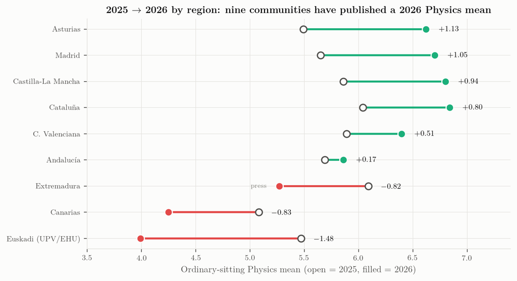

Figure 3: 2025 → 2026 by community. Open circle = 2025, filled = 2026; red = fell, green = rose. Cataluña is on its “aptes” basis for both years, Madrid values are chart labels rounded to one decimal, Extremadura’s 2026 value is press-reported.

Nine of seventeen communities have a published or retrievable 2026 Física mean. Six rose, three fell, and the three that fell are Euskadi, Canarias and Extremadura. Weighted by the number of presented students where it is known (Canarias, C. Valenciana, Cataluña, Castilla-La Mancha), the change outside Euskadi is $+0.58$; the median change over the eight other communities is $+0.65$. Read together with the table of annual changes in the previous chapter, this is the central comparative fact of the study:

> In 2025 the Physics mean fell in 14 of 17 communities (mean $-0.81$). In 2026 it **recovered** in six of the nine communities that have reported — five of them by $+0.5$ to $+1.13$, Andalucía by $+0.17$ — and fell further in three. The competency model of RD 534/2024 was applied in all seventeen in both years. What differs between Cataluña ($+0.80$) and Euskadi ($-1.48$) is not the legal framework; it is the paper, the marking scheme and the tribunals of each community.

## 3.2 Small multiples, 2015–2026

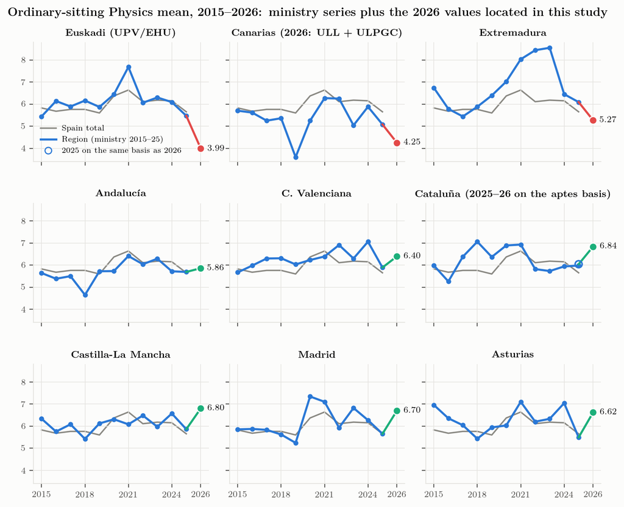

Figure 4: Ordinary-sitting Física mean by community, 2015–2025 from the Ministry cube (blue) with the Spanish total (grey), extended to 2026 with the values located in this study (red = fell, green = rose).

## 3.3 Two long series that did not exist in the project before

**Castilla-La Mancha, 2021–2026, both sittings** (UCLM Power BI). The ordinary mean went 6.08, 6.48, 5.97, 6.57, 5.86, **6.80** with pass rates 71.7, 75.1, 71.2, 76.6, 65.6, **80.1 %** on 1 589–1 795 presented students each year; the extraordinary sitting sits 1.2–2.8 points lower (3.97 in 2026 on 142 presented). The 2025 dip and 2026 recovery are exactly the national pattern. The dashboard also gives the 2026 result by province (Albacete 6.75, Ciudad Real 6.91, Cuenca 6.68, Toledo 6.77): within a single tribunal system the between-province spread is 0.23 points, a useful yardstick for what “normal” geographic dispersion looks like under one paper and one marking scheme.

**La Rioja, 2010–2022** (UR chart-only PDF). Física ordinary means 4.49, 5.49, 6.73, 5.63, 6.17, 5.78, 6.10, 6.33, 6.61, 6.15, 6.97, 8.31, 7.43, with pass rates 41.8 % in 2010 and 63.6 % in 2011 before settling at 66–86 % in normal years (94 % in 2021). This matters for Euskadi because it shows that the **2010–2011 trough was national**: La Rioja’s 4.49 / 41.8 % in 2010 mirrors Euskadi’s 4.45 / 46.3 %, and both had gained two points by 2012 (Euskadi in one step, La Rioja in two). The Basque series’ worst historical years were not a Basque anomaly either.

## 3.4 Comparability, stated once

The figures in Table 6 are not a designed experiment and the following differences are irreducible:

- **Denominator.** Cataluña’s mean is over students *eligible for university assignment*; everyone else’s is over students who sat the exam. Cataluña’s 2025 value on the same basis (6.04) is used for its change, so the *change* is comparable even if the level is not.
- **Precision.** Madrid’s values are chart labels to one decimal; Andalucía, Extremadura and Asturias publish the mean but not the number of examinees.
- **Population.** The Ministry 2025 baselines include FP and foreign-access students; university releases sometimes report Bachillerato students only. The effect on Física, a subject taken overwhelmingly by Bachillerato science students, is small (≤ 0.06 in eight of the nine comparators; 0.11 for Cataluña).
- **Revision stage.** Some releases are provisional (before revision), some are final. EHU’s 3.99 is the figure the university itself chose to present on 6 July, after the revision window.

None of these can turn a $+0.8$ into a $-1.5$. The direction and rough magnitude of the 2026 divergence are robust to every caveat listed.

## 3.5 Bottom line for the Basque question

If the 2026 Basque result had been caused by the competency model as such, the other sixteen communities — which use the same model — would show the same sign in 2026. They do not; most show the opposite sign. The Basque result is regional, and it is shared, in a slightly milder form, by one other region with a documented history of Physics volatility (Canarias) and possibly by a third (Extremadura). The next chapter asks what the shape of the grade distribution can add.

# 4 The shape of the collapse

*What the published moments imply about the 2026 grade distribution, checked against the Canarias histograms*

## 4.1 What EHU published, and what it implies

For Física 2026 the university published four summary statistics (Euskal Herriko Unibertsitatea, 2026b): the mean $\bar{x} = 3.99$ over $N = 2\,066$ examinees, the pass share $P(x \ge 5) = 0.398$, the low-score share $P(x \le 2) = 0.245$ (2025: 0.10) and the zero share $P(x = 0) = 0.032$. No histogram, no standard deviation, no pass *count*. With $N = 2\,066$ the rounded percentages pin the counts to narrow intervals: 822–823 passes, 506–507 exams at two points or less, 66–67 zeros. These are arithmetic consequences, not observations, and are used only as such.

A mean, a pass rate and a tail share are three constraints. A two-parameter family on $[0,10]$ with a point mass at zero,

$$f(x) = p_0\,\delta(x) + (1-p_0)\,\frac{1}{10}\,\mathrm{Beta}\!\left(\tfrac{x}{10};\,a,b\right),
\qquad p_0 = 0.032 ,$$

can be fitted to them by least squares in $(\log a, \log b)$. The Beta family is not a theory of how marks arise; it is the simplest smooth density on a bounded interval that can be unimodal, flat or J-shaped, which is what is needed to see whether “3.99 / 39.8 % / 24.5 %” describes a shifted bell or a different shape altogether. The same fit is made for 2025 (mean 5.47, pass 62.3 %, 10 % at ≤ 2; the zero share was not published and 1.2 % is assumed, with a sensitivity check in `results.json`).

Table 7: Beta-mixture fits to the published Euskadi Física moments. “SD (model)” and the tail shares are model-implied, not observed. Residuals of the three constraints are below 0.05 in every case (`results.json → beta_fits`).

| Fit | a | b | SD (model) | Median | % ≥ 7 | % ≥ 9 | % < 5 |
| --- | --- | --- | --- | --- | --- | --- | --- |
| Euskadi 2025 (5.47 / 62.3 % / 10 % ≤2) | 2.00 | 1.61 | 2.39 | 5.61 | 30.3 | 5.9 | 41.5 |
| Euskadi 2026 (3.99 / 39.8 % / 24.5 % ≤2) | 1.27 | 1.81 | 2.52 | 3.80 | 14.6 | 2.1 | 64.9 |

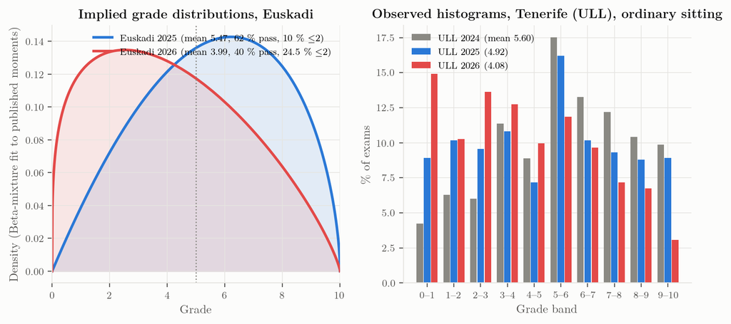

Figure 5: Left: implied grade densities for Euskadi 2025 and 2026 (Beta-mixture fits; the point mass at zero is not drawn). Right: observed histograms of the Tenerife (ULL) Física exam, June 2024, 2025 and 2026, from the ULL statistics dashboard.

The 2025 fit is a mild bell with mode near 6 ($a = 2.0,\ b = 1.6$). The 2026 fit has $a = 1.27 < b = 1.81$: a density skewed towards the low end, zero at the origin, with its mode near 2.5 (against 6.2 in 2025) and roughly flat band shares of 12–13 % across $[0,5)$ before declining, with an implied median of 3.8, an implied share of marks above 7 that falls from 30 % to 15 %, and a share above 9 that falls from 6 % to 2 %.

Three moments cannot, however, distinguish a low-skewed density from a bell that has been pushed down against the floor: shifting the 2025 fit by $-1.48$ and letting the mass below zero pile up in the lowest band reproduces $P(x \le 2) \approx 0.23$ and $P(x \ge 5) \approx 0.38$, close to the published 0.245 and 0.398. What the moments *do* establish is the opposite of a subgroup effect. If 2026 had been a normal year for most candidates and a disaster for a minority — say, the scripts of a few of the 41 tribunals — the low tail would be a lump added to an otherwise 2025-like distribution, and a quarter of all candidates could not end up at two points or less while the pass rate stayed near 40 %. The 2026 numbers describe a **cohort-wide displacement of roughly one and a half points** with the lower part of the cohort compressed into the 0–2 band. Whatever the cause, it acted on almost everyone.

## 4.2 The Ministry grade bands, 2015–2025

The Ministry cube gives, for every community and year, the distribution of Physics marks in six bands. For Euskadi (specific phase, ordinary sitting):

Table 8: Share of Basque Física examinees by grade band, ordinary sitting, 2015–2025 (Ministry cube, `data/analysis/euskadi_grade_bands_2015_2025.csv`).

| Year | [0-5) | [5-6) | [6-7) | [7-8) | [8-9) | [9-10] |
| --- | --- | --- | --- | --- | --- | --- |
| 2015 | 36.4 | 16.3 | 14.4 | 13.2 | 11.1 | 8.5 |
| 2016 | 27.7 | 14.5 | 11.5 | 14.2 | 16.4 | 15.6 |
| 2017 | 33.0 | 14.2 | 13.2 | 13.0 | 12.3 | 14.3 |
| 2018 | 29.3 | 12.8 | 13.8 | 13.0 | 12.4 | 18.6 |
| 2019 | 33.8 | 13.8 | 13.0 | 11.8 | 12.3 | 15.4 |
| 2020 | 24.9 | 11.6 | 13.1 | 15.7 | 16.7 | 18.0 |
| 2021 | 10.6 | 7.8 | 9.9 | 15.2 | 20.5 | 36.0 |
| 2022 | 30.6 | 13.2 | 13.4 | 13.2 | 12.5 | 17.2 |
| 2023 | 29.3 | 12.3 | 11.1 | 12.6 | 14.5 | 20.2 |
| 2024 | 27.0 | 16.0 | 13.8 | 17.6 | 15.3 | 10.3 |
| 2025 | 37.7 | 18.0 | 14.1 | 12.7 | 10.7 | 6.7 |

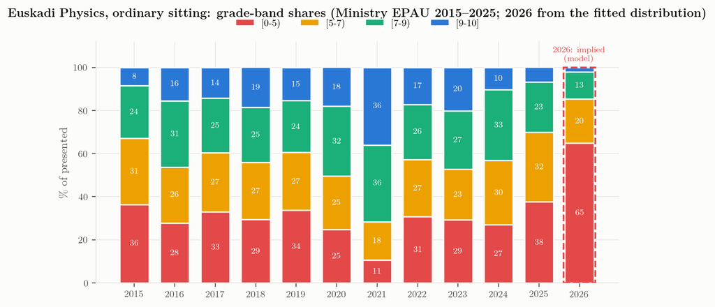

Figure 6: Grade-band shares of Basque Física examinees, 2015–2025 (observed, Ministry) and 2026 (implied by the fitted distribution, dashed outline).

Two things stand out. The failing band $[0,5)$ had been 24.9–36.4 % in every normal year (36.4 % in 2015, 24.9 % in 2020) and 37.7 % in 2025; in 2026 it is **60.2 %** — that one is arithmetic, not a model, since EHU published a 39.8 % pass rate. (The Beta fit puts it at 64.9 %: the fit under-predicts the published pass rate by 4.7 points, and every tail share read off it inherits that bias.) And the **top band $[9,10]$ had already collapsed in 2025** (6.7 %, from 10.3 % in 2024 and 15–20 % in 2018–2023 outside the 36 % of 2021) before the mean did: so the top of the Basque distribution went before the middle did. The competency model is not what removed it: the larger single-year fall in that band was 2023 → 2024, 20.2 % → 10.3 %, on the last pre-LOMLOE paper — which is the 2024 shape step the decomposition isolates.

## 4.3 The Canarias mirror: observed histograms

Euskadi publishes moments; the two Canarian universities publish full histograms, zero counts, ten counts and means by sex on their Power BI dashboards (Universidad de La Laguna, Gabinete de Análisis y Planificación, 2026; Universidad de Las Palmas de Gran Canaria, Dirección de Acceso, 2026). Their 2026 results are the closest observed analogue of the Basque case.

Table 9: Física, June sitting, Tenerife (ULL) and Las Palmas (ULPGC), 2024–2026, read from the universities’ dashboards on 18 September 2026. Files: `data/found_canarias_ull_powerbi.csv`, `data/found_canarias_ulpgc_powerbi.csv`.

| University, year (June) | Exams | Mean | % < 2 | % < 5 | % in [5,6) | % ≥ 9 |
| --- | --- | --- | --- | --- | --- | --- |
| ULL 2024 | 731 | 5.60 | 10.5 | 36.8 | 17.5 | 9.8 |
| ULL 2025 | 796 | 4.92 | 19.1 | 46.6 | 16.2 | 8.9 |
| ULL 2026 | 683 | 4.08 | 25.2 | 61.5 | 11.9 | 3.1 |
| ULPGC 2024 | 796 | 6.15 | 6.5 | 32.0 | 12.6 | 16.1 |
| ULPGC 2025 | 758 | 5.25 | 14.0 | 45.4 | 13.3 | 12.5 |
| ULPGC 2026 | 712 | 4.41 | 22.6 | 57.2 | 12.8 | 4.9 |

Table 10: Percentage of exams per one-point band, same sources.

| Band | ULL 2026 | ULL 2025 | ULL 2024 | ULPGC 2026 | ULPGC 2025 | ULPGC 2024 |
| --- | --- | --- | --- | --- | --- | --- |
| [0-1) | 14.9 | 8.9 | 4.2 | 11.2 | 6.6 | 2.9 |
| [1-2) | 10.2 | 10.2 | 6.3 | 11.4 | 7.4 | 3.6 |
| [2-3) | 13.6 | 9.6 | 6.0 | 10.0 | 10.7 | 6.7 |
| [3-4) | 12.7 | 10.8 | 11.3 | 13.1 | 11.3 | 9.3 |
| [4-5) | 10.0 | 7.2 | 8.9 | 11.5 | 9.4 | 9.6 |
| [5-6) | 11.9 | 16.2 | 17.5 | 12.8 | 13.3 | 12.6 |
| [6-7) | 9.7 | 10.2 | 13.3 | 9.8 | 10.8 | 11.4 |
| [7-8) | 7.2 | 9.3 | 12.2 | 9.4 | 11.1 | 13.6 |
| [8-9) | 6.7 | 8.8 | 10.4 | 5.9 | 6.9 | 14.3 |
| [9-10) | 3.1 | 8.9 | 9.8 | 4.9 | 12.5 | 16.1 |

The 2026 Tenerife histogram — 683 exams, 15 % in $[0,1)$, 25 % below 2, 61 % below 5, 3 % at or above 9, mean 4.08 — is, band for band, what the Basque fit predicts for 2026 (13 % in $[0,1)$, 26 % below 2, 65 % below 5, 2 % above 9). Las Palmas 2026 (22.6 % below 2, 57 % below 5, mean 4.41) is the same shape one step less severe. Both islands had a 2024 concentrated in the upper half (ULL modal at $[5,6)$; ULPGC rising, with one dip at [6,7), to a mode at $[9,10]$), a flattened 2025, and a 2026 that is flat-to-decreasing across the scale with a heavy $[0,2)$ tail.

Two details of the Canarian histograms are worth carrying back to Euskadi:

- **The pass-line pile-up disappeared.** In 2024 and 2025 the $[5,6)$ band is the modal band at ULL (17.5 %, 16.2 %) — the familiar signature of markers rounding borderline scripts up to 5. In 2026 it is 11.9 %, still the fourth-largest band but no longer a peak that stands out from its neighbours (10.0 % and 9.7 %). Whatever happened in 2026, it did not include a benevolent hand at the threshold.
- **Zeros multiplied.** ULL: 5 → 18 → 30 zeros (0.7 % → 2.3 % → 4.4 % of exams). Euskadi 2026: 3.2 %. Zeros in a four-problem paper are not students who tried and failed; they are blank or near-blank scripts, i.e. a decision by the candidate. Their growth is a participation signal (students sitting Física because they enrolled for it, then giving up) as much as a difficulty signal.

## 4.4 Variance, not only level

Where standard deviations are published — Valencia gives them per university — the 2026 Física SD is 2.38 on a mean of 6.40, essentially unchanged from 2.28 on 5.89 in 2025. The Basque fit implies an SD of 2.5 in 2026 against 2.4 in 2025: the coefficient of variation rises from 0.44 to 0.63 simply because the mean fell while the spread did not. In the language of the Ikastorratza comparison (Ruiz de Gauna & Sarasua, 2013), the Basque exam did not become a finer discriminator in 2026; it compressed everyone toward the floor while keeping the same absolute dispersion.

## 4.5 What the shape rules out, and what it does not

A distribution with a quarter of the candidates at two points or less and a vanishing top decile, in a cohort whose school marks average 7.1 (Chapter 5), is not the product of one severe tribunal or one badly prepared school network: those would show up as a lump, not as a shift of the whole mass. It is consistent with a cohort-wide cause — a paper that a large fraction of candidates could not start, marking criteria applied strictly to all, or both — and with the disappearance of any compensating leniency at the pass threshold that the Canarian histograms make visible. The Canarian coordinators wrote exactly this diagnosis for their milder 2025 (Gobierno de Canarias, Subcomisión de Física, 2025). The Basque tribunal-level data that EHU says it holds (Chapter 6) would separate the paper from the marking; the published moments cannot.

# 5 Subjects, sittings, participation and groups

*Física against its neighbours, June against July, exam marks against school marks, and the sex and language dimensions*

## 5.1 The science block, 2025 → 2026, five regions

Five communities have published subject means for both 2025 and 2026: Euskadi (EHU deck), Cataluña (Govern dossiers, “aptes” basis), Madrid (chart labels), Andalucía (Junta table; 2025 baselines for Matemáticas II and Química from the Ministry cube) and Asturias (Uniovi releases; same treatment).

Table 11: Change of the ordinary-sitting mean, 2025 → 2026, by subject and region. File: `data/analysis/subjects_2025_2026_by_region.csv`.

| Subject, Δ 2025→2026 | Euskadi | Cataluña | Madrid | Andalucía | Asturias |
| --- | --- | --- | --- | --- | --- |
| Física | -1.48 | +0.80 | +1.10 | +0.17 | +1.13 |
| Matemáticas II | -1.67 | -1.94 | +0.50 | -0.59 | +0.10 |
| Química | -0.21 | -0.34 | -0.30 | -0.22 | +0.28 |
| Biología | +0.15 | -0.21 | +0.70 | — | — |
| Historia de España | -0.83 | — | — | — | — |
| Euskara II | -0.48 | — | — | — | — |
| Lengua Castellana | +0.03 | — | — | — | — |
| Hª Filosofía | -0.29 | — | — | — | — |

Table 12: Ordinary-sitting mean, 2026, same sources.

| Subject, mean 2026 | Euskadi | Cataluña | Madrid | Andalucía | Asturias |
| --- | --- | --- | --- | --- | --- |
| Física | 3.99 | 6.84 | 6.70 | 5.86 | 6.62 |
| Matemáticas II | 5.06 | 4.18 | 6.30 | 5.95 | 6.86 |
| Química | 6.03 | 6.04 | 5.90 | 5.27 | 7.67 |
| Biología | 6.60 | 6.02 | 6.30 | — | — |
| Historia de España | 6.08 | — | — | — | — |
| Euskara II | 6.33 | — | — | — | — |
| Lengua Castellana | 6.42 | — | — | — | — |
| Hª Filosofía | 6.81 | — | — | — | — |

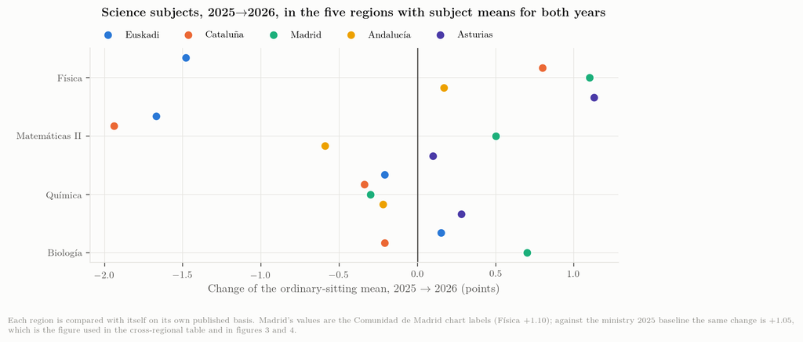

Figure 7: Change of the ordinary-sitting mean 2025 → 2026 for the four science subjects, by region.

Read by rows, Table 11 says that **no subject moved the same way everywhere**. Física fell in Euskadi and rose in the other four; Matemáticas II fell in Euskadi, Cataluña and Andalucía and rose in Madrid and Asturias; Química fell slightly in four of five and rose in Asturias; Biología rose in Euskadi and Madrid and fell in Cataluña (not published for Andalucía and Asturias). Read by columns, Euskadi is the only community where the two hardest quantitative subjects fell together by more than a point and a half ($-1.48$, $-1.67$) while Química ($-0.21$), Biología ($+0.15$) and Lengua ($+0.03$) barely moved. The Basque 2026 problem is a *science-technical block* problem, and within that block it is a Física-and-Matemáticas problem, not a general marking or cohort problem — Química is marked by tribunals drawn from the same pool of secondary teachers.

Cataluña shows the mirror image: a Matemàtiques paper that produced the lowest subject mean of a decade (4.18) and, as the regional press reported, some 2 000 revision requests [press; no official figure is archived in this study], next to a Física paper that produced the best Física mean in five years (6.84). Two subjects, one exam authority, one cohort, opposite outcomes: the paper is the variable.

## 5.2 Ordinary versus extraordinary

The July sitting is a different population — candidates who failed or did not sit in June — and it is almost always below June — by $1.85 \pm 0.86$ points across the Ministry community-years, over a range from $-0.34$ (Murcia 2022, one of only two community-years in which July came out above June) to $+4.05$.

Table 13: Euskadi Física, ordinary and extraordinary means (Ministry cube, pooled phases).

| Year | Ordinary | Extraordinary | Gap |
| --- | --- | --- | --- |
| 2015 | 5.44 | 3.64 | 1.80 |
| 2016 | 6.14 | 3.01 | 3.13 |
| 2017 | 5.89 | 3.93 | 1.96 |
| 2018 | 6.16 | 3.35 | 2.81 |
| 2019 | 5.87 | 2.38 | 3.49 |
| 2020 | 6.44 | 4.67 | 1.77 |
| 2021 | 7.68 | 4.66 | 3.02 |
| 2022 | 6.06 | 4.88 | 1.18 |
| 2023 | 6.30 | 4.06 | 2.24 |
| 2024 | 6.09 | 4.11 | 1.98 |
| 2025 | 5.47 | 3.21 | 2.26 |

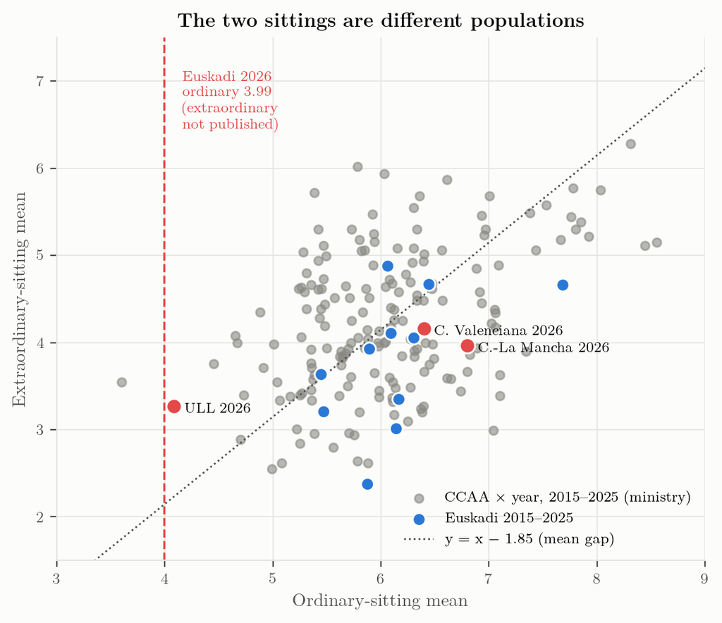

Figure 8: Extraordinary against ordinary Física mean, every community and year 2015–2025 (grey), Euskadi (blue), and the three 2026 extraordinary values located (red). The dotted line is $y = x - 1.85$, the panel-mean gap.

Across the 187 community-years the gap averages $1.85 \pm 0.86$ points. The three 2026 extraordinary values found — Comunitat Valenciana 4.16 (777 presented), Castilla-La Mancha 3.97 (142), Tenerife 3.27 (97) — sit on the historical relation, Tenerife low among them (gap 0.81, 1.2 SD below the mean gap, with 29 of the 187 community-years lower still). **EHU has not published the July 2026 Física mean**; only the global July pass rate (71.40 % of 1 332 presented, against 83.2 % in July 2025 and 90.6 % in July 2024 according to EHU’s own annual reports; the press comparison quoted 90.6 % as the 2025 figure) and the observation that the 624 candidates who re-sat to *improve* a June mark chose “sobre todo Matemáticas II, Biología y Química” (Donostitik, 2026). If the historical gap held, the Basque July Física mean would be near 2, which would be the lowest in the panel; if the July paper was pitched differently, it would not. This single number is the most informative unpublished Basque figure after the tribunal spread.

## 5.3 Who sits Física, and how many

Table 14: Euskadi Física, specific phase, ordinary sitting: enrolled, presented and presentation rate (Ministry cube; 2026 from the EHU deck, enrolment not published).

| Year | Enrolled | Presented | Presented / enrolled % |
| --- | --- | --- | --- |
| 2015 | 1 756 | 1 464 | 83.4 |
| 2016 | 1 642 | 1 369 | 83.4 |
| 2017 | 2 461 | 1 789 | 72.7 |
| 2018 | 2 603 | 1 749 | 67.2 |
| 2019 | 2 550 | 1 665 | 65.3 |
| 2020 | 2 564 | 1 638 | 63.9 |
| 2021 | 2 371 | 1 774 | 74.8 |
| 2022 | 2 334 | 1 742 | 74.6 |
| 2023 | 2 429 | 1 830 | 75.3 |
| 2024 | 2 341 | 1 788 | 76.4 |
| 2025 | 2 597 | 2 189 | 84.3 |
| 2026 | — | 2 066 | — |

Two structural facts. First, Física enrolment in Euskadi has been flat at 2 334–2 603 since 2017 while the Basque PAU cohort grew from ≈ 9 900 to ≈ 12 300, so Física’s share of the cohort fell from about a quarter to about a fifth. Second, the presentation rate jumped from 63.9–76.4 % (2017–2024) to 84 % in 2025: under the 2025 rules far fewer enrolled students skipped the Física exam. The 2025 pool therefore contained some 200–530 candidates (depending on which earlier rate is taken as the counterfactual) who, under the previous incentives, would not have sat — plausibly the weakest — and the 2025 fall of $-0.62$ is partly this compositional change. For 2026 the enrolment is unpublished; 2 066 presented is 6 % fewer than in 2025 and 16 % more than in 2024.

## 5.4 School marks against exam marks

The Basque Inspectorate’s *Resultados escolares 2024-2025* (Gobierno Vasco, Inspección de Educación, 2025) gives, for 2º Bachillerato Física across all networks and linguistic models: 4 541 students evaluated, 4 455 passed (98.11 %), mean 7.09 — public 7.04, private/concertada 7.15; Araba 7.09, Bizkaia 7.11, Gipuzkoa 7.08; model A 6.93, B 7.31, D 7.09.

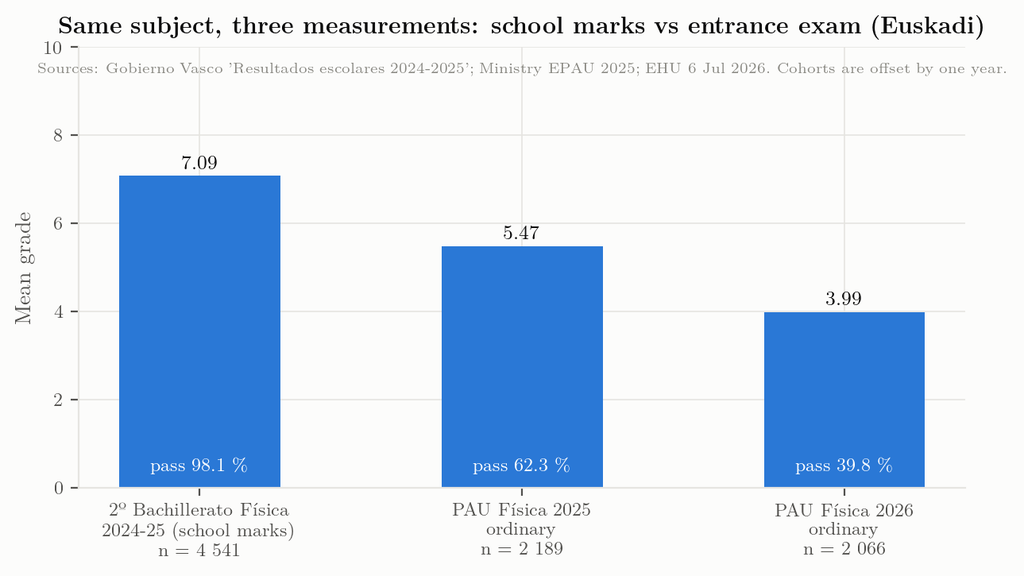

Figure 9: The same subject measured three times: 2º Bachillerato school marks (2024-25 cohort), PAU Física 2025 and PAU Física 2026 (ordinary sitting). Cohorts are offset by one year.

Three consequences. (i) Only about 45–48 % of the students who take Física in 2º Bachillerato sit PAU Física ($2\,189 / 4\,541 = 0.48$ for the 2025 exam; $2\,066 / 4\,541 = 0.45$ for 2026 against the same, offset, cohort). The PAU Física population is a self-selected half of the Bachillerato Física population — presumably the half that needs the weighting for engineering and physics degrees. (ii) Even that stronger half scored 1.6 points below its school mark in 2025 and, if school marks did not move, 3.1 points below in 2026. (iii) The school pass rate is 98 %; the exam pass rate is 40 %. Whatever the 2026 paper measured, it is not what Bachillerato Física teachers certify. The 2025-26 school results, due in the coming months, will give the matched cohort.

The centre-level scatter of the July package (`hist_evolution`, 2010–2016) already showed a mean school-minus-exam gap of about one point across *all* subjects; a three-point gap in a single subject is of a different order.

## 5.5 Sex and language

Table 15: Euskadi Física, ordinary sitting, by sex and by exam language, 2010–2022 (EHU annual reports; no breakdown has been published since).

| Year | Men | Women | W − M | % women enrolled | Euskera track | Castilian track | EU − ES | % euskera track |
| --- | --- | --- | --- | --- | --- | --- | --- | --- |
| 2010 | 4.50 | 4.35 | -0.15 | 34.9 | 4.24 | 4.77 | -0.53 | 61.4 |
| 2011 | 4.41 | 4.51 | +0.10 | 33.8 | 4.44 | 4.46 | -0.02 | 62.4 |
| 2012 | 6.44 | 6.61 | +0.17 | 32.6 | 6.59 | 6.35 | +0.24 | 62.5 |
| 2013 | 6.16 | 6.18 | +0.02 | 30.6 | 6.05 | 6.36 | -0.31 | 62.8 |
| 2014 | 5.69 | 5.68 | -0.01 | 32.3 | 5.62 | 5.81 | -0.19 | 61.5 |
| 2015 | 5.37 | 5.62 | +0.25 | 31.5 | 5.40 | 5.54 | -0.14 | 64.9 |
| 2016 | 6.12 | 6.24 | +0.12 | 30.6 | 6.07 | 6.34 | -0.27 | 67.5 |
| 2017 | 5.80 | 6.14 | +0.34 | 31.5 | 5.85 | 6.00 | -0.15 | 68.4 |
| 2018 | 6.12 | 6.31 | +0.19 | 32.0 | 6.13 | 6.28 | -0.15 | 68.5 |
| 2019 | 5.85 | 5.99 | +0.14 | 32.9 | 5.88 | 5.92 | -0.04 | 71.0 |
| 2020 | 6.36 | 6.65 | +0.29 | 33.7 | 6.52 | 6.27 | +0.25 | 75.2 |
| 2021 | 7.51 | 8.02 | +0.51 | 34.5 | 7.72 | 7.62 | +0.10 | 73.5 |
| 2022 | 5.92 | 6.30 | +0.38 | 36.0 | 5.97 | 6.29 | -0.32 | 75.0 |

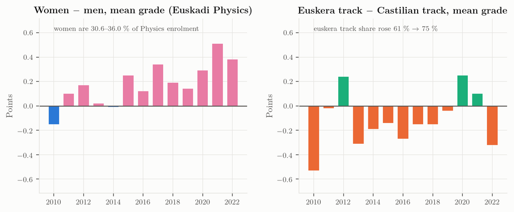

Figure 10: Euskadi Física, ordinary sitting: women − men (left) and euskera − castellano track (right) differences in the mean, 2010–2022.

Women are 30.6–36 % of Basque Física enrolment and, from 2011, outscore men in every year but 2014 ($-0.01$) by $+0.21$ on average, with the gap widening after 2016 ($+0.34$ in 2017, $+0.51$ in 2021, $+0.38$ in 2022). The Canarian dashboards show the same sign in 2026 under collapse conditions: ULL women 4.09 vs men 4.07, ULPGC women 4.50 vs men 4.38. The euskera track rose from 61 % to 75 % of Física candidates over 2010–2022; its mean was below the castellano track by 0.1–0.3 in most years, and above it in 2012, 2020 and 2021. Neither dimension has been published for Física since 2022, and EHU’s 6 July statement that its global 2026 analysis found no bias by linguistic model or network referred to Euskara II, not Física.

# 6 Interpretation and the 2027 question

*Which explanations survive the evidence, what would decide between the rest, and what to ask for*

**Audit of 19 September 2026**

This chapter was audited after it was written — every number recomputed, every figure re-derived, the argument read step by step. The corrections are applied in the text below and listed, with what they cost, in Audit and in the last section of this chapter. It was audited a second time on 20 September, which corrected the first audit in turn and added the decomposition that now closes the chapter. Three claims of the first version were withdrawn: that the COVID-era plateau *reshaped* the grade distribution (it is a level effect), that Euskadi shows a distinctive turn on the conditional top-band measure in 2024 (four other communities show the same), and that the PAU and PISA series fall at the same rate (the fit was stale, and the two records are steps rather than slopes).

## 6.1 The hypotheses, one by one

The evidence assembled in Chapters 2–5 is observational and the exam changes every year, so nothing below is a causal estimate. But the hypotheses that circulated in July can be sorted by what the data allow.

**H1a — “The competency model (RD 534/2024), as a national frame, is to blame.”** *Explains 2025, not 2026.* The model was applied in all seventeen communities in both years. In 2025 the Física mean fell in 14 of 17, by $-0.81$ on average — Euskadi’s $-0.62$ was below the national move. In 2026 six of nine reporting communities rose under the same model — five by $+0.5$ to $+1.13$, Andalucía by $+0.17$; Euskadi fell $-1.48$. A national cause cannot produce opposite signs in the same year. The Basque institutions’ July framing (“el nuevo enfoque competencial pasa factura”) is therefore at most a description of 2025. There is a further difficulty with it: the only systematic rating of PAU papers’ competency orientation, covering six communities over 2015–2025 (Sánchez-Tarazaga & Gimeno Rovira, 2026), places País Vasco and Cataluña at the *top* of the range before the reform, so the Basque papers did not “become competency-based” in 2025 — they were already the most competency-oriented in Spain, and Cataluña, rated alongside them, rose in 2026.

**H1b — “It is not the model; it is this conversion, at this speed.”** *First-order candidate, and the strongest surviving explanation of 2026.* The wording matters and has been corrected: an earlier form of this hypothesis named the competency model as implemented here, which invites the reading that competency examining depresses marks. The Catalan archive refutes that reading. Cataluña has set papers with real settings and explicit justification demands in every year from 2020 — five before the decree — and did not collapse; with fifteen more of its papers added, one mechanical measure now dates its step to **2020** (a traditional decade at 17.7 % of items demanding justification against 50.0 % in 2020–2023) and prices it: against the fifteen-community field its position moved $-0.85$, on a design whose minimum detectable shift is $1.26$ and of which 59 % is the field rising rather than Cataluña falling — a bound and not a coefficient, and smaller than Euskadi’s second year alone (the event study). Its *lowest* traditional year is 6.2 %, so it never examined without asking anyone to justify anything, where the Basque paper carried zero competency marks as late as 2024: Cataluña intensified a practice it had, Euskadi introduced one it did not; in 2026 it halved its competency-coded marks and its position against the field did not move (The papers themselves). What is specific here is therefore not the destination but the route: 0 to 25 to 62.5 per cent of the marks in two sittings, with optionality halved, the syllabus reopened and a new marking regime in its second year, in a system with no prior experience of the style. H1a fails because the frame was national and the outcomes were not. That is an argument against the frame, not against the model: what a community did with the frame is a different variable, and it is one the papers themselves record. The content audit of the 2025 and 2026 papers of the nine reporting communities (The papers themselves) yields a reform-intensity index from four axes that move independently — optionality withdrawn, competency marks, substantive context, contextualised marks. Euskadi scores $+1.76$ and is first of the nine; the next community, Castilla-La Mancha, is at $+0.39$, and the other seven are at or below zero. Five of the six communities that rose in 2026 carry **negative** indices: Asturias $-0.19$, Madrid $-0.44$, Cataluña $-0.72$, Comunitat Valenciana $-0.71$, Andalucía $-0.45$; the exception is Castilla-La Mancha at $+0.39$, which added one obligatory contextualised item and rose $+0.94$. That exception is not the counter-example it appears to be, because the two communities are at different stages: 2026 is Castilla-La Mancha’s *first* year of conversion, as 2025 was Euskadi’s, and both first years were harmless — $+0.77$ and $+0.03$ against the field respectively. The fall is a second-year event, and the comparison that would test it has not happened. It will in 2027: if the mechanism is the depth of conversion in the second year, Castilla-La Mancha should fall if it goes further and not if it stays at 20 %. Marking severity applied cautiously in year one and fully in year two predicts the same shape, which is the collinearity of the identification argument rather than an escape from it. Across the nine, $r = -0.70$, $p = 0.035$. The reading this supports is narrower than a dose-response: drop Euskadi and the correlation falls to $r = -0.40$, $p = 0.33$, so the relation *is* Euskadi. Euskadi moved from one competency exercise to half the marks, halved its optionality and changed format at once — the only paper in the set that changed genre between the two years — and it is the only one that did. H1b therefore records one community implementing the frame completely and alone, which is exactly what makes it a candidate and exactly what stops the nine-community panel from testing it.

**H1c — “Fifteen years of a predictable paper built a teaching equilibrium, and two courses were not enough to retune it.”** *Plausible, unmeasured, not separable from H1b — and the candidate with the sharpest testable prediction.* The scale of what had accumulated is measurable. For fifteen years **forty per cent of the marks came from a closed list of titles**, and only **22 distinct titles** were ever set across 120 slots — a mean recurrence of 5.5, the commonest twelve times — while **optionality stood at 100 %**: every item could be declined. Fourteen of the fifteen modern-physics problems of that period were photoelectric, and fission and fusion existed only as theory titles, examinable as prose and never as a calculation, until carbon-14 dating and plutonium-239 decay appeared as problems in 2026 (Sixteen years of one paper). A teacher optimising for results under that instrument would teach the twenty-two titles, drill the recurring templates and let the rest go — the correct response to the incentive, not a failure of one. The exam had been the curriculum, and the *de facto* narrowing is what the exam wrote: no text ever excluded mirrors, standing waves or nuclear decay; they were simply never set.

The hypothesis is about **practice, not information**, and the distinction is load-bearing. The reopening was announced in 2024 and the two academic years 2024–25 and 2025–26 were designated transitional, so the schools knew and were given two courses; nothing here should be read as an information failure. What the announcement could not manufacture is worked-example banks, mock papers, a sequence for the year with room for the new material, and the teacher’s own fluency in setting and marking questions of a kind never previously set. Those accumulate, and fifteen years of them were tuned to an instrument that ceased to exist. In June 2026 the new sub-topics sat in *optional* slots — and the bound is far tighter than that phrasing suggests. The two slots that offered **no optionality** were set on sub-topics ranked 1st and 11th of 15 by frequency (circular orbits, set **18 times**; induction, 5), while the two never set before, standing waves and radioactive decay, both sat **where a choice was offered**, each beside an alternative set 10 and 14 times. A candidate could answer 1, 2, 3b and 4a — four sub-topics set **47 times** between them — and meet nothing new (Sixteen years of one paper). **The reopened syllabus was avoidable in June, and the mean fell 1.48 anyway**, so meeting unfamiliar content is close to excluded for the ordinary sitting. The inertia therefore relocates into two channels the content version did not name: preparation spread thinner across a syllabus that had to be *covered* because nobody could know what would be *set*, leaving the old route less well drilled than in 2024; and familiar physics in an unfamiliar form, since slot 1 was the archive’s most-set sub-topic presented as a headline to be read, judged and explained.

It is also the hypothesis Cataluña does not have available to it: that community has set all-problems papers with real settings and explicit justification demands since at least 2020, with optionality near a half and no closed theory list, so there was no equilibrium to unlearn when the decree arrived (The papers themselves). Two systems entered the same reform carrying different amounts of accumulated practice, and what differed was not notice but practice.

No published aggregate separates H1c from H1b — both are properties of one paper in one year and both displace the whole distribution. But unlike its rivals H1c now predicts something testable inside the June paper itself. Slot 4 offered the photoelectric effect (set 14 times) against C-14 dating (never set). Two quantities settle it: how many candidates took 4a, and how they scored on it. **If candidates overwhelmingly took the familiar option and still scored worse on it than their 2024 and 2025 counterparts, content novelty is excluded by the paper’s own internal evidence**, and preparation, genre and marking must carry the fall between them. That is the smallest measurement identified anywhere in this study, and it bears on the largest question.

**H2 — “The 2026 Basque Física paper was harder, or differently pitched, than its own 2025 paper and than other communities’ 2026 papers.”** *Consistent with everything.* The cohort-wide displacement of the distribution (Chapter 4), the confinement of the damage to Física and Matemáticas II with Química, Biología and Lengua unaffected (Chapter 5), the Catalan mirror image (Física up, Matemàtiques down, same authority, same cohort) and the Canarian coordinators’ own reading of their milder 2025 all point to the paper — its problems, its optionality (two of four problems with no choice in 2026), its marking scheme — as the first-order variable. The July package already noted that the 2026 ordinary paper’s gravitational problem contains a validity issue in its energy comparison. What belongs to H2 rather than to H1b is what is genuinely *format*: length, optionality and genre. Reading load rose $+39$ %, from 1 026 words of statement to 1 431 ($+45$ % on the whole-paper token count, 1 335 to 1 940); choice was halved, two of four problems carrying none, which simulation values at $-0.26$; and the paper changed genre. The competency conversion that accompanied them is H1b, and the two are separable as descriptions but not in the data. The comparison with the 2010–2024 Basque papers is in Sixteen years of one paper: the 2025 break (no theory questions, new structure, first numerical penalties) was absorbed better than the national average; the 2026 step (competencial half, choice halved, −0.1 list and symbolic-first, syllabus opened) is the one the grades react to. An item-level analysis of the 2026 scripts is the natural continuation.

**H3 — “Tribunals marked more severely.”** *Possible, unmeasured, and acknowledged by EHU.* The rector’s press conference reported “significant variation between evaluation panels” in Física among other subjects (Argia, 2026), and the 6 July deck published tribunal-mean ranges for Euskara (2.88–4.43), Lengua (5.80–6.92) and Inglés (6.65–7.56) but not for Física. Rater-severity effects of the size needed to move a subject mean by more than a point are not unknown in Spanish PAU marking (Veas & López-Pina, 2025), but the cohort-wide shape of the 2026 distribution says severity, if present, was general rather than confined to a few panels. Only the tribunal-level Física table settles this.

**H4 — “The cohort was weaker or differently composed.”** *Weak inside the PAU data, stronger outside it. The recruitment version fails outright (below) and the PAU shows no drift; but an externally marked instrument shows Basque science falling from +9 points above Spain to −5 over the decade, breaking in 2015 (below).* Presentation fell 5.6 % from 2025 and enrolment is unpublished, so a small compositional component cannot be excluded, but the school marks of the preceding cohort were 7.09 with 98 % passing, and the same students’ Química and Biología marks did not move. A weaker cohort does not fail Física and Matemáticas by 1.5 points while holding Química. The same test can be run against Euskadi’s own pre-COVID baselines: relative to 2015–2019, Basque Matemáticas II, Química and Biología sat $+0.1$ to $+1.6$ above baseline through 2021–2024 and $+0.27$, $-0.01$ and $+0.31$ in 2025, while Física was $-0.39$ in 2025 — the only Basque science subject clearly below its norm a year before the 2026 event and the year after the 2024 shape step (Química sits on it at $-0.01$; on a pooled-phase baseline Química is $-0.18$ and the contrast is weaker, which is why the convention is stated here) (`data/audit/basque_subjects_vs_baseline.csv`). Whatever PISA sees in the Basque science base, the Basque PAU sees it in Física only, and only from 2025.

### 6.1.1 Is the drift real?

H4 is usually posed as a claim about one cohort, but it has a slower version worth testing separately: that the students presenting for Física arrive a little less prepared each year, so that part of 2025 and 2026 is the end of a long drift rather than an event. The mechanism is concrete. Física is voluntary, its examined population grew 30 % over this decade — from 37,661 to 49,010 — and a subject that recruits more widely should be recruiting further down the distribution.

The counts matter here more than usual, and an earlier version of this section got them wrong. Física appears in both phases until 2016 and only in the specific phase from 2017, so counting the specific phase alone understates 2015 and 2016 by about 18 % — 30,839 against a true 37,661 in 2015. Those two years then present as small-cohort years that happen to have high means, and a dilution effect appears which is not there. Every count below is pooled across phases.

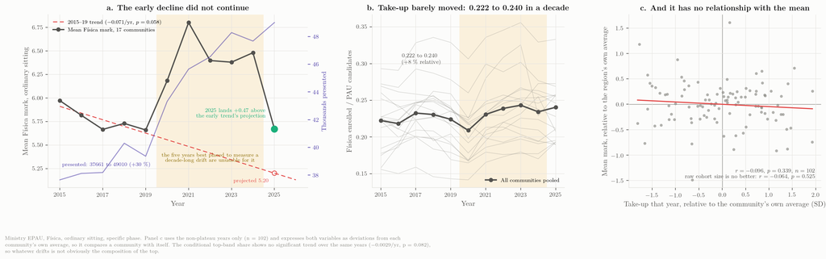

Figure 11: **a** — the national mean by year with the 2015–2019 trend extrapolated forward, and the number presented (pooled across phases) on the right-hand axis. The shaded plateau years are the ones that cannot be used to measure a drift. **b** — take-up, the share of each community’s PAU candidates sitting Física, with the pooled national series in black; it is flat. **c** — the dilution test on take-up: each point is a community-year, with both variables expressed as deviations from that community’s own average, so the comparison is a community against itself rather than against communities that differ for other reasons. The fitted line is flat, and the raw-cohort-size version of the same test is no better.

Three tests. The two that can see composition find nothing, and the one that appears to support the intuition cannot tell students from papers.

The pre-COVID years do decline, at $-0.071$ points a year with $R^2 = 0.75$ ($p = 0.058$) — five points falling steadily, which is what the intuition predicts. But the decline did not continue: extrapolated to 2025 that trend projects a mean of 5.20, and the actual 2025 mean is **5.67**, $+0.47$ above it. Whatever was pulling the mean down between 2015 and 2019 either stopped or was offset.

The dilution mechanism is not detectable at all, and this is where the count correction bites. On the undercounted series it looked real and modest — $r = -0.212$, $p = 0.032$ — which is what an earlier version of this section reported. On the pooled counts it disappears: $r = -0.064$, $p = 0.525$ over the same 102 non-plateau region-years. The entire apparent effect was two mislabelled years.

Panels b and c of Figure 11 test it on the variable that actually corresponds to the mechanism. Raw cohort size confounds a community whose whole candidate population grew with one in which a larger fraction chose Física; only the second is composition. Using `Lengua Castellana y Literatura II` — compulsory in the general phase, hence a count of candidates — as the denominator, take-up is the share of a community’s PAU candidates sitting Física. It has barely moved: **0.222 in 2015, 0.240 in 2025**, a rise of 8 % in relative terms across a decade. And within a community it is unrelated to the mean: $r = -0.096$, $p = 0.339$. Física is not visibly recruiting further down the distribution, because it is not visibly recruiting more widely at all.

And the shape measure shows nothing either. The conditional top-band share has no significant trend across the non-plateau years ($-0.0029$ a year, $p = 0.082$), which is where a recruitment effect should show first and most clearly.

The honest summary is that the drift is not visible on any measure that can see composition, and that the one measure suggesting a fall — the 2015–19 trend in the mean — cannot distinguish students from papers. The reason is visible in panel a of Figure 11 and is the same obstruction that produced the reference-frame problem: the five years in the middle of the decade are the plateau, and they are unusable for estimating a slow trend. Six year-points remain to fit a decade. That is why none of these tests is decisive, and it is a better reason to withhold judgement than any of the individual $p$-values — a drift of $-0.07$ a year would need about fifteen clean years to separate from noise, and this decade contains six.

One consequence for the reading of 2026: a slow drift and a one-year event are not competing explanations here. The composition channel, which is the one that could have been measured, contributes nothing detectable, and the pre-2019 decline in the mean — the only surviving evidence of a drift — is confounded between the students and the paper in exactly the way this chapter cannot resolve from PAU data alone.

### 6.1.2 The 2024 turn: not a level, but the largest negative move in the panel

The second audit, on 20 September, then asked the question neither version had asked. Both of them tested the *level* of the residual in 2024 and 2025 — whether Euskadi sat low — and the level is unremarkable. But “a turn” is a statement about a *change*, and the change had never been tested. Across the 170 year-to-year transitions in the panel, Euskadi’s conditional residual moved $-3.08$ standard deviations between 2023 and 2024. That is the second-largest *negative* move of the 170, behind Cantabria 2025 ($-3.98$), and the largest negative move outside the LOMLOE year. (Two positive moves are larger in absolute size: Castilla y León 2017 and Madrid 2025.) The five communities that shared the low *level* do not share this: their moves into 2024 are ordinary.

So the correct statement is neither of the two the study has made. There was no Basque signal “arriving a year early” in the sense first claimed, and the retraction went too far: something did happen to the shape of the Basque distribution in 2024, it was an unusually large and unusually negative one-year move of the top-band residual — eleventh of the 170 on the combined size of both excesses — and it happened on the last pre-LOMLOE paper. What it was is taken up in the decomposition, which is where this chapter now ends.

What also remains is a cheap monitoring statistic — the conditional ratio is the one published quantity least dominated by the level — and a caution: the school record of the 2024–25 cohort (7.09, 98 % passing) and the widening school-to-PAU gap (1.62 in 2025, 3.10 in 2026 on unchanged school marks) cannot be read through it, because a thinner top tail and a paper that discriminates less at the top produce the same signature.

### 6.1.3 An instrument the Basque tribunals do not mark

The ambiguity above — a thinner top tail or a paper that stopped rewarding it — is not resolvable from the PAU, because the PAU produces one number for both. It needs an instrument that measures the same students and is marked elsewhere. PISA is that instrument, and the cohorts can be matched by birth year: PISA tests 15-year-olds, modal 4º ESO, who reach the PAU two years later — although PISA samples the whole age cohort, repeaters included, while the PAU is sat by the Bachillerato half of it and Física by about a quarter of the PAU candidates, so the match is by cohort, not by population.

That alignment also says what *cannot* be done. Only three PISA rounds fall inside this study’s PAU window — 2015 → PAU 2017, 2018 → PAU 2020, 2022 → PAU 2024 — and two of the three land in the marking plateau. A PAU–PISA correlation would be three points with two contaminated, and none is attempted here. What is available is one aligned cohort, compared on the one quantity both instruments measure at the same place in the distribution: PISA’s proficiency levels 5 and 6 are the top of its scale as the 8–10 band is the top of the PAU’s.

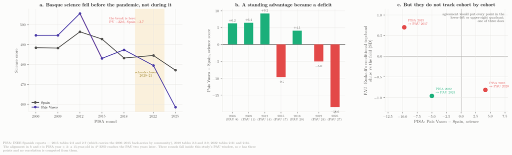

Figure 12: **a** — the science score of País Vasco and Spain across every PISA round from 2006 to 2025. The shaded band marks the school closures of 2020–21. **b** — the same series as a gap, with the PAU year each cohort reaches. **c** — the three cohorts matched to a PAU year inside this study’s window, with the PISA gap on the horizontal axis and the PAU conditional top-band measure on the vertical; agreement would place every point in the lower-left or upper-right quadrant.

The long series settles the question the two-round version could not, and it settles it against the reading offered here in an earlier draft. Across 2006, 2009 and 2012 the Basque science score ran **+6.2, +6.4 and +9.2 points above Spain**. Between 2012 and 2015 it fell **22.6 points** while Spain fell 3.7, and it has not recovered: $-9.7$ against Spain in 2015, $+4.1$ in 2018, $-5.0$ in 2022. Over the decade to 2022 the Basque fall is **26 points against Spain’s 12**.

The break is in the **2015 round** — administered five years before the schools closed. Sampling error matters for the rest of the series: the INEE tables give the Basque science mean a standard error of 2.4 (2012), 3.0 (2015), 4.2 (2018), 4.6 (2022) and 4.3 points (2025), Spain’s 1.6–2.1, so the 2012→2015 change in the gap ($-18.9$) is about four standard errors while the 2018→2022 move ($-9.1$) is within two standard errors and the 2015→2018 one ($+13.8$) is 2.4, so neither is the kind of step 2012→2015 was; the moves between them are; “$+4.1$ in 2018” and “$-5.0$ in 2022” are not distinguishable from each other. The break and the 2025 gap ($-18.6 \pm 4.7$) are real; the shape of the series between them is not resolved. An earlier version of this section read only 2018 and 2022, found the Basque top tail thin in 2022, and attributed it to the pandemic cohort. That was wrong, and wrong in a way that mattered: it was offered as a reason to *discount* the slow-drift reading, and the earlier rounds show the opposite. A standing Basque advantage in science became a deficit a decade ago, on an instrument marked outside the Basque system, and stayed one.

The top of the distribution tells the same story without a trend. The Basque share at proficiency levels 5–6 in science runs 3.25 % in 2015, 3.87 % in 2018 and 3.32 % in 2022, against Spanish figures of 4.98 %, 4.18 % and 4.92 %. There is no progressive thinning: 2015 is as low as 2022. What there is, is a level that has sat below Spain’s in all three rounds and below the OECD’s (7.47 % in 2022) in all of them.

**But the cohorts do not line up.** This is the second correction, and it undoes the triangulation this section originally claimed. Of the three PISA rounds that map onto a PAU year inside the study window, only one agrees with the PAU conditional measure:

| Cohort | PISA gap vs Spain | PAU conditional vs field |  |
| --- | --- | --- | --- |
| PISA 2015 → PAU 2017 | $-9.7$ | $+0.70$ SD | disagree |
| PISA 2018 → PAU 2020 | $+4.1$ | $-0.82$ SD | disagree |
| PISA 2022 → PAU 2024 | $-5.0$ | $-0.96$ SD | agree |

One of three is what chance produces. The 2022/2024 match, which this section was originally built around, is not evidence of a cohort mechanism; it is the one case out of three in which two noisy measures happened to point the same way.

What survives is worth more than what was lost, and it supports the drift reading rather than the event reading. There is a real, large and sustained deterioration in Basque science attainment beginning in 2015, visible to an external instrument, which the PAU Física series does not show — Euskadi’s Física mean sits near its own baseline through 2024. Two conclusions follow. The PAU is not a good detector of whatever PISA is measuring, which is unsurprising given that Física is sat by a self-selected quarter of the cohort. And the slow-drift version of H4, which the previous section could not find in the PAU data, is clearly present in the schooling that precedes it. Those are compatible: a decade-long weakening of the base need not show in a subject whose takers are drawn from the top of it.

### 6.1.4 Do the two instruments fall at the same rate?

The cohort test above compares single years and finds noise. A gentler question is whether the two series, taken whole, descend at the same rate — whether Figure 11’s panel a and Figure 12’s panel a are parallel. That is a better question than whether they correlate, which three overlapping points cannot answer, and it turns out to have a more interesting answer than the cohort test did.

It needs a common scale. Each series is divided by a student-level standard deviation: 2.343 marks for PAU Física, the median of the thirteen standard deviations published by the Comunitat Valenciana universities for 2025–2026 (the only community that publishes them) and consistent with the Beta fits of Chapter 4; about 90 points for PISA science, from Spain’s p10–p90 spread in the 2015 tables. A slope in standard deviations per decade is then the same quantity on both instruments. The PISA fit runs over the four rounds 2012–2022, the decade the PAU series covers; the 2025 round is held out because the section below uses it as the forward-looking measurement, and the fit that includes it is reported at the end.

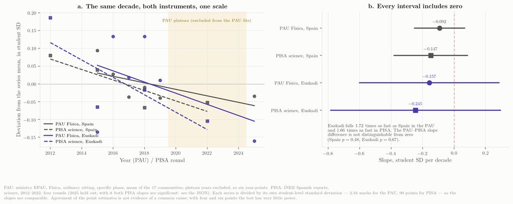

Figure 13: **a** — the PAU Física mean and the PISA science score for Spain and for Euskadi, each centred on its own mean and divided by its own student-level standard deviation, with the fitted trends. PAU plateau years are shaded and excluded from the PAU fits; the PISA fits run on the four rounds 2012–2022 and the 2025 round is held out. **b** — the four slopes with their 95 % intervals.

| Series | Slope, SD per decade | 95 % interval |
| --- | --- | --- |
| PAU Física, Spain | $-0.092$ | $[-0.251,\ +0.068]$ |
| PISA science, Spain | $-0.147$ | $[-0.381,\ +0.086]$ |
| PAU Física, Euskadi | $-0.157$ | $[-0.601,\ +0.286]$ |
| PISA science, Euskadi | $-0.245$ | $[-0.785,\ +0.296]$ |

The point estimates are strikingly consistent. All four decline; the PAU and PISA slopes for the same population differ by $+0.06$ and $+0.09$ SD per decade, differences that no test could distinguish from zero ($p = 0.48$ and $p = 0.67$). And the relative figure is closer still: **Euskadi falls 1.72 times as fast as Spain on the PAU and 1.66 times as fast on PISA**. Two instruments with nothing in common — different ages, different subjects, different markers, different scales — put the Basque disadvantage at the same multiple of the national one.

That is worth stating because it tempers a claim made in the previous section. There it was said that PISA shows a deterioration the PAU Física series does not. On *cohorts* that stands, and the matching is one of three. On *trend* it overstates: the PAU does decline, at a rate whose point estimate sits comfortably inside PISA’s interval, and the reason it looked absent is that the plateau hides it in the raw series and the six surviving year-points cannot make it significant.

The honest summary is the one panel b is drawn to make unavoidable: on this window **every interval includes zero**. With four PISA rounds and six usable PAU years, these data are consistent with two instruments measuring one common decline at the same rate — and equally consistent with no decline at all in either. The agreement of four point estimates, and of two ratios to within 4 %, is the kind of coincidence that is worth recording and is not worth believing on its own: the ratio is of two slopes whose own $p$-values are 0.19 and 0.38, and has no usable interval.

Two further things the audit added. First, adding the 2025 round changes the PISA half of the table: on 2012–2025 the Spanish PISA slope is $-0.155$ SD per decade $[-0.256,\ -0.054]$ ($p = 0.016$) and the Basque one $-0.327$ $[-0.603,\ -0.051]$ ($p = 0.033$), both significant on their own, and the Basque-to-Spanish ratio becomes 2.1 rather than 1.7 (`data/analysis/slope_compare.json`). Second, and more fundamental: the comparison is not well posed as a comparison of *rates*, because neither record is a slope. The Basque PISA series is a step in 2015 followed by noise and a second step in 2025; the Basque PAU series is a plateau followed by a step. A straight line through step changes measures where the steps fall in the window, not a common rate of decline. The right statement is the weaker one: both instruments show the Basque position relative to Spain deteriorating over the decade, in steps rather than steadily, and the PAU shows it only from 2025 and only in Física. It is a reason to keep measuring both, which is the recommendation of the next section, rather than a finding.

### 6.1.5 How much of the paper is reading?

**Disclosure**

The author of this study was involved in setting the 2026 Basque Física paper, and specifically chose to expand the statement of its second exercise — spelling out each requirement and repeating it — because a competency-style *saber básico* was entering the examined set for the first time. That account is the origin of the hypothesis tested in this section, and it is first-hand evidence no amount of text analysis could have supplied: it establishes that the length was deliberate rather than accidental. It also means this section examines a decision its author made. The author is the Física coordinator whose account Sixteen years of one paper reports in the third person; that chapter’s “testimony of the coordinator” is the author’s own. The provenance note in Methods records the same facts.

Every section so far has treated the paper as a single variable — harder or easier, more or less competency-oriented. It has another dimension that is objective, easy to measure and so far unexamined: how much text a candidate must read before answering. The competency reform pushes in exactly that direction, because contextualised items carry a scenario and the scenario has to be written down.

That matters more if the cohort’s reading has weakened, and the Basque cohort’s has, far more than its science. Over the decade to 2025 the País Vasco PISA reading score falls **72 points**, from 491.4 to 419.1, against a science fall of 24.5. The gap to Spain widens from $-4.1$ to $-32.2$. Whatever else is true of these students, reading is where they have lost most ground. (There is no 2018 point: the Spanish PISA 2018 report contains mathematics and science only, because the OECD withheld Spain’s 2018 reading results over anomalous response patterns.)

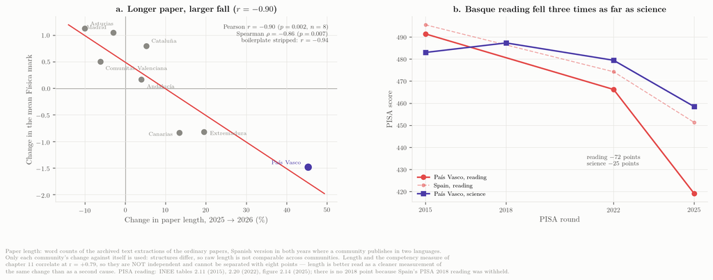

Figure 14: **a** — change in the length of each community’s ordinary Física paper between 2025 and 2026, in per cent, against the change in its mean mark, for the eight communities whose 2025 and 2026 papers can both be text-extracted (Castilla-La Mancha exists only as a transcript). Only each community’s change against itself is used, since structures differ. **b** — PISA reading and science for País Vasco, with Spain’s reading for comparison.

Three cautions, and the second is the one that matters.

The word count includes everything the candidate is given, and papers that offer more choice print more text for the same student workload. That is why only within-community change is used, and why the levels (Cataluña 1,628 words, Asturias 899) are not compared.

**Length and competency content are not independent.** The competency measure of The papers themselves correlates with the length change at $r = +0.79$ ($p = 0.02$, $n = 8$). Contextualised items are longer items, so the two are largely one signal seen twice, and with eight points they cannot be separated. What length adds is not a second cause but a better instrument: it is a count, reproducible by anyone with the PDFs, where the competency coding is a judgement made by one reader (a blind second coder agreed with it on every direction of change; Audit). On the same eight communities the competency-points measure gives $-0.64$ and the contextualised-points measure $-0.86$, so length leads it but not by much; length is worth preferring because it is a count anyone can reproduce from the PDFs, not because it is the stronger signal. Two cautions belong here as well: the hypothesis was suggested by the author’s knowledge of his own paper’s length, which makes length a variable chosen after the outcome was known, and with eight points the result should be read as exploratory however small its $p$-value.

And the interaction that motivated the section — long papers hurting weak readers more than strong ones — is not tested here. Testing it needs the reading level of each community crossed with its length change, and with eight communities an interaction term would be fitting noise. It remains a hypothesis, and a cheap one to settle: the 2027 paper could be set with its statement length recorded, and the Basque reading collapse means that number now carries more weight than it did.

### 6.1.6 What PISA 2025 says about PAU 2027

PISA 2025 was published on 8 September 2026, ten days before this chapter was first written, and science was its major domain. It is the cohort that sits the PAU in 2027, so for the first time in this study a genuinely forward-looking measurement exists, and it is worth asking what estimate it supports.

The measurement itself is severe. Basque science falls to **458.5**, against a Spanish **477.1** and an OECD **481.9**. The gap to Spain, which was $+9.2$ in 2012 and $-5.0$ in 2022, is now $-18.6 \pm 4.7$ — the largest in the series and nearly double the previous worst ($-9.7$ in 2015). At the top of the distribution the Basque share at levels 5–6 **falls by almost half, from 3.32 % to 1.83 %** (a change of about two standard errors), against a Spanish figure that eases from 4.9 % to 4.2 %. On the instrument that does not depend on Basque marking, the cohort now in 2º Bachillerato, which sits the PAU in 2027, is the weakest this series has recorded.

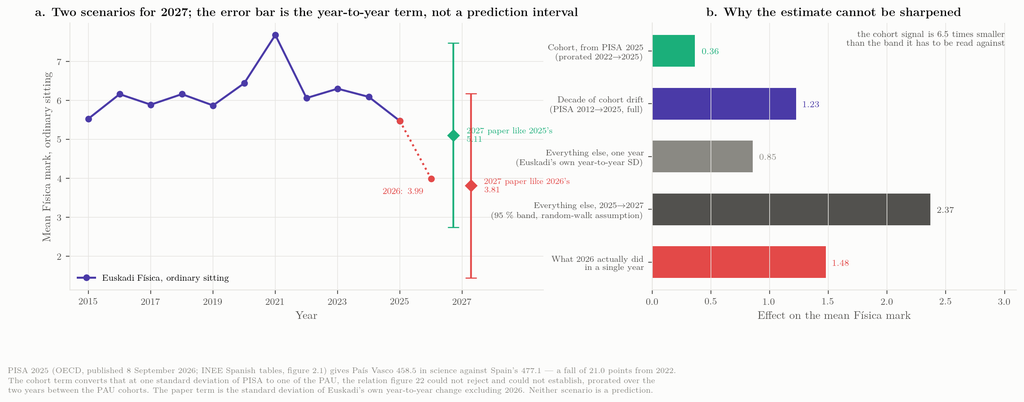

Figure 15: **a** — the Euskadi Física series with two scenarios for 2027. The error bar on each is the year-to-year term — everything except the PISA-measured cohort change — not a confidence interval on a prediction. **b** — the one estimated cohort term set against the year-to-year dispersion it has to be read through, and against what 2026 actually did, all on the same scale.

Converting that into a PAU estimate is arithmetic, and the arithmetic is what makes the answer honest. The Basque PISA fall of 21.0 points is $0.233$ of a student standard deviation; transferred one-for-one to the PAU — the relation figure 22 could neither reject nor establish — and prorated over the two years separating the PAU 2025 and PAU 2027 cohorts, it is a **cohort term of $-0.36$ marks** (about $\pm 0.11$ from PISA’s sampling error alone); measured from the 2026 cohort, one year closer, the same move gives $-0.18$.

Set that against what else moves the number. The standard deviation of Euskadi’s own year-to-year change in the Física mean, excluding 2026, is **0.855 marks** (0.72 without the COVID transitions); over two years, treating the changes as independent, the 95 % band on that alone is **$\pm 2.37$**. That term is not “the paper”: it is everything the PISA cohort measure does not capture — paper, marking, sitting composition and cohort noise together — and the random-walk assumption behind the two-year band overstates it for a series that visibly reverts to its mean. Even so, the cohort term is **6.5 times smaller than the band it has to be read against**. And 2026 itself moved the mean by $-1.48$ in a single year on a changed paper — four times the cohort term, and more than the whole decade of PISA drift converted the same way ($1.23$ marks from 2012 to 2025).

So the estimate exists and is this:

| If the 2027 paper resembles | Cohort term | Central estimate | 95 % band from the year-to-year term alone |
| --- | --- | --- | --- |
| the 2025 paper | $-0.36$ | **5.11** | $[2.74,\ 7.48]$ |
| the 2026 paper | $-0.18$ | **3.81** | $[1.44,\ 6.18]$ |

The two scenarios differ by 1.3 marks, most of the size of the 2026 event; the cohort contributes a third of a mark or less to either. That is the finding, and it is not the one the question was hoping for. **PAU 2027 is not something PISA predicts. It is something the 2027 paper and its marking scheme decide**, with the cohort supplying a slow downward nudge three and a half to seven times smaller than the choice. A forecast whose interval spans 2.7 to 7.5 is not a forecast; it is a restatement that the exam is the dominant variable.

Two things follow that are worth acting on rather than reading. The cohort term, small as it is, points the same way as every other measure in this section, so the sensible default for 2027 is that the intake will be slightly weaker than 2025’s and considerably weaker than the decade’s average — which argues for the paper being set with that in mind rather than against a remembered cohort. And the honest use of PISA 2025 here is not prediction but *attribution after the fact*: when the 2027 result arrives, the $-0.36$ is the part that should not be blamed on the paper, and everything beyond it is the part that should be explained.

**H5 — “Física is sat last, and the admission arithmetic makes the last slot dispensable for the candidates most able to abandon it.”** *Not a 2026 trigger; the first candidate mechanism the 2024 shape change has ever had, and the only hypothesis in this list that predicts a band signature rather than a level.* This began as the Canarian coordinators’ account of their own decline — few degrees require a high Física mark, Matemáticas II carries the weighting, Física is examined last on a long day — and in that form it was filed as slow background. Restated in terms of the admission arithmetic it is sharper, and it makes a prediction the other hypotheses do not. The full treatment, including the test that fails and the test that does not, is in the section below. In summary: the within-sequence position test is **contradicted** by the 2026 subject changes, and Física’s own slot did not move between the two years, so position is excluded as a cause of the $-1.48$. Three things survive. The 2025 and 2026 calendars are *not* the same — Matemáticas II moved from the morning to the afternoon and became the paper immediately preceding Física, so that for the first time the two heaviest quantitative papers were sat back to back, which partitions the four subjects correctly and is confounded beyond separation. Fatigue survives as a *multiplier* on reading load. And the effort-allocation mechanism predicts a signature — losses concentrated at the top, pass rate held or improved, mean almost still — that is the 2024 signature exactly.

**H6 — “Language or network bias.”** *No evidence either way for Física.* The 2010–2022 series shows euskera/castellano differences of a few tenths in both directions and no sign that either network fails Física differentially; EHU’s 2026 bias analysis was run for Euskara II. Nothing published for Física 2026 speaks to this.

The ranking that emerges is **H1b and H2 together at the front**, not separable from one another on published aggregates because they are two descriptions of the same paper; H1c plausible behind them and equally unseparable; H3 unresolved and testable; H5 no longer background but the leading candidate for 2024 specifically, and separable from the rest because it predicts a shape and they predict a level; H1a a national 2025 coincidence that cannot be separated from the end of the COVID-era plateau and says nothing about 2026; H4 unsupported as a Basque-specific cohort effect in the PAU (though the PISA level decline is real); and H6 unsupported. The change from an earlier version of this ranking is H1b: splitting the competency hypothesis into the national frame and the Basque implementation moves half of it from the back of the list to the front, because the objection that sank it — everyone had the model — applies only to the frame.

### 6.1.7 Fatigue, and the arithmetic of the last slot

#### 6.1.7.1 The position test, which fails

If position in the sequence produced the 2026 fall, the damage should increase along the sequence. The eight Basque subject changes say otherwise:

Table 16: The within-sequence ordering the fatigue hypothesis predicts, against the observed changes.

[output not shown]

#### 6.1.7.2 Why position fails, and where fatigue could still enter

The structural reason a position effect cannot produce a change is that position is a constant. Whatever being sat last costs a candidate, it costs the same every year, and it differences out of the $-1.48$ exactly as a national shock differences out of the field comparison in the decomposition. A fatigue argument therefore has to point at something that *moved* between the two sittings.

An earlier version of this section asserted that nothing had, and that assertion was made without checking. The two calendars have since been compared, and they are not the same.

Table 17: The ordinary-sitting timetable, 2025 against 2026. Sources: the UPV/EHU *Horarios* page and exam-days grid for 2026; the 25/26 access guide and the published press timetable for 2025, which disagree on the day of Biología and Física and agree on everything else.

|  | 2025 (3–5 June) | 2026 (2–4 June) |
| --- | --- | --- |
| Química | Tue 14:30–16:00 | Tue 16:45–18:15 |
| Biología | 14:30–16:00 | Tue 14:30–16:00 |
| Matemáticas II | Wed **11:15–12:45** | Wed **14:30–16:00** |
| Física | 16:30–18:00, last slot of its day | Wed 16:45–18:15, last slot of its day |

Four readings follow, and only the last of them survives.

**Matemáticas II moved out of the morning into the afternoon**, 11:15 to 14:30. It is the largest change of position in the set and it belongs to the subject with the largest fall, $-1.67$. That is one observation and it is not independent of the rest of what happened to that paper.

**Química moved later in the day**, 14:30 to 16:45, and fell $-0.21$ — the smallest fall of the three quantitative subjects. A simple “later is worse” rule is contradicted here as plainly as the sequence ordering contradicted it above.

**Física’s own slot did not move.** It sat in the final slot of its day in both years. The part of fatigue that is attributable to Física being last therefore still differences out, and cannot explain the $-1.48$.

**What changed for Física is what precedes it.** In 2026 the paper immediately before it — same day, same candidates, forty-five minutes between them — is **Matemáticas II**. In 2025 it was Biología. For the first time in this sitting the two heaviest quantitative papers were sat back to back in the final two slots of a single day. That is a change and not a level, which is what the hypothesis needed, and it partitions the four subjects correctly: the pair made adjacent fell ($-1.67$, $-1.48$), the pair moved to the other day did not ($-0.21$, $+0.15$).

It is recorded here and it enters no budget, for a reason that should be stated rather than buried. The contrast has two observations on each side and is completely confounded. The pair that was made adjacent is also the pair that is most quantitative, shares the most candidates, and whose own instruments changed most; “adjacent” and “hardest” name the same two papers, and no published aggregate separates them. What the comparison establishes is that the delivery of the examination changed in a way consistent with the observed partition — which is a fact about the 2027 calendar decision, not a term in the attribution of 2026.

One point remains open. The two sources for 2025 disagree on whether Biología and Física were sat on the Wednesday, directly after a morning Matemáticas II, or on the Thursday, a day later. The provisional grid printed in the 25/26 access guide says Thursday; the timetable published shortly before the sitting says Wednesday. The difference does not change the direction of any statement above — Matemáticas II moved from morning to afternoon and became adjacent to Física in either case — but it does change the size of the change, and it is marked open until the coordination confirms it.

#### 6.1.7.3 What survives: fatigue as a multiplier

Fatigue does not act alone. It multiplies whatever the paper asks, and what the 2026 paper asked changed sharply: the statement grew from 1 026 words to 1 431, a rise of 39 per cent (the reading load). The 45 per cent quoted elsewhere in this dossier is the same paper on the cross-community word-token count, 1 335 to 1 940, which includes the rubric and the fixed elements; the two counts are both right and must not be crossed, and this sentence previously crossed them, pairing the one percentage with the other’s absolute. A given increase in reading costs more in the fourth slot of the week than the same increase would cost in the first, because reading stamina is precisely what has been depleted. That is an interaction term, fatigue $\times$ load, and it requires no timetable change to be true. Its consequence is for 2027 rather than for the attribution of 2026: **the statement budget is worth more than its face value, because the words it removes are the most expensive words in the week.**

#### 6.1.7.4 Effort allocation, and why the return on Física is a step function

The second mechanism is not about tiredness. A candidate who sits Física only to raise the weighted admission mark, and who has already performed well in the papers sat earlier in the week, faces a return on further effort that is not merely diminishing. Under the admission arithmetic the *best two* weighted subjects of the fase de admisión enter the score. A candidate whose best two are already settled before Física gets, from anything Física can add, **exactly zero**. The function is a step, not a slope, and it is evaluated last, when the candidate has enough information to know approximately which side of it they are on.

This is what makes the hypothesis testable, because it says *who* stops. Not the weak candidate: the weak candidate needs every mark and cannot afford to coast. The candidate who can afford to stop is the strong one. The mechanism therefore predicts losses concentrated in the top band, a pass rate held or improved, and a mean that barely moves.

That is the 2024 signature, term for term:

Table 18: The 2024 Basque Física distribution against what its own change of level predicts. Source: the 2024 turn.

|  | observed | expected from the mean move | excess |
| --- | --- | --- | --- |
| 8–10 band | $-9.0$ pp | $-3.1$ | $\mathbf{-5.9}$ |
| pass rate | $+2.3$ pp | $-2.8$ | $\mathbf{+5.0}$ |
| mean | $-0.21$ |  |  |

Fewer at the top, more just above the line, the level almost still — on a paper of the old format, with the old choice rule and the old theory list, in which *nothing in the instrument moved*. 2024 is the one event in this study that has carried no mechanism at all. This is the first candidate it has had.

It is not yet an explanation, and the reason is the same one that disposed of simple fatigue. Effort allocation is also a level effect unless the incentive changed. To attach it to 2024 something must have moved in 2024 — cut-offs rising in the degrees that weight Física, a change in which subjects weight and by how much, or cohort growth tightening the competition. All three are public and none has been checked here.

#### 6.1.7.5 The weighting table, and the bound it already gives

The admission rule is not inferred here; it is printed at the head of every page of the UPV/EHU weighting table: **“Se utilizarán las 2 calificaciones que sean más favorables para el estudiantado”**. Two marks enter, and only two, whatever else the candidate sits.

Thirty-seven degrees in the three branches a Física candidate plausibly targets have been coded from the published table (`data/analysis/ponderaciones_ehu_2026.csv`). Física weights 0.2 in 28 of them, 0.1 in eight, and nothing in one. That looks like a subject in demand, and read against the best-two rule it is the opposite.

Table 19: Weighting of the four quantitative subjects across the degrees a Física candidate targets. Source: UPV/EHU, *Parámetros de ponderación curso 2026-2027 y siguientes*.

|  | Física | Matemáticas II | Química | Biología |
| --- | --- | --- | --- | --- |
| Ciencias (9 degrees) | 0.2 in 6 | 0.2 in 7 | 0.2 in 8 | 0.2 in 5 |
| Ingeniería y Arquitectura (22) | 0.2 in **22** | 0.2 in 21 | 0.2 in 15 | — |
| Ciencias de la Salud (6) | **0.1 in 5, none in 1** | none | 0.2 in **6** | 0.2 in **6** |

Three consequences follow, and none of them needs a simulation.

**Física is almost never the scarce subject.** Of the 28 degrees that weight it at 0.2, 26 also weight Matemáticas II at 0.2 and **19 weight Física, Matemáticas II and Química all three at 0.2**. In twenty of the twenty-eight the candidate has at least two *other* 0.2 subjects available. Física is therefore not a key that opens a door; it is one of three interchangeable keys of which two are used.

**The first of the two slots is already filled before the candidate chooses anything.** Matemáticas II is the compulsory modality subject of the access phase for Ciencias y Tecnología, and an access-phase mark may be carried into the admission phase. Every science candidate consequently holds one 0.2 mark before sitting a single elective. The contest is for the *second* slot, and in the engineering degrees that second slot is contested between Química and Física.

**Química is sat first.** On the 2026 calendar Química is the last slot of Tuesday and Física the last slot of Wednesday (the timetable). A candidate walks into the Física room having already sat the subject that competes with it for the only remaining weighted slot, and with an approximate idea of how it went. That is the informational precondition the mechanism requires, and the calendar supplies it.

The health-sciences row is the sharpest case and it points the same way. For Medicina, Enfermería, Fisioterapia, Farmacia and Odontología, **Biología and Química weight 0.2 and Física weights 0.1**. A medicine-bound candidate who sits all three cannot bring Física into the best two unless it beats a 0.2 subject by a factor of two in contribution — which in practice it cannot. For that group the marginal return on Física is not small; it is structurally zero. And that group is drawn from the top of the distribution, which is precisely where the 2024 losses were.

#### 6.1.7.6 What the simulation adds

What the table cannot give is *how many* candidates are actually in that position, because that depends on their marks. Given the three weights above and a joint distribution of candidates’ marks in the competing subjects — which the published subject distributions supply — one may compute the fraction whose best two are settled before Física is sat.

The result is **a bound, not a measurement**: it is the largest the effect can be, not its size. A first-order sense of the magnitude comes free. Where Física, Matemáticas II and Química all weight 0.2 and the three marks are treated as exchangeable, Física falls outside the best two about one time in three. That is the order of the ceiling, not an estimate of what candidates did. No published aggregate records effort, and none will.

## 6.2 Was 2026 a shift or a change of shape?

The hypotheses above divide along a line the published aggregates can be made to test. A harder paper or a uniformly stricter marking scheme moves the whole distribution down together. A change in who sits the exam, or a marking change that bites only at the bottom, changes its *shape* — it thins the pass region without touching the top, or the reverse. The published data carry three summaries of the same distribution — the mean, the pass rate, and the share in the 8–10 band — and the second and third are near-deterministic functions of the first: across seventeen communities and eleven years the correlations are $r = 0.974$ and $r = 0.961$. A scatter of pass rate against mean therefore mostly redraws arithmetic. What carries information is the *residual*: a cohort sitting off the common locus has a differently shaped distribution, not merely a lower one.

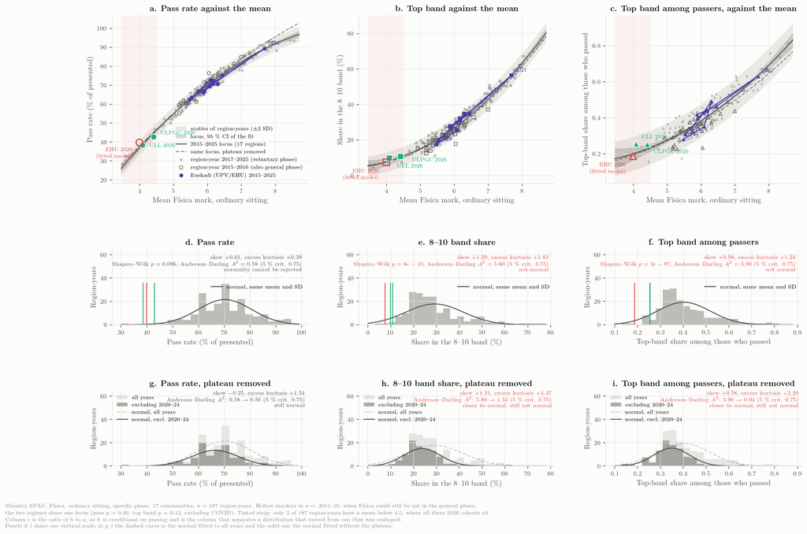

Figure 16: **a, b** — Pass rate and the 8–10 band share against the mean Física mark, ordinary sitting, specific phase, seventeen communities 2015–2025 (n = 187 region-years, Ministry EPAU). The solid line is a quadratic fit; the pale band is ±2 residual standard deviations (1.9 pp left, 2.7 pp right) and the darker band the 95 % confidence interval of the fit itself, which widens where the region-years thin out. The dashed line is the same locus refitted with the 2020–2024 plateau removed: it departs from the solid one in the middle and upper range, where the plateau years sit, and converges on it at the low end, so the 2026 readings do not depend on the plateau. Hollow grey markers are 2015–16, the years in which Física could still be sat in the general phase; from 2017 LOMCE left it in the voluntary phase only and the presented cohort grew from 37,661 to 49,010 (pooled across phases). The Euskadi trajectory is drawn as a connected path. ULL and ULPGC 2026 are observed histograms, on a denominator of exams sat rather than presented. The EHU 2026 marker is hollow because its band share is a Beta fitted to the published mean, pass rate and zero count, so on these axes it can only restate them. The tinted strip marks the part of the mean axis where only two of the 187 region-years lie, and where all three 2026 cohorts sit. **c** — the ratio of b to a, $P(x \ge 8 \mid x \ge 5)$: the share of those who passed who reached the top band. Because it is conditional on passing it carries far less of the level than either component, tracking the mean at $r = 0.905$ against $0.974$ and $0.961$, and it is therefore the column that can separate a distribution that moved from one that was reshaped. **d, e, f** — the distribution of each column’s own vertical variable, with a normal of the same mean and standard deviation drawn for comparison and the 2026 values marked as vertical rules. These are deliberately not the distribution of the mean, which is the same variable on all three horizontal axes. **g, h, i** — the same three distributions with the 2020–2024 plateau removed, drawn over the full sample in pale grey; the dashed curve is the normal fitted to all years and the solid one the normal fitted without the plateau. Panels d–i share one vertical scale, which is why the bars in g–i are lower: 85 of the 187 region-years have been removed, and a density normalisation would have hidden that.

Two things follow, and the first is a precondition for the second.

**The locus is a property of the marking scale, not of the cohort.** Física’s examined population changed substantially inside this window: until 2016 it could be taken in the general phase, from 2017 LOMCE left it voluntary only, and the number presented grew by 30 % — from 37,661 to 49,010, pooled across phases. If the mapping from mean to pass rate depended on who sits the paper, it should step at that boundary. It does not: comparing residuals before and after 2017, the pass panel gives $p = 0.40$ and the top-band panel $p = 0.12$ once the two COVID sittings are excluded. On the full series the top-band difference does reach $p = 0.008$, but that result is carried by 2020, whose year-mean residual of $+3.6$ pp is the largest of the eleven, and it is the COVID year — so the honest reading is the conservative one. In Figure 16 the hollow 2015–16 markers interleave with the later ones along the same curve. That stability is what licenses reading a 2026 point off the locus at all.

**Where 2026 can be observed, it is a location shift — but the test is weaker than it looks.** The only 2026 cohorts with a published histogram are the two Canarian universities, and both land on the locus: ULL at $-0.08$ SD on the pass panel and $+0.65$ SD on the top band, ULPGC at $-1.04$ and $+0.24$, against a historical scatter that runs from $-2.6$ to $+3.0$ SD on the pass panel and $-3.5$ to $+2.6$ on the top band. Their distributions are the same shape as everyone else’s at that mean — simply further down it. Nothing was thinned selectively: the top of the Canarian cohort fell with the rest.

How much that settles depends on how much evidence sits where these cohorts fall, and the answer is honestly very little. The 187 region-year means pile up between 5.0 and 6.5 — they are themselves right-skewed and heavy-tailed rather than normal (skew $+0.60$, excess kurtosis $+0.88$; Shapiro–Wilk $p = 0.00017$, Anderson–Darling $A^2 = 2.06$ against a 5 % critical value of $0.75$). Only **2 of 187** sit below 4.5 — the tinted strip in all three upper panels of Figure 16 — and none within $\pm 0.25$ of where ULL (4.08) and the Basque cohort (3.99) fall. The curve there is therefore an extrapolation from the body of the data, and the pass panel’s own 95 % interval is $\pm 1.41$ pp at mean 4.08 against $\pm 0.32$ pp at mean 6.0 (on the 8–10 panel, $\pm 2.04$ and $\pm 0.46$), which is why the figure draws that interval as well as the flat scatter band. ULL’s residual of $-0.16$ pp sits comfortably inside the uncertainty of the very curve it is measured against.

The columns are also not equally well-behaved, and panels d, e and f of Figure 16 separate them because they give different answers. The pass rate is symmetric and close to normal (skew $+0.01$, excess kurtosis $+0.39$; Shapiro–Wilk $p = 0.096$, Anderson–Darling $A^2 = 0.58$, below the critical value — normality cannot be rejected). The 8–10 share is not (skew $+1.29$, $A^2 = 5.80$), and neither is the conditional ratio (skew $+0.98$, $A^2 = 3.90$). Right-skew is what one should expect of a tail quantity pressed against zero, but it has a practical consequence: a residual quoted “in standard deviations” assumes roughly symmetric scatter, so the SD units are trustworthy on the pass panel and only indicative on the other two. Those residuals should be read as directional, not as calibrated probabilities.

The third column settles the question the first two could not. A uniform shift of the whole distribution moves the pass rate and the 8–10 share together, so a cohort sitting on both loci is consistent with a shift but does not demonstrate one — the two measurements are not independent tests. The conditional ratio is the quantity that distinguishes them, and on it the two observed 2026 cohorts sit *above* the locus, not below: ULL at $+1.05$ SD and ULPGC at $+0.53$ SD. Among the students who passed in Canarias in 2026, the top band is if anything slightly better represented than their mean predicts. Whatever happened there did not thin the top of the cohort relative to its middle, which is the first measurement in this sequence to strengthen a conclusion rather than qualify it.

The consequence is a limit on power, not a reversal of sign. Nothing in the 2026 data indicates a change of shape, and a *large* one would still have shown: a cohort that had thinned only at the bottom would sit several points off the curve, far outside even the widened interval. But a modest reshaping at mean 4 could not be detected with two historical neighbours, so “consistent with a pure location shift” is the correct reading, and “demonstrated to be one” is not.

That bears on the ranking above in one direction and one only. It is evidence against **H4**: a cohort that had become differently composed would be expected to sit off the locus, and Canarias does not. It does not discriminate between **H2** and **H3**, because a harder paper and a uniformly severer marking scheme produce the same signature here — both move the distribution without reshaping it. What it weighs against is any mechanism acting *strongly* and selectively on one part of the range.

The Basque case cannot be put to this test with what is published. The 2026 band shares shown in Chapter 4 are output of the Beta fitted to the mean, the pass rate and the zero count; plotting them here as evidence would be circular, which is why the EHU 2026 marker in Figure 16 is drawn hollow. Its apparent residual of $-0.05$ SD on the top band is the model agreeing with itself and should not be read as a result. Resolving the Basque case the same way needs one thing: the observed 2026 grade histogram, which is item 3 of the data requests below.

One data caveat surfaced in building this. The Ministry’s own cube is internally inconsistent for two of the 187 region-years — Galicia 2015 and 2016 — where the published pass rate and the published $[0,5)$ share disagree by 5.64 and 4.48 pp; these are the two years in which Física appeared in both phases, so the cells are carried on different bases. Every band row sums to 100.0 and the remaining 185 agree to rounding, so the two points are kept rather than discarded, and they are recorded in `data/analysis/shape_locus.json`.

## 6.3 What you compare against decides what you find

Every number in this report is a change measured from some reference point, and the reference point is almost never argued for. It is usually the previous year, because that is what the sources publish and what the press quotes. Reading the same series against a different baseline does not merely adjust the size of the effect — in this case it reverses the sign of the national story.

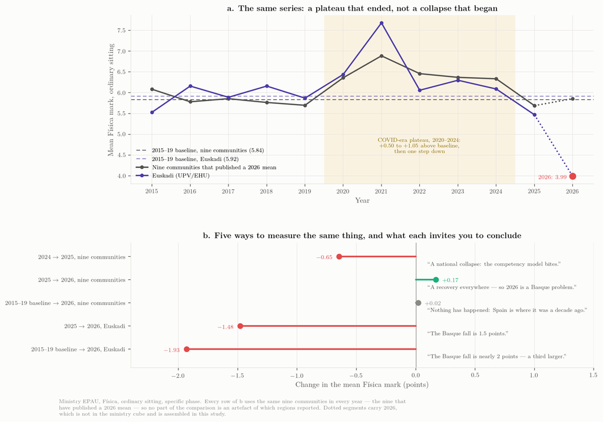

Figure 17: **a** — mean Física mark, ordinary sitting, for the nine communities that have published a 2026 result (the same nine in every year, so nothing here depends on which regions reported) and for Euskadi separately, against their own 2015–2019 baselines. The shaded years are the COVID-era plateau. Dotted segments carry 2026, which is not in the ministry cube and is assembled in this study. **b** — the same underlying data measured five ways, with the conclusion each measurement invites.

The pattern in panel a of Figure 17 is not a decline. It is a plateau that ended. The nine communities sit $+0.50$ to $+1.05$ above their pre-COVID baseline in every year from 2020 to 2024, peaking in 2021, and then return to it in 2025. The relaxation did not decay gradually, which is what “returning to normal” would look like; it held for three full years after the peak — 2022, 2023 and 2024 are $+0.62$, $+0.53$ and $+0.50$ — and then ended in a single step. Whatever produced the COVID-era regime was still producing it in 2024, and stopped in 2025.

It was not a Física phenomenon either. Run on every subject in the Ministry cube (seventeen communities, each subject against its own 2015–2019 norm; `data/audit/plateau_by_subject.csv`), the plateau is present everywhere — Matemáticas II $+0.48$ to $+0.97$, Química $+0.58$ to $+0.94$, Biología $+0.17$ to $+0.55$, Historia $+0.29$ to $+0.75$, Lengua $+0.23$ to $+0.47$ — and in 2025 every science subject returned to within about a fifth of a point of its norm (Física $-0.06$, Matemáticas II $+0.11$, Química $+0.20$, Biología $-0.21$), while Historia kept most of its lift ($+0.53$). The 2025 fall was the simultaneous end of a subject-general regime.

Was it a uniform lift? The conditional measure of Figure 16 was first read as saying no: among students who passed, the share reaching the 8–10 band ran $0.353$ across 2015–2019, rose to $0.466$ through the plateau and came back to $0.331$ in 2025, and an earlier version of this section called that a reshaping ($p = 4 \times 10^{-11}$). The audit withdrew it. The conditional ratio tracks the mean at $r = 0.905$, so most of that rise is what the level alone produces: the locus predicts $0.356$ at the pre-COVID mean of 5.77 and $0.442$ at the plateau mean of 6.44, about 0.09 of the observed 0.11. Measured on the locus residual, the plateau’s excess is $+0.02$ (about half a residual SD), $p = 0.17$ on the five-against-five year means, and it is carried by 2020 alone (residual $+0.06$; 2021–2024 are within $\pm 0.02$). To the precision these data allow, the plateau lifted the distribution and did not reshape it. Panels h and i of Figure 16 still show that the conditional ratio’s departure from normality is largely an artefact of those five years (Anderson–Darling $3.90 \to 0.94$ without them), where the raw 8–10 share stays non-normal at $1.53$ because its skew is intrinsic.

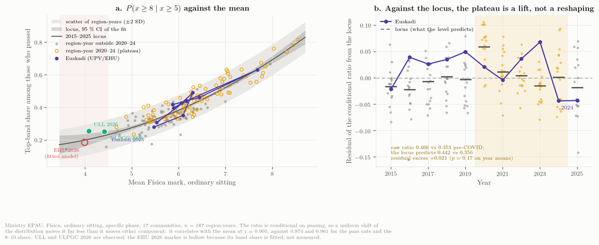

Figure 18: **a** — the conditional top-band share $P(x \ge 8 \mid x \ge 5)$ against the mean, with the Euskadi path, the two observed 2026 Canarian cohorts and the fitted EHU 2026 value, drawn hollow because its band share is modelled rather than measured. **b** — the residual of that ratio from the locus, by year, with Euskadi’s own path drawn over the panel: the plateau years carry an excess of $+0.02$ over the rest of the panel, carried by 2020, which is what a lift of the level — not a reshaping — leaves behind. Euskadi’s own residual is positive in most years to 2023 and then drops by three standard deviations in 2024, which is the step the decomposition takes up.

That is enough to change the reading of three separate claims in this report.

| Measured as | Change | Invites the conclusion |
| --- | --- | --- |
| 2024 → 2025, nine communities | $-0.65$ | “A national collapse; the competency model bites.” |
| 2025 → 2026, nine communities | $+0.17$ | “A recovery everywhere, so 2026 is a Basque problem.” |
| 2015–19 baseline → 2026, nine communities | $+0.02$ | “Nothing has happened; Spain is where it was a decade ago.” |
| 2025 → 2026, Euskadi | $-1.48$ | “The Basque fall is one and a half points.” |
| 2015–19 baseline → 2026, Euskadi | $-1.93$ | “The Basque fall is nearly two points — a third larger.” |

Rows one and three are the uncomfortable pair — and row three hides a dispersion that is the real 2026 story: against their own pre-COVID baselines, Madrid ($+1.02$), Castilla-La Mancha ($+0.86$), Cataluña ($+0.63$), Andalucía and Asturias ($+0.48$) and Valencia ($+0.34$) sit above their norm in 2026, Extremadura ($-0.78$), Canarias ($-0.86$) and País Vasco ($-1.91$) below it (`data/audit/baseline_2026_by_community.csv`). “Spain is where it was” is an average of communities a point apart in both directions. Both are true of the same nine communities and the same ministry series, and they are not reconcilable as statements of fact about “what happened to Physics in Spain”: one says the subject collapsed, the other that it is exactly where it was in 2015–2019, $+0.02$ away after eleven years. The contradiction is entirely in the choice of reference year, and the year-on-year framing is the one that misleads, because 2024 was not a normal year to measure from.

This weakens **H1a** further than the hypothesis review above already did, though not as far as an earlier version of this section claimed. That section could say only that the competency model explains 2025 and not 2026. Measured from the pre-COVID baseline, the 2025 sitting did not fall below the historical norm, it returned to it — in every subject at once. A model introduced in 2025 that leaves the national Física mean 0.15 below where it sat in 2015–2019 is not doing anything visible to the *level*. What the frame cannot decide is why the plateau ended in 2025 rather than in 2023 or 2024: the withdrawal of a COVID-era regime and the first LOMLOE papers, with their new marking instructions in every subject, arrive in the same year, and nothing in the PAU series separates them. The honest form of H1a is therefore: the reform, as a national frame, coincides with the end of a subject-general plateau and cannot be told apart from it; it does not explain the 2026 Basque result, which is the one this study is about. None of this touches H1b, which is about what one community did with the frame and not about the frame.

It also makes the Basque case worse, not better. The headline everyone quoted is $-1.48$, measured from 2025. Against Euskadi’s own pre-COVID baseline of 5.92 the 2026 fall is $-1.93$ — a third larger than the number in circulation — because 2025 was already 0.45 below that baseline. The Basque series did not fall once; it fell twice, and only the second fall was reported as news.

None of this is a criticism of the sources. The Ministry publishes years, the universities publish years, and a year-on-year change is the only comparison most readers can make from what is published. But it means the honest form of every claim in this report carries its reference point on its face, and that the three sentences most likely to be quoted from this study — “the 2025 fall was national”, “the 2026 fall is regional”, “Euskadi fell 1.48” — are each true only in the frame that produced them.

### 6.3.1 Why measure a Basque fall against a Spanish field at all?

The objection is a fair one and it should be answered before the decomposition uses the field. The question this study asks is what happened in Euskadi. Euskadi’s mean is published. Why introduce eight other communities, each with its own exam, into the measurement of a Basque event?

Three frames give three numbers, and the first thing to say is how little they differ.

Table 20: The same Basque 2026 result in three frames. The middle row takes the Basque pre-COVID norm as 5.900, the convention used by the mark budget so that Euskadi and the field are computed on the same series; the specific-phase convention of 5.922 used in the frames section above gives $-1.93$, and EHU’s own published series $-1.92$.

| Frame | What it asks | 2026 |
| --- | --- | --- |
| Year on year | how far did the Basque mean fall from 2025? | $-1.48$ |
| Against Euskadi’s own 2015–2019 norm | how far is 2026 from where Euskadi normally sits? | $-1.91$ |
| Against the nine-community field | how much of the fall is Euskadi’s own, once the country’s move is taken out? | $-1.65$ |

They span 0.43 of a mark around a fall of roughly a point and a half. No conclusion in this study turns on which is used, and the design implications in the last section of this chapter are identical under all three. Anyone who prefers to read the whole thing with $-1.48$ in mind, or with $-1.91$, will not be misled.

What the field buys is not size but *separation*, and it buys it for one specific purpose that no absolute number can serve: telling a year in which everyone fell from a year in which only Euskadi did. 2025 is the case that makes the point. Read absolutely, Euskadi lost 0.62 marks in 2025 and that looks like a Basque problem worth a working group. Read against the field, which lost 0.65 in the same sitting, there is nothing Basque in 2025 at all — and the whole of the anomaly sits in 2026, where the field gained 0.17. Without the field those two years look like one slide of 2.10 marks over two sittings. With it, they are one national event followed by one Basque event, and only the second is the coordination’s to answer.

What the field is *not* is a control group, and it is important not to let the arithmetic imply otherwise. A control requires that the comparison units differ from the treated unit only in the treatment. These nine sat nine different papers, marked to nine different criteria, by nine different sets of correctors. Chapter 11 measures how different, and the answer is: very. Euskadi is the only community that moved all four of those axes in the direction the orientations ask for: optionality 75 % → 50 %, competency-coded marks 25 % → 62.5 %, and substantive context and contextualised marks up 50 and 75 points. Castilla-La Mancha is the only other that both cut optionality and raised its competency share, and it cut contextualised marks by 45 points at the same time; Cataluña moved the competency share 37.5 points the other way; three communities moved on no axis but the contextualised share. Across the nine, the further a paper moved toward the competency model the further its mean fell — $r = -0.70$, $p = 0.035$, though Euskadi is the extreme point on both axes and dropping it leaves $r = -0.40$, $p = 0.33$ among the other eight, so that coefficient is largely one community making its own point rather than eight communities agreeing.

The practical consequence is a range rather than a number. Measured against all eight other communities the Basque-specific component is $-1.65$ on the pooled ministry basis and $-1.85$ on the published-means basis; measured against only the six whose papers barely moved it is $-1.95$. Measured against nothing at all it is $-1.48$. The Basque-specific fall is somewhere in $[-1.95, -1.48]$, and the reason it cannot be narrowed is that nobody has calibrated these nine papers against each other. That is request 9 below, and it is the request that would turn a comparison into a control.

One further thing follows for how this chapter’s headline should be quoted. If the other communities’ 2026 rises came partly from keeping papers their own candidates found easier — which is what the reform-intensity association is consistent with and does not establish — then the field’s $+0.17$ is not an estimate of what Basque candidates would have scored on an unchanged exam, and the $-1.65$ overstates the part of the fall that is specifically Basque *ability or marking* while understating the part that is specifically the Basque *paper*. Both readings are in the decomposition that follows, which is why it reports the field term separately rather than folding it in.

## 6.4 How this reading was arrived at, and what it cost each earlier one

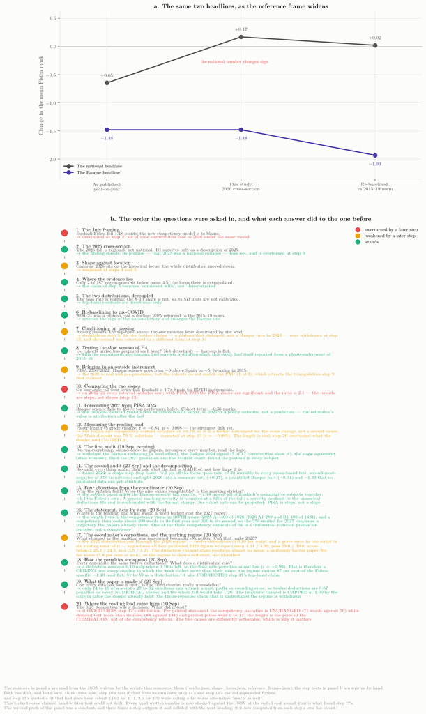

Figure 19: **a** — the two headline quantities under three successive framings; the national quantity is computed on the same nine communities in every frame, the Basque one on Euskadi alone. The national number does not merely shrink as the frame widens; it changes sign. **b** — the order the questions were asked in, the claim each step produced, and what the later steps did to it. The numbers are read from the JSON written by the scripts that computed them; the step descriptions are written by hand, which is how step 10’s text drifted from its own data until the audit caught it.

The sequence in panel b of Figure 19 ran as follows.

**Step 1** was the July framing, taken from the institutions: Física fell 1.48 points and the competency model is to blame. **Step 2**, the cross-section of 2026 in Chapter 3, overturned it — six of nine communities rose in 2026 under the same model, and a national cause cannot produce opposite signs in the same year. That is the step that produced this chapter’s original hypothesis ranking.

**Step 3** asked whether the 2026 fall was a change of shape or of position, and answered that Canarias 2026 sits on the historical locus: the distribution moved down without being reshaped. **Step 4** then asked how much evidence supports the locus where those cohorts fall, and found almost none — two region-years of 187 below mean 4.5, and a fit whose own interval there is four times its width at the centre of the data. The step-3 claim survived, but only as *consistent with* a location shift rather than a demonstration of one. **Step 5** decoupled the two distributions and found the 8–10 share strongly non-normal, so the standard-deviation units in which the step-3 residuals had been quoted are not calibrated on that panel, and those residuals are directional only.

**Step 6** re-baselined to the pre-COVID norm and did the most damage of all — not to step 3, but to step 2. Step 2’s reasoning depends on 2025 having been a national collapse that the competency model could be blamed for. Measured from 2015–2019 the 2025 sitting was not a collapse: it was a return to the norm after a five-year plateau, and the nine communities finish 2026 $+0.02$ from where they started in 2015. So the hypothesis ranking earlier in this chapter had to demote H1 further than “a description of 2025”.

**Step 7** conditioned on passing. The pass rate and the 8–10 share are both dominated by the level, so a cohort lying on both loci was never two independent tests; their ratio is less so, and on it the two observed 2026 cohorts sit *above* the locus. That part stood. The step also made two further claims — that the plateau had reshaped the distribution, and that Euskadi showed a turn in 2024 that predated both candidate causes — and both were withdrawn at step 13.

**Step 13** was an audit of the other twelve, made on the evening of 19 September with every script re-run from the raw sources, every number recomputed independently, a blind second coder on the exam papers and a reading of the logic (Audit). It cost more than any step before it. The plateau “reshaping” was a level effect (the conditional ratio tracks the mean at $r = 0.905$; the residual test gives $p = 0.17$). The Basque 2024 “signal” is shared by four other communities and rests on a run that was not unbroken. The slope agreement was stale — the committed figure already contained the 2025 round, on which both PISA slopes are significant and the ratio is 2.1 — and the comparison itself treats two step-changes as slopes. The 2027 estimator added the same cohort term to both scenarios when the 2026 baseline should carry half of it. The reading-load count included Madrid’s embedded solutions; corrected, the correlation is stronger ($-0.905$) but the sentence explaining Madrid’s length was simply wrong. And the audit found the test the frame section should have run: the plateau, and its end in 2025, are in every subject.

Three things follow that are worth stating plainly, because they bear on how this report should be read rather than on what it found.

The first is that the steps which *narrowed* the claims came from two kinds of question. Steps 4–6 came from asking about the data rather than about the subject — where the observations lie, whether the distributions are what the summary statistics assume, what the baseline year happens to be. Step 13’s findings came mostly from asking about the subject — what the plateau did in other subjects, what the base rate of a two-year turn is, what PISA’s sampling error is, what a PDF actually contains. Neither kind was enough on its own.

The second is that the surviving strong claims are the narrow ones. That Euskadi 2026 is anomalous survives every reframing and gets *larger* under the honest baseline, from $-1.48$ to $-1.93$. That the 2026 fall is confined to Física and Matemáticas II while Química and Biología held (Chapter 5) is untouched by any of this, because it is a within-cohort comparison and carries no baseline choice at all — and the audit added its baseline twin: in 2025 Basque Física was the only Basque science subject clearly below its own pre-COVID norm ($-0.39$; Química $-0.01$, Matemáticas II $+0.27$, Biología $+0.31$; `data/audit/basque_subjects_vs_baseline.csv`). Comparisons that do not need a reference point are the ones that did not move.

The third is the uncomfortable one, and the audit sharpened it. If this analysis had stopped at step 2 — which is where a competent and honest reading of the published sources naturally stops — it would have produced a coherent, quotable and partly wrong account: a national collapse in 2025 caused by the reform, and a separate Basque failure in 2026. If it had stopped at step 12, it would have produced a longer, more careful and still partly wrong account, with three quotable sentences that the data did not support. Nothing in the published sources signals that the previous year was abnormal, and nothing in a finished-looking figure signals that its text was written before its data changed. Both are reasons to treat any single-year comparison, and any figure whose numbers have not been re-derived by someone else, as provisional.

## 6.5 What the decay is made of

Everything above asks how large the fall was and which explanation survives. The question that matters for 2027 is a different one: what is the fall *made of* — how many distinct things happened, which of them can be told apart from each other with published data, and which of them can be acted on separately. This section answers it as far as the data allow and is explicit about where that stops.

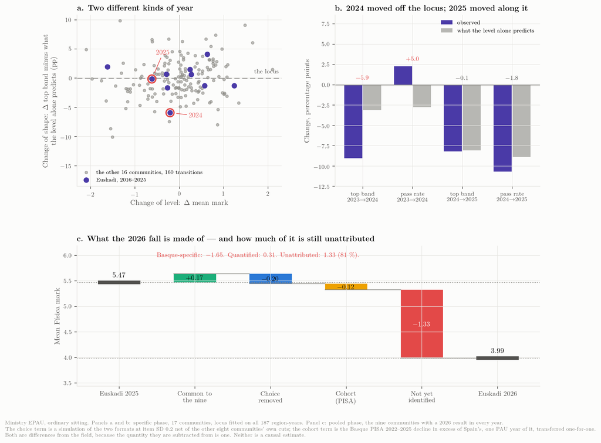

Figure 20: **a** — every year-to-year transition in the panel, placed by how much the mean moved (location) and by how far the top band moved away from what that change of mean alone predicts (shape). Euskadi’s ten transitions are in violet; 2024 and 2025 are ringed and carry a leader to their label. The dashed horizontal is the locus itself — the vertical axis is already the residual from it — so a point on that line is a year whose bands moved exactly as its change of mean predicts. The panel holds 170 transitions: 187 community-years less the first year of each of the seventeen communities, of which 160 belong to the other sixteen. **b** — the same two Basque years, observed against the locus prediction, for both published band quantities. **c** — the 2025 → 2026 fall split into the part common to the nine reporting communities, the two Basque-specific components this study can put a number on, and the part it cannot.

### 6.5.1 Three events, not one

A grade distribution can move in two ways. It can change **location** — everything slides together, and the pass rate and the top-band share move exactly as the common mean-to-band locus of Figure 16 says they must. Or it can change **shape** — the two move differently, because the paper or the marking has changed what separates candidates rather than how hard the paper is overall. The distinction is worth making because the two have different causes and different remedies, and because the published aggregates can tell them apart.

Run over the Basque series, the three recent years are not the same kind of event.

Table 21: Each Basque transition 2016–2025: the change in the mean, the change in each published band quantity, what the level alone predicts for it through the locus fitted on all 187 region-years, and the excess. A year in which both excesses are small moved along the locus; a year in which they are large moved off it. File: `data/analysis/decomposition_steps.csv`.

| Year | Δ mean | Δ top band | locus | excess | Δ pass % | locus | excess | Reads as |
| --- | --- | --- | --- | --- | --- | --- | --- | --- |
| 2016 | +0.63 | +12.47 | +8.38 | +4.09 | +8.73 | +8.90 | -0.17 | shape |
| 2017 | -0.27 | -5.46 | -3.80 | -1.66 | -5.30 | -3.68 | -1.62 | location |
| 2018 | +0.27 | +4.44 | +3.80 | +0.64 | +3.65 | +3.68 | -0.03 | location |
| 2019 | -0.29 | -3.36 | -4.07 | +0.71 | -4.42 | -3.96 | -0.46 | location |
| 2020 | +0.57 | +7.05 | +8.35 | -1.30 | +8.90 | +7.56 | +1.34 | location |
| 2021 | +1.24 | +21.74 | +23.02 | -1.28 | +14.25 | +13.28 | +0.97 | location |
| 2022 | -1.62 | -26.81 | -28.74 | +1.93 | -20.05 | -18.22 | -1.83 | location |
| 2023 | +0.24 | +5.03 | +3.54 | +1.49 | +1.36 | +3.16 | -1.80 | location |
| 2024 | -0.21 | -9.03 | -3.11 | -5.92 | +2.28 | -2.76 | +5.04 | shape |
| 2025 | -0.62 | -8.21 | -8.07 | -0.14 | -10.68 | -8.87 | -1.81 | location |

**2024 was a change of shape with almost no change of level.** The mean fell 0.21 — nothing, in a series whose year-to-year standard deviation is 0.85. But the top band fell 9.0 points when the level predicts 3.1, and the pass rate *rose* 2.3 points when the level predicts a fall of 2.8. The distribution compressed: fewer at the top, more just over the line, on a paper of the old format with the old choice rule and the old theory questions. Measured as a move of the conditional residual, it is the second-most-negative of the 170 transitions in the panel; on the combined size of both excesses it is eleventh.

That 2024 sits first in the sequence matters for how the rest is read. Every mean-based test in this chapter — the reference frames, the drift tests, the subject comparisons — puts Euskadi at or near its own norm through 2024, and they are all correct. They are also all blind to what happened that year, because it barely touched the mean. The first thing that changed in the Basque exam changed the top of the distribution, a year before the first LOMLOE paper.

### 6.5.2 The mark budget

The second question is arithmetical: of the 1.48 points lost between 2025 and 2026, how much is Euskadi’s own?

Table 22: The Basque change each year split into the part shared with the nine communities that have published a 2026 result — the same nine in every year, so the comparison population never changes — and the remainder. Pooled phase. File: `data/analysis/decomposition_budget.csv`.

| Year | Euskadi mean | Δ total | Common to the nine | Basque-specific |
| --- | --- | --- | --- | --- |
| 2016 | 6.14 | +0.70 | -0.24 | +0.94 |
| 2017 | 5.89 | -0.25 | +0.06 | -0.31 |
| 2018 | 6.16 | +0.27 | -0.09 | +0.36 |
| 2019 | 5.87 | -0.29 | -0.07 | -0.22 |
| 2020 | 6.44 | +0.57 | +0.66 | -0.09 |
| 2021 | 7.68 | +1.24 | +0.53 | +0.71 |
| 2022 | 6.06 | -1.62 | -0.43 | -1.19 |
| 2023 | 6.30 | +0.24 | -0.09 | +0.33 |
| 2024 | 6.09 | -0.21 | -0.03 | -0.18 |
| 2025 | 5.47 | -0.62 | -0.65 | +0.03 |
| 2026 | 3.99 | -1.48 | +0.17 | -1.65 |

The answer is sharp. In 2025 the Basque-specific component is **$+0.03$**: Euskadi moved with the field, to within three hundredths of a point, and the entire 0.62 it lost that year is the country’s move, not its own. In 2026 the field moved $+0.17$ and Euskadi moved $-1.48$, so the Basque-specific component is **$-1.65$** — larger than the headline number, and the whole of it in one year.

This is the quantity to explain. Not 1.48, which mixes a national recovery into a Basque fall; not 1.93, which is the same thing measured from a different year; but the 1.65 points by which the Basque exam departed from what nine comparable communities did in the same sitting.

### 6.5.3 Is the 1.65 Física’s, or Euskadi’s?

The budget is computed on Física alone, so it cannot tell apart two situations that call for entirely different responses. The Basque-specific 1.65 could be something that happened to *the Física paper* — its content, its length, its choice rule — or something that happened to *Euskadi*, to its cohort or its tribunals or its marking regime, and landed on Física along with everything else it touched.

The 2026 subject results separate them, and they do it without any modelling. EHU published eight subjects; four comparator communities published three of the same ones — Física, Matemáticas II and Química — which gives a balanced five-by-three panel with no missing cells. On such a panel the Basque Física change decomposes into four additive terms that sum exactly to $-1.48$:

$$\Delta(\text{PV},\text{Fís}) \;=\; \underbrace{\overline{\Delta}_{\text{field}}}_{\text{field core}} \;+\; \underbrace{\left(\overline{\Delta}_{\text{field,Fís}} - \overline{\Delta}_{\text{field}}\right)}_{\text{field Física premium}} \;+\; \underbrace{\left(\overline{\Delta}_{\text{PV}} - \overline{\Delta}_{\text{field}}\right)}_{\text{Euskadi-common}} \;+\; \underbrace{\text{remainder}}_{\text{Física-specific}}$$

Table 23: The balanced five-by-three panel behind the split. File: `data/analysis/subject_decomposition_panel.csv`.

| Community | Física | Matemáticas II | Química | Mean of the three | Física − own mean |
| --- | --- | --- | --- | --- | --- |
| País Vasco | -1.48 | -1.67 | -0.21 | -1.12 | -0.36 |
| Cataluña | +0.80 | -1.94 | -0.34 | -0.49 | +1.29 |
| Madrid | +1.10 | +0.50 | -0.30 | +0.43 | +0.67 |
| Andalucía | +0.17 | -0.59 | -0.22 | -0.21 | +0.38 |
| Asturias | +1.13 | +0.10 | +0.28 | +0.50 | +0.63 |
| **Field (four communities)** | +0.80 | -0.48 | -0.15 | +0.06 | +0.74 |

Change in the subject mean, 2025 to 2026, in marks out of ten. The last two columns are the terms of the additive split: a community’s mean over the three subjects, and how far its Física sits from that mean.

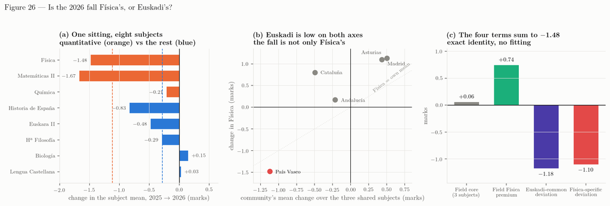

Figure 21: **a** — the eight Basque subjects, with the three to which the marking specification’s numerical deductions can apply in orange and the rest in blue; the dashed lines are the two family means. **b** — each community’s Física change against its own mean over the three shared subjects. A community on the dotted line moved Física exactly as it moved everything else; Euskadi is below the line *and* far to the left of every other point. **c** — the four terms of the identity, which sum to the observed $-1.48$ by construction.

Two of the four terms belong to the field. The three shared subjects rose $+0.06$ on average across the four comparators, and in all four of them Física ran above its own community’s mean — by $+0.74$ on average, and by between $+0.38$ (Andalucía) and $+1.29$ (Cataluña) individually, so 2026 was a good year for Física relative to Matemáticas II in every one of them. The other two terms belong to Euskadi. Its three shared subjects fell $1.18$ below the field’s, and its Física fell a further $1.10$ below what the field’s Física premium would have given it.

Add the two Euskadi terms and Euskadi’s Física sits **$2.28$ marks below what these four comparators’ Física did**. That is the four-community analogue of the $-1.65$ of the mark budget, and it is larger because these four are among the communities that rose most; the two are not interchangeable, and neither is a control. What the split adds to either of them is the proportion: **slightly more than half of that gap — $1.18$ of $2.28$ — is not Física’s.** In the same sitting, at the same university, under the same marking specification, Matemáticas II lost 1.67 marks — more than Física — while Química ($-0.21$), Biología ($+0.15$) and Lengua Castellana ($+0.03$) did not follow.

That changes what the 2027 paper can be expected to fix. Rewriting the Física paper addresses the $-1.10$. It does not touch the $-1.18$, which is by construction invisible to anything decided inside one subject’s *ponencia*, and which the Matemáticas II coordination is presumably looking at from its own side without either group seeing the shared term.

The split is not a causal statement and one caution belongs with it. The comparator set is four communities and three subjects because that is all that was published by mid-September; each of those communities changed its own papers in 2026 too, in the directions Chapter 11 measures, so the “field” terms carry those changes inside them. A symmetric two-way analysis of variance over all five communities, which spreads the subject effect differently, leaves Euskadi’s Física residual at $-0.88$ rather than $-1.10$; both are in `data/analysis/subject_decomposition.json`, and the conclusion — that the Euskadi-wide term is of the same order as the Física-specific one — does not depend on which is used.

### 6.5.4 Marking severity: the timing fits, and one version of it survives the subjects

2026 was the second year in which the linguistic component — 0.2 of a point for grammar, spelling and presentation on any question requiring produced text — and the seven minor-error deductions of the marking specification were in force. Those seven are $-0.10$ each and they are written for numerical work: a missing or wrong unit, a vector arrow missing from a vector, a vector arrow on a scalar, intermediate rounding that moves the result by more than 5 %, a wrong SI prefix, a factor of ten, and a data transcription error. 2026 was also the first year in which correctors had already applied them once.

The coordination’s own hypothesis is that a rule introduced in one year is applied cautiously, and applied in full in the next. That predicts little or nothing in 2025 and a step in 2026. It is exactly the shape of the mark budget above: the Basque-specific component is $+0.03$ in 2025 and $-1.65$ in 2026. The timing fits, this dossier had not previously said so, and it should be on the record that it fits.

The eight-subject table then separates two versions of the hypothesis, because they predict different things.

Table 24: The 2026 Basque subject changes, grouped by which marking rules can reach them. File: `data/analysis/subject_decomposition.json`.

| Basque subject | Change 2025→2026 | Family | Reached by the 0.2 linguistic component | Reached by the seven minor-error rules |
| --- | --- | --- | --- | --- |
| Física | -1.48 | quantitative | yes | yes |
| Matemáticas II | -1.67 | quantitative | yes | yes |
| Química | -0.21 | quantitative | yes | yes |
| Historia de España | -0.83 | verbal / other | yes | no |
| Euskara II | -0.48 | verbal / other | yes | no |
| Hª Filosofía | -0.29 | verbal / other | yes | no |
| Biología | +0.15 | verbal / other | yes | no |
| Lengua Castellana | +0.03 | verbal / other | yes | no |
| **Quantitative mean** | **-1.12** |  |  |  |
| **Verbal mean** | **-0.28** |  |  |  |
| **Gap** | **-0.84** |  |  |  |

Both families are examined in the same sitting at the same university, under the same marking specification and in the same second year of it — but by each subject’s own correctors and on each subject’s own candidates, so this is not a within-person comparison. A marking change written into the shared specification and applied across the board would move both columns together; the gap is what such a change cannot produce.

A **general** severity effect — spelling, presentation, “this year we apply the criteria in full” — reaches every subject that asks a candidate to write. All eight of these do. It should therefore move all eight together, and they did not move together: the spread across them is 1.82 marks, and of the three subjects where written language is most exposed two rose (Lengua Castellana $+0.03$ and Biología $+0.15$, the most text-heavy of the sciences) while the third fell (Euskara II $-0.48$, and it is the subject most candidates write in their second language). Whatever is common to all eight is at most the verbal subjects’ mean of $-0.28$ — *if* the 2026 verbal papers were no easier than their 2025 predecessors, which is not known, since part of that $-0.28$ is the cohort and part each subject’s own paper. On that condition a general severity effect accounts for at most a fifth of Física’s 1.48, and probably a good deal less; without it the figure is an estimate rather than a bound.

A **quantitative-specific** severity effect is a different animal, and the subject pattern is consistent with it. The seven deductions can only be applied where there are units, vectors, prefixes and numerical results — to Física, Química and Matemáticas II and to nothing else in the list. Those three fell 0.84 marks further than the other five.

That consistency is worth having and it is not strong evidence, for a reason worth stating. Química fell only 0.21, so if a numerical-marking effect is at work it is not uniform over the subjects it can reach; the pair that fell is Física and Matemáticas II, and what those two share beyond the deductions — long symbolic derivations in which one early slip propagates through every later sub-task, and a format change in 2026 in both — is confounded with the marking. Eight subjects observed in one year is not a test. It is a pattern with a prediction attached.

**The test is cheap, and the data already exist on the marking sheets.** The linguistic component and the seven deductions are recorded as separate deductions when they are applied. Counting them — how many scripts lost the 0.2, how many $-0.10$ penalties were applied per script and of which of the seven types, in Física and in Lengua Castellana and in Euskara II, in 2025 and in 2026 — turns the whole hypothesis into two tables. It needs no new collection, only a tally of marking the tribunals have already done, and unlike almost everything else on the request list it can be answered from inside EHU. It is item 3 below, ahead of requests that would cost far more.

One design consequence does not wait for that answer. The 2026 Basque paper raised the competency-coded share of its expected marks from 25 % to 62.5 %, the largest such move among the nine communities and in the opposite direction to Cataluña’s (Chapter 11). Competency items ask for a calculation *and* an argument, so they are exposed to the linguistic component and to the numerical deductions at once, where a bare calculation is exposed only to the second. If the deductions bite harder on that compound surface, then the format change and the second year of full application are not two hypotheses but one: the reform enlarged the exposed surface in the same June that the rules began to be applied without reservation. Nothing published separates them, and nothing can, because their correlation is perfect — both happened in Euskadi in 2026 and in no other community.

### 6.5.5 From non-award to deduction: what the change of regime is worth

The section above treats marking severity as one hypothesis among several and bounds it from the subject table. The coordination’s account of what changed is more specific than “the tribunals were harsher”, and it is worth setting out exactly, because it is a different mechanism with a different arithmetic.

Until 2025 a missing unit, a vector arrow on a scalar, an intermediate rounding cost the candidate whatever part of the sub-task depended on it: the marker did not award that part. From 2026 the same omission costs that part **and** a deduction of 0.10, and the Basque 2026 criteria state no cap on those deductions. A second class of defect — clarity, terminology, coherence, the correct use of theorems and constants — carried a rule in 2025 that was, on the coordinator’s account, not applied at all; in 2026 it was. And a grave error, a wrong equation or a conceptual scalar–vector confusion, voids the whole apartado.

The deduction amounts are documented: they are in the 2026 Basque criteria, and the comparison with 2025 is in `data/marking_rules_2025_2026.csv`. **What is testimony, and is labelled as such wherever it appears, is the claim that the rules were applied in full in 2026 and not in 2025**, by a consensus reached with the correctors at the meeting held before the sitting. It is testimony of an unusual kind — the event was collective, scheduled, and attended by every corrector, so any of them could confirm or deny it — but it is not a document, and the dossier does not treat it as one. Its documentary form, the agenda and the criteria circulated, is request 10.

**The question this makes answerable is arithmetical**: how many deductions per script would be needed to move the mean by a given amount, and can the regime produce the 2026 result at all? Two of the three channels are modelled first — the 0.10 deductions and the grave-error voiding. An earlier version of this section left the third out, said the dossier had no basis for a rate, and concluded that everything here therefore **understated** the regime by whatever the linguistic channel was worth. That was wrong in a way the repository could have caught: the Basque criteria deduct 0.10 from the *third* spelling error, allow up to 0.50 for syntax and coherence, and **cap the two together at 1.00** — ten per cent of the paper — and that rule was already in `data/marking_rules_2025_2026.csv`. A capped channel does not understate anything. It is modelled below, where it turns out to be not merely bounded but crowded out by the published figures.

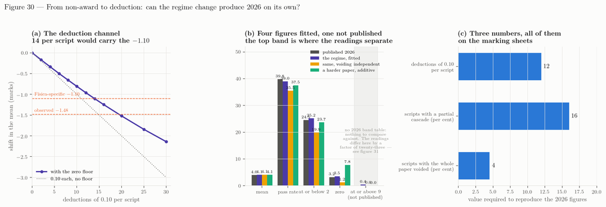

Figure 22: **a** — the deduction channel alone, with and without the floor that stops a sub-task going below zero. **b** — the four published figures the model is fitted to, and a fifth that Euskadi has not published: the share at or above 9, where the readings of the regime separate (figure 31). **c** — the three quantities the fitted regime requires, all of which are on the marking sheets.

The model is the 2026 paper’s marking granularity: twenty-eight marked sub-tasks in twelve apartados, each floored at zero. That structure is **read off problem B1 and assumed for the other three**, which is an extrapolation — the option items are half B1’s length and may be marked more coarsely — so the sensitivity to a twelve-unit structure is reported below. The baseline is built non-parametrically from the **published** 2025 band shares, so it reproduces the 2025 distribution rather than approximating it: mean 5.47, pass 62.4 %, 9.9 % at or below two, 1.2 % at zero, 6.7 % at or above nine, against published values of 5.47, 62.3, 10.0, 1.2 and 6.7.

Table 25: The published 2025 distribution under the deduction channel alone. File: `data/analysis/penalty_regime.json`.

| Deductions per script | Mean | Shift | Pass % | % at or below 2 | % zero |
| --- | --- | --- | --- | --- | --- |
| 0 | 5.46 | +0.00 | 62.1 | 10.0 | 1.2 |
| 2 | 5.30 | -0.17 | 59.1 | 11.1 | 1.2 |
| 4 | 5.13 | -0.34 | 55.5 | 12.2 | 1.2 |
| 6 | 4.98 | -0.50 | 52.4 | 13.2 | 1.2 |
| 8 | 4.81 | -0.65 | 49.0 | 14.5 | 1.2 |
| 10 | 4.66 | -0.81 | 46.1 | 15.6 | 1.2 |
| 12 | 4.52 | -0.96 | 43.3 | 16.6 | 1.2 |
| 14 | 4.37 | -1.10 | 40.5 | 18.0 | 1.2 |
| 16 | 4.22 | -1.25 | 37.7 | 19.1 | 1.2 |
| 20 | 3.94 | -1.52 | 32.8 | 21.7 | 1.2 |
| 25 | 3.63 | -1.84 | 27.1 | 24.7 | 1.2 |
| 30 | 3.33 | -2.14 | 21.5 | 28.1 | 1.2 |

The published 2025 distribution under the deduction channel alone. Each deduction is 0.10 and the Basque 2026 criteria state no cap; a sub-task cannot fall below zero, which is why the mean moves by less than 0.10 per deduction. Row one is the 2025 paper unchanged. The last column barely moves: deductions spread over twenty-eight sub-tasks almost never reach a script’s last mark, so this channel cannot make the 2026 zeros — it is the voiding channel that does. File: `data/analysis/penalty_regime.json`.

**A deduction is worth less than its face value, and the floor is why.** Ten deductions of 0.10 do not cost a mark; on the weakest sub-tasks there is nothing left to take. Inverting: the Física-specific $-1.10$ would need **fourteen** deductions per script, the observed $-1.48$ nineteen, and the Basque-specific $-1.65$ twenty-two. On a paper with twenty-eight marked sub-tasks, fourteen is a deduction on half of them in every script. That is a strong claim — not an absurd one, since the seven minor types can each apply more than once and four problems of symbolic-then-numerical work offer many occasions — and the tally either supports it or does not.

Table 26: The deduction channel carrying each quantity by itself. File: `data/analysis/penalty_regime.json`.

| To account for, on its own | Marks | Deductions per script |
| --- | --- | --- |
| quantitative minus verbal | -0.84 | 10 |
| Física-specific (subject split) | -1.10 | 14 |
| Euskadi-common (subject split) | -1.18 | 15 |
| observed year-on-year | -1.48 | 19 |
| Basque-specific (mark budget) | -1.65 | 22 |

The deduction channel carrying each quantity by itself, voiding switched off. The paper is taken to have twenty-eight marked sub-tasks, so a figure above about fourteen means a deduction on more than half the sub-tasks of every script.

**The deduction channel almost never makes a zero, and the voiding channel has to.** At twelve deductions spread over twenty-eight sub-tasks, a script reaches zero only if every one of them is hit, which effectively never happens; even at thirty deductions the model produces zeros in fewer than two scripts in a hundred thousand. This is a property of the spread, not a theorem — enough deductions on few enough sub-tasks would do it — but at any intensity that also fits the mean, the zeros have to come from somewhere else. They come from voiding, and only if voiding **cascades**: a search over the independent-voiding model, both channels free, gets no closer than a pass rate of 35.5 % against 39.8 and 1.2 % at zero against 3.2. A wrong starting relation does not void one apartado; it voids the derivation, the number that follows and the judgement that follows from that.

**With the cascade, the regime reproduces the four published figures.** Twelve deductions of 0.10 per script; a grave error carrying part of the paper in about **16 %** of scripts; and essentially the whole paper gone in about **3 to 4.5 %** — which is the observed zero rate read back rather than an independent finding, and should be treated as such. That gives a mean of 4.11 against 3.99, a pass rate of 39.0 % against 39.8, 25.2 % at or below two against 24.5, and 3.5 % at zero against 3.2.

Three things have to be said about that fit, and the third is the interesting one.

**It is sufficiency, not identification.** The four figures were *fitted*; they are not out-of-sample confirmation. What the fit establishes is that a marking regime of the kind described, at intensities that are not absurd, can produce the published 2026 result — which is more than the dossier could say before, when severity was “possible, unmeasured”, and less than a demonstration that it happened.

**It is robust in its main number to everything internal to the model, and not robust to one thing that is external.** Across a within-script dispersion of 0.10 and 0.30, a twelve-sub-task structure instead of twenty-eight, and deductions falling on the weak *parts of a script* rather than evenly across its sub-tasks, the fitted deduction count is **twelve in every variant**. The partial-cascade share moves between 16 and 22 %, and the total-cascade share between 3 and 4.5 %. What the count is *not* robust to is the assumption that every candidate collects the same number — which is an assumption about people rather than about marking, and is the subject of the next section. The deduction count is the number to take to the marking sheets; the cascade shares are an order of magnitude, not an estimate.

**And it says something surprising about the fifth figure, the one it was not fitted to.** The fitted regime leaves **0.4 %** of scripts at or above nine, because twelve deductions spread evenly take 1.2 marks off the best script as readily as the worst and cap the paper at about 8.8. An earlier version of this section compared that with “2.1 % of the 2026 scripts” and concluded that the model failed. **That comparison was wrong, and the error is worth naming.** Euskadi has not published a 2026 band table. The 2.09 % is an *output* of the Beta mixture fitted to the same four published figures — a smooth two-parameter curve asked what it implies above nine — so the comparison was model against model, not model against data, and the dossier presented a modelled number as an observation. It is corrected here, recorded in the audit, and it changes the status of the conclusion rather than the conclusion itself: there is no observation that contradicts a flat regime at the top, and there is none that supports one either. What there is instead is a **prediction**, and it is a sharp one. The next section shows that the share at or above nine is the statistic on which flat and distributed readings of the same regime differ by a factor of twenty-three while agreeing on everything that has been published — which makes the 2026 band table the single cheapest measurement that would settle it, and moves it onto the request list as request 11.

One comparison and one cross-check close the section.

The comparison is with a harder paper. A uniform subtraction of 1.48 marks from the 2025 distribution reproduces the mean and the pass rate tolerably but piles **7.8 %** of scripts at zero against the 3.2 % observed, because it pushes the whole bottom of a real distribution through the floor; a proportional paper is worse still. Within this model, on a baseline that reproduces 2025, the marking regime fits the four figures considerably better than either. That is a statement about three specific models and not a verdict: a paper that is harder *unevenly* — hardest in the middle, as a change of genre might well be — was not tested and could fit. The two remain separated by a count on the marking sheets rather than by an argument.

The cross-check cuts against the regime being the whole story. The deduction channel reaches Química as readily as Física — units, prefixes and rounding are not particular to physics. Química fell 0.21. If twelve deductions per script were applied across the quantitative subjects, Química should have fallen with the other two. Either the deduction density is much lower there, which the same tally would show, or the regime is a large part of the Física and Matemáticas II story and a small part of Química’s, which would need explaining.

### 6.5.6 The same penalties, spread differently: a ceiling, and the room it leaves

The model above gives every candidate the same expected twelve deductions. Nobody believes that. A candidate who handles units, vector notation, prefixes and rounding well will collect few; a candidate who is weak in physics and weak in general will collect many, and 2026 was the first year in which any of them had sat a paper marked this way, so even the strongest work should have collected some. The count per script ought to be a *distribution*, heaviest somewhere below the middle and thinning towards the top. The question this section answers is what that costs — and the answer turns out to have a structure worth stating carefully, because it decides how much of the fall the dossier is entitled to attribute to the marking sheet and how much it must leave to everything else.

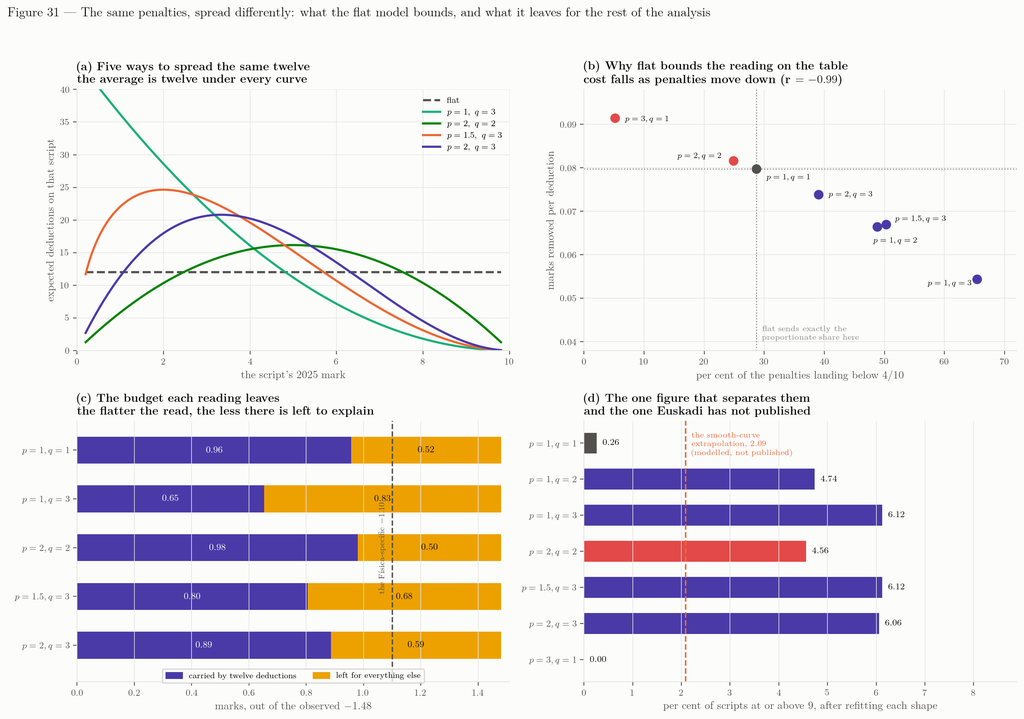

Figure 23: **a** — five ways of spreading the same average of twelve deductions across candidates; the mean under every curve is twelve. **b** — the mechanism: marks removed per deduction against the share of penalties landing on scripts below four out of ten. **c** — the budget each reading leaves against the observed $-1.48$, with the Física-specific $-1.10$ marked. **d** — the share at or above nine after refitting each shape to the four published figures; the one statistic on which the readings disagree, and the one Euskadi has not published.

**A deduction is worth 0.10 only where there is 0.10 left to take.** On a strong script every sub-task is nearly full and every deduction lands in full. On a weak script the sub-tasks are already worth 0.05 or 0.02 and the zero floor absorbs the rest — the mark cannot go below zero, so part of the penalty is spent on nothing. This is the same floor that makes ten deductions cost less than a mark in the section above, seen from the other side: it does not bite evenly across candidates, it bites hardest exactly where the penalties are being aimed.

The consequence is that the quantity governing what a deduction is worth is not the shape’s name but **how much of the penalty mass lands on work that is already worth almost nothing**. Across seven shapes tested at the same average of twelve, the marks removed per deduction fall monotonically in the share of penalties reaching scripts below four out of ten, with a correlation of $-0.99$.

Table 27: Twelve deductions per script in every row; only the spread differs. File: `data/analysis/penalty_shape.json`.

| Shape | Penalties below 4/10 | Shift | Marks per deduction | Relative to flat | Pass % | At or above 9 % |
| --- | --- | --- | --- | --- | --- | --- |
| flat — every script the same expected count | 29 % | -0.96 | 0.080 | 100 % | 43.0 | 0.38 |
| tilted to the weak — count falls linearly with the mark | 49 % | -0.80 | 0.066 | 83 % | 45.1 | 5.34 |
| strongly tilted to the weak — heaviest at the very bottom | 65 % | -0.65 | 0.054 | 68 % | 49.0 | 6.43 |
| hump in the middle — symmetric, light at both ends | 25 % | -0.98 | 0.082 | 102 % | 39.5 | 4.28 |
| middle and left — peak at about 2, thin above 7 | 50 % | -0.80 | 0.067 | 84 % | 45.1 | 6.37 |
| middle, leaning left — peak at about 3.3 | 39 % | -0.89 | 0.074 | 93 % | 42.1 | 6.13 |
| tilted to the STRONG — reported only to bound the claim | 5 % | -1.10 | 0.091 | 115 % | 41.8 | 0.00 |

Twelve deductions of 0.10 per script on average in **every** row, with the voiding channel switched off so that only the deduction channel is in view. The rows differ only in how those twelve are spread across candidates. The second column is the share of the penalties landing on scripts below 4 out of 10; the flat row sits at 29 per cent because that is the share of scripts there. A deduction on a sub-task already worth less than 0.10 is partly absorbed by the zero floor, so the marks removed per deduction fall as that share rises (correlation $-0.99$ across the seven rows). Every shape that sends more than the proportionate share to the weakest work — the reading on the table — costs less than flat. The two rows that cost more are the two that **spare** the weak, and neither is a reading anybody has offered. File: `data/analysis/penalty_shape.json`.

**So the flat model is a ceiling, and it is worth being exact about what it bounds.** The flat shape sends exactly the proportionate share of penalties to the weakest scripts, because every script has the same expected count. Every shape that sends *more* than that — which is precisely the reading the coordination proposed — removes fewer marks per deduction: 93 % of the flat figure for a hump peaking at 3.3, 84 % for one peaking at 2, 68 % for a count that rises all the way to the bottom. Unequal rates at the same average work the same way: giving some scripts many penalties and others almost none, at twelve on average, costs 88 % of the equal-rate figure, because the scripts collecting many run out of marks to lose. **Flat and equal is the most expensive way to spend a fixed number of penalties**, over the whole family of readings anybody has offered.

It is not the most expensive way conceivable, and the section says so rather than letting the word “ceiling” do more work than it can. A shape that *spares* the weakest — a symmetric hump light at both ends, or an outright tilt towards the best scripts — removes *more* per deduction, 102 % and 115 %, because none of its penalties is wasted. Neither is a reading anybody has offered; the claim on the table is that the weak collect more penalties, not fewer. Over that claim, flat is the bound, and the bound is what the argument needs.

**Read as a budget, this is the point of the exercise.** The regime change is a Física change — the deduction schedule is in the Física criteria and the decision to apply it in full was taken at the Física correctors’ meeting — so what it can properly be asked to carry is not the whole observed $-1.48$ but the $-1.10$ the subject split assigns to Física specifically. The $-1.18$ the same split assigns to every Basque subject at once cannot be the Física marking sheet.

Table 28: The same twelve deductions as a budget, against the observed fall and against the Física-specific part of it. File: `data/analysis/penalty_shape.json`.

| Shape | Marks carried at twelve | Share of the $-1.48$ | Left over, against $-1.48$ | Share of the Física-specific $-1.10$ | Left over, against $-1.10$ | Deductions to carry the $-1.48$ alone |
| --- | --- | --- | --- | --- | --- | --- |
| flat — every script the same expected count | 0.96 | 65 % | 0.52 | 87 % | 0.14 | 19 |
| tilted to the weak — count falls linearly with the mark | 0.80 | 54 % | 0.68 | 73 % | 0.30 | 25 |
| strongly tilted to the weak — heaviest at the very bottom | 0.65 | 44 % | 0.83 | 59 % | 0.45 | 35 ⚠ |
| hump in the middle — symmetric, light at both ends | 0.98 | 66 % | 0.50 | 89 % | 0.12 | 19 |
| middle and left — peak at about 2, thin above 7 | 0.80 | 54 % | 0.68 | 73 % | 0.30 | 26 |
| middle, leaning left — peak at about 3.3 | 0.89 | 60 % | 0.59 | 81 % | 0.21 | 22 |
| tilted to the STRONG — reported only to bound the claim | 1.10 | 74 % | 0.38 | 100 % | 0.00 | 17 |

The same twelve deductions read as a budget, against two things. The observed year-on-year fall is $-1.48$, but the marking regime is a **Física** change — the deduction schedule is in the Física criteria and the decision to apply it was taken at the Física correctors’ meeting — so what it can properly be asked to explain is the $-1.10$ the subject split assigns to Física specifically. The $-1.18$ that the same split assigns to every Basque subject at once cannot be the Física marking sheet, and the regime is not asked to carry it here. The flat row is the most the deduction channel can be worth at that count under any reading that does not spare the weakest scripts; every shape of the kind the coordination describes carries less and leaves more for the components the rest of the analysis has isolated — the part of the fall that is not Física’s at all, the reading load, the optionality, the paper itself. The last column inverts the question: how many deductions each shape would need to carry the whole fall alone. A ⚠ marks a figure above the paper’s twenty-eight marked sub-tasks, that is, a shape that cannot carry the fall by itself at any credible intensity.

At twelve deductions per script the flat reading carries 0.96 marks: 87 % of the Física-specific $-1.10$, and 65 % of the whole $-1.48$. The reading the coordination describes carries 0.89 at the mildest tilt and 0.65 at the steepest: 81 % down to 59 % of the Física-specific fall. **Between the ceiling and the realistic reading there is between 0.14 and 0.45 marks of Física-specific fall that the marking regime does not account for**, and about half a mark of the observed fall on top of that which was never the marking sheet’s to explain. That is the room the rest of this dossier needs — the reading load, the optionality, the change of genre, the cohort — and the dossier does not have to claim it. It only has to leave it open, and to say plainly that the flat figure is a maximum rather than an estimate.

Inverting the question gives the same answer from the other end. To carry the whole $-1.48$ alone, the flat reading needs nineteen deductions per script; the mild tilt needs twenty-two, the steeper ones twenty-five and twenty-six, and the steepest needs thirty-five — more than the twenty-eight marked sub-tasks the paper has, which is to say it cannot do it at any intensity. **The more realistically the penalties are distributed, the less the regime can carry, and the sooner it runs out of paper.**

**And the four published figures themselves say something about the shape.** Each shape was refitted on its own three numbers — count, partial cascade, whole-paper cascade — so that the comparison is not rigged by holding the voiding at values fitted under the flat model, which is what an earlier version of this analysis did.

Table 29: Each shape refitted against the four published figures; the top band is neither fitted nor published. File: `data/analysis/penalty_shape.json`.

| Shape | Deductions | Partial cascade % | Whole paper % | Mean | Pass % | At or below 2 % | Zero % | **At or above 9 %** | Loss |
| --- | --- | --- | --- | --- | --- | --- | --- | --- | --- |
| $p=1,q=1$ | 13 | 16 | 4.0 | 4.06 | 37.9 | 25.2 | 3.3 | **0.26** | 1.3 |
| $p=1,q=2$ | 20 | 0 | 2.5 | 4.17 | 37.9 | 27.7 | 2.8 | **4.74** | 5.1 |
| $p=1,q=3$ | 25 | 0 | 0.5 | 4.29 | 41.4 | 29.6 | 3.4 | **6.12** | 11.2 |
| $p=2,q=2$ | 10 | 16 | 4.0 | 4.26 | 38.4 | 24.1 | 3.3 | **4.56** | 3.8 |
| $p=1.5,q=3$ | 16 | 4 | 2.5 | 4.31 | 40.4 | 28.7 | 2.6 | **6.12** | 9.4 |
| $p=2,q=3$ | 16 | 0 | 2.5 | 4.28 | 38.3 | 27.4 | 2.5 | **6.06** | 6.7 |
| $p=3,q=1$ | 8 | 34 | 4.0 | 3.98 | 40.0 | 25.7 | 3.1 | **0.00** | 0.4 |
| *published 2026* | — | — | — | *3.99* | *39.8* | *24.5* | *3.2* | *not published* | — |

Each shape refitted on its own three numbers — count, partial cascade, whole-paper cascade — against the four published figures, so the losses are comparable. They are not equal: the shapes tilted hardest to the weak overshoot the share at or below two, which is itself evidence about the shape. The column in bold was **not** fitted and is **not** published. Across the readings on the table it runs from 0.26 to 6.12 per cent — a factor of 23 — which makes the 2026 band table the single measurement that would separate a flat regime from a distributed one. (The two shapes that *spare* the weakest are shown for contrast and are not readings anybody has offered; including them the range starts at 0.00.) Of the five readings on the table, 3 have their optimum on an edge of the search grid, and in every case it is the *lower* edge of the partial-cascade share: those shapes want no partial cascade at all, because deductions concentrated on weak work already carry the weakest scripts down without help. That is a corner of the model rather than a limit of the grid, and it is reported rather than hidden.

The flat reading fits best, at a loss of 1.3. The tilts fit worse, and they fail in a specific and informative way: to get the mean down to 3.99 they need sixteen to twenty-five deductions, and at those intensities they push 27 to 30 % of scripts to two or below against the 24.5 % observed. **The published figures therefore do not support a heavy concentration of penalties at the bottom.** A mild one is what survives — which is a real constraint on the story, and one that came out of the data rather than out of the model’s assumptions. The honest reading of the regime is thus narrower than either extreme: not flat, because nobody marks that way, and not steeply tilted, because the published low-mark mass forbids it.

**The statistic that would settle it is the one nobody has.** Refitted to the four published figures, the five readings on the table agree on all four and disagree on the fifth by a factor of twenty-three: from 0.3 % at or above nine under the flat reading to 6.1 % under the steep tilts — 0.3 rather than the 0.4 of the previous section because the shape grid refits the voiding too, which is the same number to the model’s resolution. The smooth-curve extrapolation from the Beta mixture puts 2.09 % there, between the two, which is a coincidence of two models and not evidence. Euskadi has not published a 2026 band table. One table — the same table published every year until 2025 — separates a flat regime from a distributed one, and with it separates a marking regime that carries 87 % of the Física-specific fall from one that carries 59 %. It is request 11, and it is the cheapest request on the list.

### 6.5.7 What the paper is made of: exposure, the capped channel, and where the reading load came from

The two sections above model the marking regime as twenty-eight sub-tasks, every one of them able to attract a missing unit or a wrong prefix, and they leave the linguistic channel out. The coordination corrected both, and supplied a third point that turns out to matter more than either.

**Not every quantum can lose a unit, and the corrector’s document says which can.** The paper is marked in quanta of 0.25 — forty of them over the 10.00 — and many of those quanta ask for something with no units and no number: a definition of magnetic flux, whether a headline is physically reasonable, which law applies and why, a qualitative sketch of an exponential decay. A missing unit cannot be committed there. This is measurable rather than assumable, because the corrector’s document for 2026 lists every sub-item with its point value and its content; the coding is in `data/exam_subtask_coding_2026.csv`.

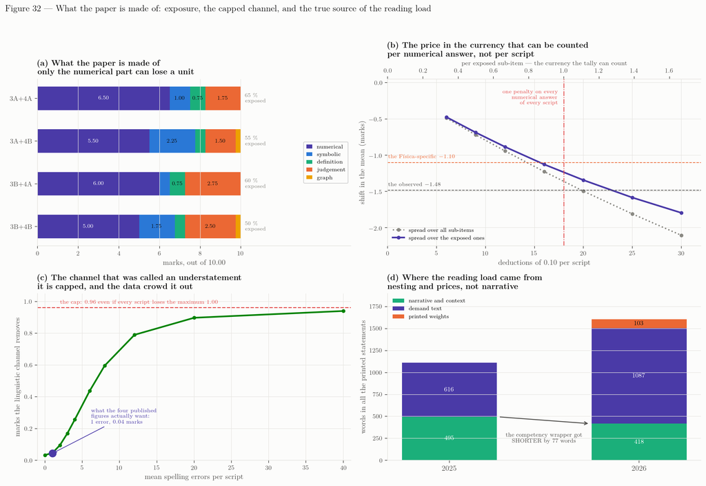

Figure 24: **a** — what each of the four papers a candidate can sit is made of, by the nature of the demand, with the share of marks exposed to a unit error. **b** — the deduction channel with its penalties spread over all sub-items and over the exposed ones only, read in deductions per script and, on the upper axis, per exposed sub-item. **c** — the linguistic channel, capped by the criteria at 1.00, against what the four published figures actually want. **d** — the 2025 and 2026 statements split into narrative, demand text and printed prices.

Table 30: The four papers a candidate can sit, coded from the corrector’s document. File: `data/analysis/marking_exposure.json`.

| The paper a candidate sits | Sub-items | Quanta of 0.25 | Can take a unit error | Marks exposed | Produces text | Marks of text |
| --- | --- | --- | --- | --- | --- | --- |
| 3A+4A | 30 | 40 | 19 (63 %) | 6.50 (65 %) | 8 | 2.75 (28 %) |
| 3A+4B | 32 | 40 | 18 (56 %) | 5.50 (55 %) | 6 | 2.25 (22 %) |
| 3B+4A | 27 | 40 | 15 (56 %) | 6.00 (60 %) | 11 | 3.75 (38 %) |
| 3B+4B | 29 | 40 | 14 (48 %) | 5.00 (50 %) | 9 | 3.25 (32 %) |

Read off the corrector’s document for 2026, which lists every sub-item with its point value and its content, and coded in `data/exam_subtask_coding_2026.csv`. A candidate sits exercises 1 and 2 and one option of each of 3 and 4, so there are four papers. **Between a half and two thirds of the sub-items can attract a missing unit, a wrong prefix or a rounding error**; the rest ask for a definition, a judgement, a comparison with its justification or a sketch, where those errors cannot be made. The earlier model spread the deductions over all of them. The last two columns are the other side of the same coin: between a fifth and a third of the marks come from text, which is where the capped linguistic channel applies. File: `data/analysis/marking_exposure.json`.

Between a half and two thirds of the sub-items are exposed, carrying 50 to 65 per cent of the marks. Restricting the deductions to them changes the arithmetic modestly and the **interpretation** sharply, because it changes the currency. Twelve deductions per script is a number nobody can check. Twelve deductions over the eighteen exposed sub-items of the modal paper is **0.67 penalties on every numerical answer of every script**, and that is a claim a corrector can recognise or reject on sight.

Table 31: What restricting the deductions to the sub-items that can receive one costs. File: `data/analysis/marking_exposure.json`.

| Deductions per script | Per exposed sub-item | Spread over all sub-items | Spread over the exposed ones | Ratio |
| --- | --- | --- | --- | --- |
| 6 | 0.33 | -0.49 | -0.47 | 97 % |
| 9 | 0.50 | -0.72 | -0.69 | 95 % |
| 12 | 0.67 | -0.94 | -0.89 | 94 % |
| 16 | 0.89 | -1.23 | -1.13 | 92 % |
| 20 | 1.11 | -1.50 | -1.34 | 90 % |
| 25 | 1.39 | -1.81 | -1.58 | 88 % |
| 30 | 1.67 | -2.10 | -1.80 | 85 % |

Restricting the deductions to the sub-items that can actually receive one concentrates them, and concentration wastes them: two penalties on the same 0.25 sub-item cannot take 0.20 from it. The effect is small at the fitted intensity and grows with it. The second column is the one to read in a meeting: at the fitted twelve deductions it is 0.67 — **a penalty on two out of every three numerical answers, in every script**. To carry the whole observed fall alone it would be 1.26, which is more than one penalty on every numerical answer there is.

Concentration also wastes penalties, for the same reason the zero floor does: two deductions on the same 0.25 sub-item cannot take 0.20 from it. Spread over the exposed items only, twelve deductions move the mean 0.89 instead of 0.94, and thirty move it 1.80 instead of 2.11 — 85 per cent of the unrestricted figure. **So exposure lowers the ceiling of the previous section rather than raising it**, and it does so for a reason independent of how the penalties are distributed across candidates.

**The third channel is capped, and the cap was in the repository all along.** The Basque criteria deduct 0.10 from the *third* spelling error, allow up to 0.50 for syntax and coherence, and cap the two together at 1.00 — ten per cent of the paper. The rule is the same in 2025 and 2026; what the coordination reports changing is whether it was applied. Modelling it required one correction of its own: the first version simply raised the error rate as the mark fell, and produced 8.2 per cent of scripts at exactly zero against a published 3.2, because a candidate who writes almost nothing cannot misspell it. Errors need text and text needs an attempt, so the rate has to vanish at both ends.

Table 32: The linguistic channel, with its cap. File: `data/analysis/marking_exposure.json`.

| Mean spelling errors per script | What the channel costs | Pass % | At or below 2 % | Zero % |
| --- | --- | --- | --- | --- |
| 0 | 0.033 | 61.7 | 10.3 | 1.19 |
| 1 | 0.046 | 61.2 | 10.4 | 1.17 |
| 2 | 0.095 | 59.7 | 10.7 | 1.19 |
| 3 | 0.170 | 57.9 | 11.3 | 1.20 |
| 4 | 0.257 | 55.6 | 12.0 | 1.20 |
| 6 | 0.438 | 51.2 | 14.0 | 1.24 |
| 8 | 0.596 | 47.8 | 15.9 | 1.24 |
| 12 | 0.790 | 44.8 | 18.4 | 1.28 |
| 20 | 0.897 | 44.3 | 19.3 | 2.01 |
| 40 | 0.940 | 44.3 | 19.2 | 4.40 |
| *every script at the cap* | *0.963* | — | — | — |

The third channel, which the regime sections said was unmodelled and which they said made the dossier **understate** the regime. It does not: the Basque criteria deduct 0.10 from the *third* spelling error, allow up to 0.50 for syntax and coherence, and **cap the two together at 1.00**, ten per cent of the paper — a rule that was already in `data/marking_rules_2025_2026.csv` when that sentence was written, and that is the same in 2025 and in 2026. A capped channel is bounded, and the last row is the bound: 0.96 marks even if every script in Euskadi lost the maximum. The column that matters is not that one, though. Fitted jointly with the other two channels, the four published figures want **1 error per script**, worth 0.044 marks — the channel is not merely bounded, it is crowded out. Push it harder and the fit degrades, because the mean and the pass rate move together in a way the published pair does not allow.

The result is the opposite of an understatement. The absolute bound — every script in Euskadi losing the full ten per cent — is **0.96 marks**. And fitted jointly with the other two channels, the four published figures want **one error per script, worth 0.04 marks**: push it to four and the mean lands on 3.99 but the pass rate falls to 35.7 against the published 39.8, because the mean and the pass rate cannot both be matched by a channel that takes the same amount from everyone who writes. The channel is not merely bounded; it is crowded out.

**And the regime, fitted to the four published figures, is over-attributed by construction.** Those four figures are 2026’s own, so a model that reproduces them carries the whole observed $-1.48$. But the subject split says at most $-1.10$ of that fall can be Física’s, because $-1.18$ of it moved every Basque subject at once and cannot be the Física marking sheet. Fitted to the published figures the regime needs **15.5 deductions per script**, 0.86 on every exposed sub-item; asked only for the $-1.10$ that can be its, it needs **8.8**, or 0.49 — one penalty on every second numerical answer rather than nearly every one. The difference, **0.38 marks**, is over-attribution, and it is the arithmetic reason the fitted regime has to be read as a ceiling. That reason is independent of the shape argument in the previous section, and the two compound.

#### 6.5.7.1 Where the reading load actually came from

The granularity has a consequence the dossier had not connected to anything, and it overturns a reading this chapter has carried since the reading-load section was written. A paper marked in itemised quanta has to **print** each quantum: its demand and its price. The 2025 paper stated twenty plain numbered demands. The 2026 paper states seventeen apartado lead-ins with thirty-six numbered sub-demands nested inside them and fifty-one printed weights. That is text nobody wrote for its own sake.

Table 33: The printed statements of both papers, split by what the words do. File: `data/analysis/marking_exposure.json`.

|  | Narrative and context | Demand text | Printed prices | Statement total |
| --- | --- | --- | --- | --- |
| 2025, all 7 printed statements | 495 | 616 | 0 | 1111 |
| 2026, all 6 printed statements | 418 | 1087 | 103 | 1608 |
| **2025, per printed statement** | **71** | **88** | **0** | **159** |
| **2026, per printed statement** | **70** | **181** | **17** | **268** |
| *2026 against 2025, per statement* | *99 %* | *206 %* | *—* | *169 %* |

The words of all the printed statements of each paper, split by what they do. **Narrative and context** is the competency wrapper: the scenario, the data, the framing. **Demand text** is everything that says what to do — the apartado lead-ins and the numbered sub-demands nested inside them. **Printed weights** are the `(0.25 puntos)` annotations, which exist only because the marking is itemised on the paper. The result is not the one the dossier expected. The 2025 paper printed seven statements and the 2026 paper six, so the row to read is the per-statement one: **the competency wrapper is the same size it was** — 71 words a statement against 70, 98 per cent — while the **demand text more than doubled**, 88 words a statement against 181, and the printed prices went from nothing to 17. A paper marked in itemised quanta has to print each quantum’s demand and each quantum’s price; that is where the reading load came from. The 2025 paper had 20 numbered demands and no nesting; the 2026 paper has 17 apartado lead-ins with 36 numbered demands inside them and 51 printed weights. One 2026 item states its demands in the lead-in without numbering them, so the lead-in and sub-demand columns are combined here; their sum is the measurement the finding rests on.

**The competency wrapper did not grow at all.** The 2025 paper printed seven statements and the 2026 paper six, so the comparison has to be made per statement, and made that way it is unambiguous: the narrative and context — the scenario, the data, the framing, everything the contextualisation requirement adds — runs to 71 words a statement in 2025 and **70 in 2026**, 99 per cent of what it was. The demand text went from 88 words a statement to **181**, and the printed prices from nothing to 17. In totals, across all the printed statements of each paper, narrative fell from 495 to 418 and demand text rose from 616 to 1 087. Whichever way it is normalised, the whole of the growth is the itemisation, and the competency narrative is not implicated at all.

The coordination’s own reconstruction of the electromagnetic problem says the same thing from the other direction, and it is worth noticing that it does, because the two measurements are independent. The forward ladder in its presentation runs 90 words in the habitual style, 178 once the item is made competencial, **244 once it is *desglosado*** — itemised — and 408 as issued. The itemisation step costs 66 words there, on one problem, in a count made by the people who wrote it.

This does not withdraw the reading-load finding — the paper really is 39 per cent longer to read, and length really does track the fall across the nine communities — but it relocates its cause, and relocating it changes what can be done about it. The dossier has been treating the reading load as the price of the competency reform, which is imposed from outside and cannot be declined. On this measurement it is the price of a decision taken locally, for a reason of its own, and which the coordination can revisit without touching the reform at all. The design chapter sets that trade-off out, because the protection the itemisation buys is real and the dossier is not in a position to say it is not worth 470 words.